# Conspiracy Mentality and Political Orientation across 23 countries

06.06.2021

# Centered Political Orientation

(instead of Within Country-standardized, CPO)

## CM and PO

Mixed Model

```r
model.cmpo =lmer(CM4x~CPO+I(CPO^2)+(CPO+I(CPO^2)|Country), data=data, REML=FALSE, control = lmerControl(optimizer="optimx", optCtrl=list(method="bobyqa")) )
```

```
## Lade nötigen Namensraum: optimx
```

```r
summary(model.cmpo)
```

```
## Linear mixed model fit by maximum likelihood . t-tests use Satterthwaite's
##   method [lmerModLmerTest]
## Formula: CM4x ~ CPO + I(CPO^2) + (CPO + I(CPO^2) | Country)
##    Data: data
## Control: lmerControl(optimizer = "optimx", optCtrl = list(method = "bobyqa"))
##
##      AIC      BIC   logLik deviance df.resid
## 141308.3 141392.2 -70644.1 141288.3    32626
##
## Scaled residuals:
##     Min      1Q  Median      3Q     Max
## -3.3552 -0.6990  0.0025  0.7183  2.8088
##
## Random effects:
##  Groups   Name        Variance Std.Dev. Corr
##  Country  (Intercept) 0.545259 0.73842
##           CPO         0.008018 0.08954  -0.38
##           I(CPO^2)    0.000356 0.01887  -0.56  0.04
##  Residual             4.421226 2.10267
## Number of obs: 32636, groups:  Country, 24
##
## Fixed effects:
##              Estimate Std. Error        df t value Pr(>|t|)
## (Intercept)  6.858979   0.152219 24.273289  45.060  < 2e-16 ***
## CPO          0.064641   0.020601 22.090176   3.138  0.00477 **
## I(CPO^2)     0.019750   0.005343 25.959429   3.696  0.00103 **
## ---
## Signif. codes:  0 '***' 0.001 '**' 0.01 '*' 0.05 '.' 0.1 ' ' 1
##
## Correlation of Fixed Effects:
##          (Intr) CPO
## CPO      -0.332
## I(CPO^2) -0.453 -0.001
```

Twolines Plot - is not scaled by country

```r
# data$Pol_Ori_centered = scale(data$Pol_Ori,scale=F)
# a=twolines(CM4x~Pol_Ori_centered,data=data, x.label="Political Orientation",y.label="Conspiracy Mentality (CMQ)",label.extremes=T,lab.extreme.low="extreme left wing",lab.extreme.high="extreme right wing")
```

by country effects in the mixed model

```r
coef(model.cmpo)
```

```
## $Country
##                 (Intercept)          CPO     I(CPO^2)
## Belgium, FR        7.411530 -0.018733446  0.030886277
## Bosnia             7.091863 -0.016369334  0.023051192
## Brazil             6.804237 -0.021100001  0.037793110
## Croatia            6.898498  0.156974702  0.022033397
## Czech Republic     5.921111  0.067995080  0.029488477
## France             5.633466  0.163714896  0.031696693
## Germany            6.923171  0.068860427  0.020835416
## Greece             6.402036  0.102721673  0.024047835
## Hungary            7.501582  0.081363362  0.016395395
## Iceland            6.593646 -0.066772590  0.019558862
## Israel             7.455686  0.003683257  0.006717091
## Italy              6.359608  0.190113343  0.017391526
## Macedonia          6.956809  0.060496376  0.025899111
## Netherlands        5.116534  0.080632466  0.056461280
## Norway             5.825803  0.098093584  0.041919763
## Poland             6.118743  0.126091145  0.009842864
## Portugal           7.976579  0.058307531  0.011781046
## Romania            7.378848  0.168051572  0.001940194
## Serbia             7.666121 -0.022869484  0.003041702
## Spain              7.669358 -0.078087123 -0.014333403
## Switzerland, FR    6.814212  0.157742854  0.015756980
## Switzerland, GE    7.237569  0.139214798  0.002487920
## Turkey             7.946487 -0.058368756  0.019044809
## UK                 6.911999  0.109636534  0.020261192
##
## attr(,"class")
## [1] "coef.mer"
```

Linear Model for each country

```r
by.country = matrix(NA,0,7)
for (i in unique(data$Country)) {
test = lm(CM4x~CPO+I(CPO^2),data[data$Country == i,])
a = coef(test)
b = summary(test)$coefficients[,4] #p-values
b2 = summary(test)$coefficients[,2] #SE
d = c(as.numeric(a)[-1],as.numeric(b2)[-1],as.numeric(b)[-1])
d = c(i,d)
by.country = rbind(by.country,d)
}
by.country = as.data.frame(by.country)
names(by.country) = c("Country","CPO","CPO2","SE_CPO","SE_CPO2","p_CPO","p_CPO2")
by.country[,2:7] = apply(by.country[,2:7],2,as.numeric)

by.country$CI95_low_CPO = by.country$CPO-qnorm(.975)*by.country$SE_CPO
by.country$CI95_high_CPO = by.country$CPO+qnorm(.975)*by.country$SE_CPO
by.country$sig_CPO = by.country$p_CPO<.05
by.country$sigbonf_CPO = by.country$p_CPO<.05/nrow(by.country)

by.country$CI95_low_CPO2 = by.country$CPO2-qnorm(.975)*by.country$SE_CPO2
by.country$CI95_high_CPO2 = by.country$CPO2+qnorm(.975)*by.country$SE_CPO2
by.country$sig_CPO2 = by.country$p_CPO2 <.05
by.country$sigbonf_CPO2 = by.country$p_CPO2 <.05/nrow(by.country)

export = by.country[,c(1,2,8,9,10,11,3,12,13,14,15)]
export
```

|  | Country | CPO | CI95_low_CPO | CI95_high_CPO | sig_CPO | sigbonf_CPO | CPO2 | CI95_low_CPO2 | CI95_high_CPO2 | sig_CPO2 | sigbonf_CPO2 |
| --- | --- | --- | --- | --- | --- | --- | --- | --- | --- | --- | --- |
| d | Iceland | -0.12365865 | -0.215929779 | -0.03138751 | TRUE | FALSE | 0.001075951 | -0.041263049 | 0.04341495 | FALSE | FALSE |
| d.1 | Belgium, FR | -0.04383062 | -0.135488371 | 0.04782713 | FALSE | FALSE | 0.058556697 | 0.023172089 | 0.09394131 | TRUE | TRUE |
| d.2 | Bosnia | -0.05865943 | -0.181713386 | 0.06439452 | FALSE | FALSE | 0.031352200 | -0.011570753 | 0.07427515 | FALSE | FALSE |
| d.3 | Brazil | -0.03280983 | -0.090877327 | 0.02525766 | FALSE | FALSE | 0.046415437 | 0.023803218 | 0.06902766 | TRUE | TRUE |
| d.4 | Switzerland, FR | 0.21459679 | 0.082878235 | 0.34631535 | TRUE | TRUE | 0.011442412 | -0.054323709 | 0.07720853 | FALSE | FALSE |
| d.5 | Switzerland, GE | 0.19714307 | 0.088598067 | 0.30568807 | TRUE | TRUE | -0.025211320 | -0.069285536 | 0.01886290 | FALSE | FALSE |
| d.6 | Croatia | 0.18275353 | 0.086073834 | 0.27943322 | TRUE | TRUE | 0.026079365 | -0.012044643 | 0.06420337 | FALSE | FALSE |
| d.7 | Czech Republic | 0.03335709 | -0.072353848 | 0.13906803 | FALSE | FALSE | 0.013506465 | -0.033187757 | 0.06020069 | FALSE | FALSE |
| d.8 | France | 0.18396867 | 0.068294528 | 0.29964280 | TRUE | TRUE | 0.024211268 | -0.024206628 | 0.07262916 | FALSE | FALSE |
| d.9 | Greece | 0.10834810 | 0.001650463 | 0.21504574 | TRUE | FALSE | 0.022762404 | -0.018867638 | 0.06439245 | FALSE | FALSE |

[output cut: 14 more lines]

```r
#print(xtable(export,digits=4),type="html",file="./table.html")
```

Exploratory: Interaction of CPO and Countryvars in predicting CM

```r
countrylevelvars = c("lrgengov", "lrecongov","galtangov")

for (i in 1:length(countrylevelvars)) {
fmla <- as.formula(paste("CM4x~CPO+I(CPO^2)+(CPO+I(CPO^2)|Country) +",countrylevelvars[i],"+ CPO *",countrylevelvars[i],"+ I(CPO^2) *",countrylevelvars[i]))
model.1 =lmer(fmla, data=data, REML=FALSE, control = lmerControl(optimizer="optimx", optCtrl=list(method="bobyqa")))
summary(model.1) %>% print()
}
```

```
## Linear mixed model fit by maximum likelihood . t-tests use Satterthwaite's
##   method [lmerModLmerTest]
## Formula: fmla
##    Data: data
## Control: lmerControl(optimizer = "optimx", optCtrl = list(method = "bobyqa"))
##
##      AIC      BIC   logLik deviance df.resid
## 129876.3 129984.3 -64925.1 129850.3    29904
##
## Scaled residuals:
##     Min      1Q  Median      3Q     Max
## -3.3345 -0.7052 -0.0009  0.7170  2.7922
##
## Random effects:
##  Groups   Name        Variance  Std.Dev. Corr
##  Country  (Intercept) 0.6092635 0.78055
##           CPO         0.0057294 0.07569  -0.52
##           I(CPO^2)    0.0003368 0.01835  -0.59  0.22
##  Residual             4.4732918 2.11502
## Number of obs: 29917, groups:  Country, 20
##
## Fixed effects:
##                    Estimate Std. Error        df t value Pr(>|t|)
## (Intercept)        6.483106   0.702814 20.319719   9.224 1.05e-08 ***
## CPO                0.177256   0.080835 21.494540   2.193   0.0395 *
## I(CPO^2)           0.011977   0.024718 32.938143   0.485   0.6312
## lrgengov           0.054039   0.109896 20.269287   0.492   0.6282
## CPO:lrgengov      -0.016469   0.012441 20.187180  -1.324   0.2004
## I(CPO^2):lrgengov  0.001410   0.003728 29.778726   0.378   0.7079
## ---
## Signif. codes:  0 '***' 0.001 '**' 0.01 '*' 0.05 '.' 0.1 ' ' 1
##
## Correlation of Fixed Effects:
##             (Intr) CPO    I(CPO^2) lrgngv CPO:lr
## CPO         -0.427
## I(CPO^2)    -0.446  0.089
## lrgengov    -0.968  0.413  0.430
## CPO:lrgengv  0.420 -0.970 -0.087   -0.434
## I(CPO^2):lr  0.445 -0.088 -0.973   -0.457  0.092
## Linear mixed model fit by maximum likelihood . t-tests use Satterthwaite's
```

[output cut: 62 more lines]

```
## CPO                 0.153389   0.049633 20.410008   3.090  0.00567 **
## I(CPO^2)            0.037494   0.014924 23.789401   2.512  0.01919 *
## galtangov           0.113681   0.064946 20.192540   1.750  0.09523 .
## CPO:galtangov      -0.013193   0.007580 19.438457  -1.741  0.09756 .
## I(CPO^2):galtangov -0.002637   0.002221 22.710923  -1.187  0.24749
## ---
## Signif. codes:  0 '***' 0.001 '**' 0.01 '*' 0.05 '.' 0.1 ' ' 1
##
## Correlation of Fixed Effects:
##             (Intr) CPO    I(CPO^2) gltngv CPO:gl
## CPO         -0.348
## I(CPO^2)    -0.367 -0.034
## galtangov   -0.919  0.319  0.337
## CPO:galtngv  0.324 -0.923  0.036   -0.352
## I(CPO^2):gl  0.351  0.036 -0.928   -0.379 -0.039
```

Correlations of CountryVars and Slopes

```r
sl = coef(model.cmpo)$Country
cl = aggregate(data[countrylevelvars],by=list(data$Country),mean)
df = cbind(sl,cl[,-1])
df = df[,-1]
res<-rcorr(as.matrix(df[,])) # using Hmisc
res = lapply(res,function(x) x[3:length(df),1:2])
res = cbind(res$r,res$P)
res =as.data.frame(res)
names(res) = c("CPO","CPO2","pCPO","pCPO2")
res$sigCPO = res$pCPO<.05
res$sigCPO2 = res$pCPO2<.05
res
```

|  | CPO | CPO2 | pCPO | pCPO2 | sigCPO | sigCPO2 |
| --- | --- | --- | --- | --- | --- | --- |
| lrgengov | -0.2886084 | 0.04809492 | 0.21718147 | 0.8404221 | FALSE | FALSE |
| lrecongov | -0.2674148 | 0.21907263 | 0.25436038 | 0.3534175 | FALSE | FALSE |
| galtangov | -0.3921313 | -0.30384938 | 0.08726271 | 0.1927757 | FALSE | FALSE |

Between countries

```r
 model.1=lmer(CM4x~CPO+I(CPO^2)+ZmeanPO+I(ZmeanPO^2)+(CPO+I(CPO^2)|Country), data=data, REML=FALSE, control = lmerControl(optimizer="optimx", optCtrl=list(method="bobyqa")) )
 summary(model.1)
```

```
## Linear mixed model fit by maximum likelihood . t-tests use Satterthwaite's
##   method [lmerModLmerTest]
## Formula: CM4x ~ CPO + I(CPO^2) + ZmeanPO + I(ZmeanPO^2) + (CPO + I(CPO^2) |
##     Country)
##    Data: data
## Control: lmerControl(optimizer = "optimx", optCtrl = list(method = "bobyqa"))
##
##      AIC      BIC   logLik deviance df.resid
## 141311.5 141412.2 -70643.7 141287.5    32624
##
## Scaled residuals:
##     Min      1Q  Median      3Q     Max
## -3.3518 -0.6980  0.0020  0.7171  2.8091
##
## Random effects:
##  Groups   Name        Variance  Std.Dev. Corr
##  Country  (Intercept) 0.5749007 0.75822
##           CPO         0.0079530 0.08918  -0.39
##           I(CPO^2)    0.0003486 0.01867  -0.64  0.04
##  Residual             4.4212890 2.10269
## Number of obs: 32636, groups:  Country, 24
##
## Fixed effects:
##               Estimate Std. Error        df t value Pr(>|t|)
## (Intercept)   6.895245   0.181195 25.591448  38.054  < 2e-16 ***
## CPO           0.064234   0.020540 22.099169   3.127  0.00488 **
## I(CPO^2)      0.019517   0.005295 25.146164   3.686  0.00110 **
## ZmeanPO      -0.081928   0.109521 23.799375  -0.748  0.46175
## I(ZmeanPO^2) -0.002734   0.047811 26.484590  -0.057  0.95483
## ---
## Signif. codes:  0 '***' 0.001 '**' 0.01 '*' 0.05 '.' 0.1 ' ' 1
##
## Correlation of Fixed Effects:
##             (Intr) CPO    I(CPO^ ZmenPO
## CPO         -0.298
## I(CPO^2)    -0.466  0.001
## ZmeanPO      0.160  0.021  0.017
## I(ZmenPO^2) -0.476  0.007  0.034 -0.621
```

+interactions

```r
model.2=lmer(CM4x~CPO+I(CPO^2)+ZmeanPO+I(ZmeanPO^2)+CPO:ZmeanPO+I(CPO^2):ZmeanPO+(CPO+I(CPO^2)|Country), data=data, REML=FALSE, control = lmerControl(optimizer="optimx", optCtrl=list(method="bobyqa")) )
summary(model.2)
```

```
## Linear mixed model fit by maximum likelihood . t-tests use Satterthwaite's
##   method [lmerModLmerTest]
## Formula: CM4x ~ CPO + I(CPO^2) + ZmeanPO + I(ZmeanPO^2) + CPO:ZmeanPO +
##     I(CPO^2):ZmeanPO + (CPO + I(CPO^2) | Country)
##    Data: data
## Control: lmerControl(optimizer = "optimx", optCtrl = list(method = "bobyqa"))
##
##      AIC      BIC   logLik deviance df.resid
## 141309.8 141427.3 -70640.9 141281.8    32622
##
## Scaled residuals:
##     Min      1Q  Median      3Q     Max
## -3.3671 -0.7044  0.0020  0.7171  2.8091
##
## Random effects:
##  Groups   Name        Variance Std.Dev. Corr
##  Country  (Intercept) 0.542465 0.73652
##           CPO         0.007674 0.08760  -0.37
##           I(CPO^2)    0.000235 0.01533  -0.69  0.06
##  Residual             4.421305 2.10269
## Number of obs: 32636, groups:  Country, 24
##
## Fixed effects:
##                   Estimate Std. Error        df t value Pr(>|t|)
## (Intercept)       6.870783   0.177238 27.061482  38.766  < 2e-16 ***
## CPO               0.063645   0.020809 21.944947   3.059 0.005767 **
## I(CPO^2)          0.022275   0.004830 21.461497   4.612 0.000143 ***
## ZmeanPO           0.065681   0.126280 28.309772   0.520 0.607021
## I(ZmeanPO^2)     -0.014082   0.047425 26.930409  -0.297 0.768798
## CPO:ZmeanPO      -0.006341   0.014046 24.495921  -0.451 0.655650
## I(CPO^2):ZmeanPO -0.008780   0.003535 36.936979  -2.484 0.017665 *
## ---
## Signif. codes:  0 '***' 0.001 '**' 0.01 '*' 0.05 '.' 0.1 ' ' 1
##
## Correlation of Fixed Effects:
##             (Intr) CPO    I(CPO^2) ZmenPO I(ZPO^ CPO:ZP
## CPO         -0.282
## I(CPO^2)    -0.463 -0.017
## ZmeanPO      0.105  0.058  0.075
## I(ZmenPO^2) -0.473 -0.002  0.031   -0.577
## CPO:ZmeanPO  0.037 -0.223  0.051   -0.287  0.050
## I(CPO^2):ZP  0.053  0.053 -0.172   -0.439  0.079  0.029
```

```r
anova(model.1,model.2)
```

|  | npar | AIC | BIC | logLik | deviance | Chisq | Df | Pr(>Chisq) |
| --- | --- | --- | --- | --- | --- | --- | --- | --- |
| model.1 | 12 | 141311.5 | 141412.2 | -70643.73 | 141287.5 | NA | NA | NA |
| model.2 | 14 | 141309.8 | 141427.3 | -70640.90 | 141281.8 | 5.669698 | 2 | 0.0587274 |

# Correlation of general with social left-right stance as country-level moderator

```r
# Calculate the new variable (country-wise correlation of lrgen and galtan) and add to the dataset
a = as.character(unique(data$Country))
lr_galtan_cor = c()
data$lr_galtan_cor = NA
for (i in a) {
  dat = data[data$Country==i,]
  re = tryCatch(cor(dat$lrgen,dat$galtan,use="complete.obs"),error=function(x) NA)
  lr_galtan_cor = c(lr_galtan_cor,re)
  # add the correlation to the dataset
  data[data$Country==i,"lr_galtan_cor"] = re
}
names(lr_galtan_cor) = a
lr_galtan_cor
```

```
##         Iceland     Belgium, FR          Bosnia          Brazil Switzerland, FR
##              NA       0.4801423       0.9743061              NA       0.9096404
## Switzerland, GE         Croatia  Czech Republic          France          Greece
##       0.9316268       0.9803303       0.4041511       0.7971924       0.7247172
##         Hungary           Italy       Macedonia     Netherlands          Poland
##       0.9776681       0.9774088       0.9997750       0.6476927       0.9597646
##          Serbia           Spain          Turkey          Norway         Germany
##       0.7235466       0.9820060       0.9928220       0.6929077       0.7635425
##          Israel        Portugal         Romania              UK
##              NA       0.8161361      -0.9841620       0.9164655
```

```r
#Transform Correlations to FIsher Z:
data[,"lr_galtan_cor"] = psych::fisherz(data[,"lr_galtan_cor"])
```

ZPO. Mixed Model

```r
model.cmpo =lmer(CM4x~ZPO+I(ZPO^2)+(ZPO+I(ZPO^2)|Country) + ZPO*lr_galtan_cor, data=data, REML=FALSE, control = lmerControl(optimizer="optimx", optCtrl=list(method="bobyqa")) )
summary(model.cmpo)
```

```
## Linear mixed model fit by maximum likelihood . t-tests use Satterthwaite's
##   method [lmerModLmerTest]
## Formula:
## CM4x ~ ZPO + I(ZPO^2) + (ZPO + I(ZPO^2) | Country) + ZPO * lr_galtan_cor
##    Data: data
## Control: lmerControl(optimizer = "optimx", optCtrl = list(method = "bobyqa"))
##
##      AIC      BIC   logLik deviance df.resid
## 131351.5 131451.3 -65663.8 131327.5    30250
##
## Scaled residuals:
##     Min      1Q  Median      3Q     Max
## -3.3168 -0.7060 -0.0014  0.7231  2.7935
##
## Random effects:
##  Groups   Name        Variance Std.Dev. Corr
##  Country  (Intercept) 0.594427 0.77099
##           ZPO         0.020420 0.14290  -0.41
##           I(ZPO^2)    0.003417 0.05845  -0.57  0.05
##  Residual             4.469316 2.11408
## Number of obs: 30262, groups:  Country, 21
##
## Fixed effects:
##                   Estimate Std. Error       df t value Pr(>|t|)
## (Intercept)        6.70204    0.24497 23.45086  27.359   <2e-16 ***
## ZPO                0.18742    0.05671 21.43286   3.305   0.0033 **
## I(ZPO^2)           0.06139    0.01788 22.59587   3.434   0.0023 **
## lr_galtan_cor      0.09919    0.12106 21.71507   0.819   0.4215
## ZPO:lr_galtan_cor -0.03003    0.02984 23.43405  -1.006   0.3246
## ---
## Signif. codes:  0 '***' 0.001 '**' 0.01 '*' 0.05 '.' 0.1 ' ' 1
##
## Correlation of Fixed Effects:
##             (Intr) ZPO    I(ZPO^ lr_gl_
## ZPO         -0.355
## I(ZPO^2)    -0.316  0.033
## lr_galtn_cr -0.721  0.276  0.002
## ZPO:lr_glt_  0.273 -0.772 -0.046 -0.374
```

Left-Right (General), mixed model

```r
model.1=lmer(CM4x ~ lrgen + I(lrgen^2)+ (lrgen+I(lrgen^2)|Country) + lrgen*lr_galtan_cor, data=data, REML=FALSE, control = lmerControl(optimizer="optimx", optCtrl=list(method="bobyqa")) )
summary(model.1)
```

```
## Linear mixed model fit by maximum likelihood . t-tests use Satterthwaite's
##   method [lmerModLmerTest]
## Formula: CM4x ~ lrgen + I(lrgen^2) + (lrgen + I(lrgen^2) | Country) +
##     lrgen * lr_galtan_cor
##    Data: data
## Control: lmerControl(optimizer = "optimx", optCtrl = list(method = "bobyqa"))
##
##      AIC      BIC   logLik deviance df.resid
## 104795.8 104893.0 -52385.9 104771.8    24312
##
## Scaled residuals:
##     Min      1Q  Median      3Q     Max
## -3.2906 -0.7258 -0.0127  0.7137  3.0555
##
## Random effects:
##  Groups   Name        Variance Std.Dev. Corr
##  Country  (Intercept) 0.963730 0.98170
##           lrgen       0.180442 0.42478  -0.57
##           I(lrgen^2)  0.001689 0.04109   0.47 -0.98
##  Residual             4.322416 2.07904
## Number of obs: 24324, groups:  Country, 21
##
## Fixed effects:
##                       Estimate Std. Error         df t value Pr(>|t|)
## (Intercept)          7.3514370  0.4012608 27.4210607  18.321  < 2e-16 ***
## lrgen               -0.3354765  0.1186723 18.0194418  -2.827  0.01116 *
## I(lrgen^2)           0.0344035  0.0111466 17.7612686   3.086  0.00644 **
## lr_galtan_cor        0.0001354  0.2044298 26.8298045   0.001  0.99948
## lrgen:lr_galtan_cor  0.0187059  0.0215507 23.9862836   0.868  0.39400
## ---
## Signif. codes:  0 '***' 0.001 '**' 0.01 '*' 0.05 '.' 0.1 ' ' 1
##
## Correlation of Fixed Effects:
##             (Intr) lrgen  I(l^2) lr_gl_
## lrgen       -0.589
## I(lrgen^2)   0.379 -0.944
## lr_galtn_cr -0.734  0.158  0.058
## lrgn:lr_gl_  0.562 -0.200 -0.085 -0.774
## optimizer (optimx) convergence code: 0 (OK)
## Model failed to converge with max|grad| = 0.00944048 (tol = 0.002, component 1)
## Model is nearly unidentifiable: very large eigenvalue
##  - Rescale variables?
```

since romania might be an outlier, again excluding romania:

ZPO. Mixed Model

```r
model.cmpo =lmer(CM4x~ZPO+I(ZPO^2)+(ZPO+I(ZPO^2)|Country) + ZPO*lr_galtan_cor, data=data[data$Country!="Romania",], REML=FALSE, control = lmerControl(optimizer="optimx", optCtrl=list(method="bobyqa")) )
summary(model.cmpo)
```

```
## Linear mixed model fit by maximum likelihood . t-tests use Satterthwaite's
##   method [lmerModLmerTest]
## Formula:
## CM4x ~ ZPO + I(ZPO^2) + (ZPO + I(ZPO^2) | Country) + ZPO * lr_galtan_cor
##    Data: data[data$Country != "Romania", ]
## Control: lmerControl(optimizer = "optimx", optCtrl = list(method = "bobyqa"))
##
##      AIC      BIC   logLik deviance df.resid
## 129874.5 129974.1 -64925.2 129850.5    29905
##
## Scaled residuals:
##     Min      1Q  Median      3Q     Max
## -3.3124 -0.7049  0.0008  0.7217  2.7919
##
## Random effects:
##  Groups   Name        Variance Std.Dev. Corr
##  Country  (Intercept) 0.550543 0.74199
##           ZPO         0.019526 0.13973  -0.57
##           I(ZPO^2)    0.003336 0.05776  -0.51  0.17
##  Residual             4.473437 2.11505
## Number of obs: 29917, groups:  Country, 20
##
## Fixed effects:
##                    Estimate Std. Error        df t value Pr(>|t|)
## (Intercept)        6.433751   0.314279 21.351112  20.471 1.62e-15 ***
## ZPO                0.125426   0.072370 17.791316   1.733  0.10037
## I(ZPO^2)           0.065615   0.018106 22.502275   3.624  0.00146 **
## lr_galtan_cor      0.232677   0.160902 19.617194   1.446  0.16394
## ZPO:lr_galtan_cor  0.002425   0.038712 19.437643   0.063  0.95070
## ---
## Signif. codes:  0 '***' 0.001 '**' 0.01 '*' 0.05 '.' 0.1 ' ' 1
##
## Correlation of Fixed Effects:
##             (Intr) ZPO    I(ZPO^ lr_gl_
## ZPO         -0.511
## I(ZPO^2)    -0.242  0.075
## lr_galtn_cr -0.846  0.449  0.024
## ZPO:lr_glt_  0.441 -0.867 -0.051 -0.518
```

Left-Right (General), mixed model

```r
model.1=lmer(CM4x ~ lrgen + I(lrgen^2)+ (lrgen+I(lrgen^2)|Country) + lrgen*lr_galtan_cor, data=data[data$Country!="Romania",], REML=FALSE, control = lmerControl(optimizer="optimx", optCtrl=list(method="bobyqa")) )
summary(model.1)
```

```
## Linear mixed model fit by maximum likelihood . t-tests use Satterthwaite's
##   method [lmerModLmerTest]
## Formula: CM4x ~ lrgen + I(lrgen^2) + (lrgen + I(lrgen^2) | Country) +
##     lrgen * lr_galtan_cor
##    Data: data[data$Country != "Romania", ]
## Control: lmerControl(optimizer = "optimx", optCtrl = list(method = "bobyqa"))
##
##      AIC      BIC   logLik deviance df.resid
## 104312.8 104409.9 -52144.4 104288.8    24199
##
## Scaled residuals:
##     Min      1Q  Median      3Q     Max
## -3.2913 -0.7257 -0.0114  0.7163  3.0550
##
## Random effects:
##  Groups   Name        Variance Std.Dev. Corr
##  Country  (Intercept) 1.006424 1.00321
##           lrgen       0.190200 0.43612  -0.66
##           I(lrgen^2)  0.001733 0.04163   0.58 -0.99
##  Residual             4.323858 2.07939
## Number of obs: 24211, groups:  Country, 20
##
## Fixed effects:
##                      Estimate Std. Error        df t value Pr(>|t|)
## (Intercept)          6.866576   0.434094 23.803665  15.818 3.96e-14 ***
## lrgen               -0.340142   0.122109 18.043510  -2.786  0.01219 *
## I(lrgen^2)           0.038365   0.011428 17.662870   3.357  0.00358 **
## lr_galtan_cor        0.307431   0.225707 22.755866   1.362  0.18650
## lrgen:lr_galtan_cor -0.001542   0.022096 20.151051  -0.070  0.94504
## ---
## Signif. codes:  0 '***' 0.001 '**' 0.01 '*' 0.05 '.' 0.1 ' ' 1
##
## Correlation of Fixed Effects:
##             (Intr) lrgen  I(l^2) lr_gl_
## lrgen       -0.530
## I(lrgen^2)   0.340 -0.945
## lr_galtn_cr -0.768  0.075  0.126
## lrgn:lr_gl_  0.524 -0.185 -0.104 -0.700
## optimizer (optimx) convergence code: 0 (OK)
## Model failed to converge with max|grad| = 0.00571541 (tol = 0.002, component 1)
## Model is nearly unidentifiable: very large eigenvalue
##  - Rescale variables?
```

# CHES: Within Country Standardization

## CHES

Left-Right (General), mixed model

```r
model.1=lmer(CM4x ~ zlrgen + I(zlrgen^2)+ (zlrgen+I(zlrgen^2)|Country), data=data, REML=FALSE, control = lmerControl(optimizer="optimx", optCtrl=list(method="bobyqa")) )
summary(model.1)
```

```
## Linear mixed model fit by maximum likelihood . t-tests use Satterthwaite's
##   method [lmerModLmerTest]
## Formula: CM4x ~ zlrgen + I(zlrgen^2) + (zlrgen + I(zlrgen^2) | Country)
##    Data: data
## Control: lmerControl(optimizer = "optimx", optCtrl = list(method = "bobyqa"))
##
##      AIC      BIC   logLik deviance df.resid
## 104810.2 104891.2 -52395.1 104790.2    24314
##
## Scaled residuals:
##     Min      1Q  Median      3Q     Max
## -3.2660 -0.7256 -0.0117  0.7167  3.0545
##
## Random effects:
##  Groups   Name        Variance Std.Dev. Corr
##  Country  (Intercept) 0.76736  0.8760
##           zlrgen      0.04747  0.2179   -0.07
##           I(zlrgen^2) 0.03728  0.1931   -0.67 -0.23
##  Residual             4.32329  2.0793
## Number of obs: 24324, groups:  Country, 21
##
## Fixed effects:
##             Estimate Std. Error       df t value Pr(>|t|)
## (Intercept)  6.69791    0.19483 21.59002  34.379  < 2e-16 ***
## zlrgen       0.06069    0.05596 18.89666   1.085  0.29177
## I(zlrgen^2)  0.15836    0.05004 20.69051   3.165  0.00473 **
## ---
## Signif. codes:  0 '***' 0.001 '**' 0.01 '*' 0.05 '.' 0.1 ' ' 1
##
## Correlation of Fixed Effects:
##             (Intr) zlrgen
## zlrgen      -0.046
## I(zlrgen^2) -0.633 -0.218
```

per country coefficients (fixed+random effect)

```r
coef(model.1)
```

```
## $Country
##                 (Intercept)      zlrgen I(zlrgen^2)
## Belgium, FR        7.177762 -0.19430402  0.22637048
## Bosnia             7.172479  0.06981209  0.05272001
## Croatia            7.301131  0.15973282  0.02708222
## Czech Republic     5.861408  0.02405959  0.09904989
## France             5.524619 -0.11411931  0.19690512
## Germany            6.344133  0.06885515  0.29515391
## Greece             5.904291  0.52846228  0.37992973
## Hungary            7.438289  0.06246385  0.03412608
## Italy              6.405605  0.33347426  0.02010417
## Macedonia          6.803866  0.05659766  0.15259659
## Netherlands        4.660468 -0.16950272  0.60771068
## Norway             5.623868  0.24442358  0.22725327
## Poland             6.019517  0.19666876  0.11987955
## Portugal           7.764372 -0.01702527  0.06134096
## Romania            7.238783 -0.02478694  0.13030787
## Serbia             7.958912  0.08312044 -0.11275810
## Spain              7.276691 -0.13449269  0.30447072
## Switzerland, FR    6.462726  0.15358994  0.19739225
## Switzerland, GE    7.049881  0.24477793  0.08217413
## Turkey             8.104701 -0.01790667 -0.12609555
## UK                 6.562690 -0.27940321  0.34986363
##
## attr(,"class")
## [1] "coef.mer"
```

Left-Right (Economic), mixed model

```r
model.2=lmer(CM4x ~ zlrecon + I(zlrecon^2) + (zlrecon+I(zlrecon^2)|Country), data=data, REML=FALSE, control = lmerControl(optimizer="optimx", optCtrl=list(method="bobyqa")) )
summary(model.2)
```

```
## Linear mixed model fit by maximum likelihood . t-tests use Satterthwaite's
##   method [lmerModLmerTest]
## Formula: CM4x ~ zlrecon + I(zlrecon^2) + (zlrecon + I(zlrecon^2) | Country)
##    Data: data
## Control: lmerControl(optimizer = "optimx", optCtrl = list(method = "bobyqa"))
##
##      AIC      BIC   logLik deviance df.resid
## 105572.8 105653.8 -52776.4 105552.8    24314
##
## Scaled residuals:
##     Min      1Q  Median      3Q     Max
## -3.1768 -0.7215 -0.0252  0.7096  2.9289
##
## Random effects:
##  Groups   Name         Variance Std.Dev. Corr
##  Country  (Intercept)  0.66008  0.8125
##           zlrecon      0.01135  0.1065    0.03
##           I(zlrecon^2) 0.02838  0.1685   -0.41 -0.27
##  Residual              4.46399  2.1128
## Number of obs: 24324, groups:  Country, 21
##
## Fixed effects:
##              Estimate Std. Error       df t value Pr(>|t|)
## (Intercept)   6.75942    0.18084 21.75905  37.379   <2e-16 ***
## zlrecon       0.01980    0.03434 18.61514   0.577   0.5711
## I(zlrecon^2)  0.09675    0.04396 14.28261   2.201   0.0447 *
## ---
## Signif. codes:  0 '***' 0.001 '**' 0.01 '*' 0.05 '.' 0.1 ' ' 1
##
## Correlation of Fixed Effects:
##             (Intr) zlrecn
## zlrecon      0.023
## I(zlrecn^2) -0.410 -0.163
```

per country coefficients (fixed+random effect)

```r
coef(model.2)
```

```
## $Country
##                 (Intercept)       zlrecon I(zlrecon^2)
## Belgium, FR        7.242068 -0.0928577378   0.16459959
## Bosnia             7.186952  0.0098691773   0.03405658
## Croatia            7.239987  0.0083439925   0.08115566
## Czech Republic     5.882205  0.0238144555   0.06285037
## France             5.689701 -0.0681735776   0.02647815
## Germany            6.408430  0.0228507893   0.23688746
## Greece             6.479484  0.0548299127  -0.14913775
## Hungary            7.482930  0.0557515901  -0.01149125
## Italy              6.325498  0.1529863106   0.09379043
## Macedonia          6.786811 -0.0130003607   0.16885519
## Netherlands        4.800164 -0.1159125892   0.46775758
## Norway             5.774405  0.1726381133   0.07549544
## Poland             6.044295  0.0427045905   0.08685211
## Portugal           7.765450 -0.0008380977   0.06080748
## Romania            7.229008  0.0005938782   0.13783789
## Serbia             7.862188  0.0535127326  -0.02370123
## Spain              7.182087 -0.0460002118   0.39973329
## Switzerland, FR    6.564332  0.0969626095   0.09854701
## Switzerland, GE    7.009508  0.1162008480   0.12352653
## Turkey             8.118380  0.0047152723  -0.14329449
## UK                 6.874019 -0.0630875463   0.04015513
##
## attr(,"class")
## [1] "coef.mer"
```

Galtan, mixed model

```r
model.3=lmer(CM4x ~ zgaltan + I(zgaltan^2)  +(zgaltan+I(zgaltan^2)|Country), data=data, REML=FALSE, control = lmerControl(optimizer="optimx", optCtrl=list(method="bobyqa")) )
summary(model.3)
```

```
## Linear mixed model fit by maximum likelihood . t-tests use Satterthwaite's
##   method [lmerModLmerTest]
## Formula: CM4x ~ zgaltan + I(zgaltan^2) + (zgaltan + I(zgaltan^2) | Country)
##    Data: data
## Control: lmerControl(optimizer = "optimx", optCtrl = list(method = "bobyqa"))
##
##      AIC      BIC   logLik deviance df.resid
## 105468.7 105549.6 -52724.3 105448.7    24314
##
## Scaled residuals:
##     Min      1Q  Median      3Q     Max
## -3.2665 -0.7393 -0.0288  0.6948  2.9218
##
## Random effects:
##  Groups   Name         Variance Std.Dev. Corr
##  Country  (Intercept)  0.557019 0.7463
##           zgaltan      0.035195 0.1876   -0.52
##           I(zgaltan^2) 0.004423 0.0665    0.15 -0.74
##  Residual              4.448233 2.1091
## Number of obs: 24324, groups:  Country, 21
##
## Fixed effects:
##              Estimate Std. Error       df t value Pr(>|t|)
## (Intercept)   6.83276    0.16615 18.88027  41.124  < 2e-16 ***
## zgaltan       0.17683    0.04995 18.77499   3.540  0.00222 **
## I(zgaltan^2)  0.02108    0.02474  2.91921   0.852  0.45834
## ---
## Signif. codes:  0 '***' 0.001 '**' 0.01 '*' 0.05 '.' 0.1 ' ' 1
##
## Correlation of Fixed Effects:
##             (Intr) zgaltn
## zgaltan     -0.385
## I(zgaltn^2) -0.010 -0.596
```

per country coefficients (fixed+random effect)

```r
coef(model.3)
```

```
## $Country
##                 (Intercept)     zgaltan  I(zgaltan^2)
## Belgium, FR        7.393546  0.22136612  0.0003616916
## Bosnia             7.192578  0.10901701  0.0294530780
## Croatia            7.297761  0.15681028  0.0133104434
## Czech Republic     5.886550  0.15601254  0.0662078247
## France             5.704367  0.22436437  0.0156005893
## Germany            6.598272  0.24561655  0.0471257193
## Greece             6.330041  0.52312974 -0.0482553448
## Hungary            7.443101  0.08762110  0.0282548993
## Italy              6.476330  0.42884971 -0.0659821439
## Macedonia          6.929869  0.21737840  0.0207790883
## Netherlands        5.321156  0.42077576 -0.0532567661
## Norway             5.854437  0.30216508 -0.0029087510
## Poland             6.080067  0.11838385  0.0658949394
## Portugal           7.785754  0.04615297  0.0396207082
## Romania            7.319483  0.11132701  0.0426501342
## Serbia             7.843035  0.10477083 -0.0069422368
## Spain              7.461702 -0.17633369  0.1378959867
## Switzerland, FR    6.649709  0.23735747  0.0103155449
## Switzerland, GE    7.125085  0.20893213  0.0017728421
## Turkey             7.938855 -0.09863006  0.0417542774
## UK                 6.856216  0.06827261  0.0590642390
##
## attr(,"class")
## [1] "coef.mer"
```

Left-Right (General), twolines

```
## Das folgende Objekt ist maskiert durch .GlobalEnv:
##
##     lr_galtan_cor
##
## Das folgende Objekt ist maskiert durch .GlobalEnv:
##
##     lr_galtan_cor
```

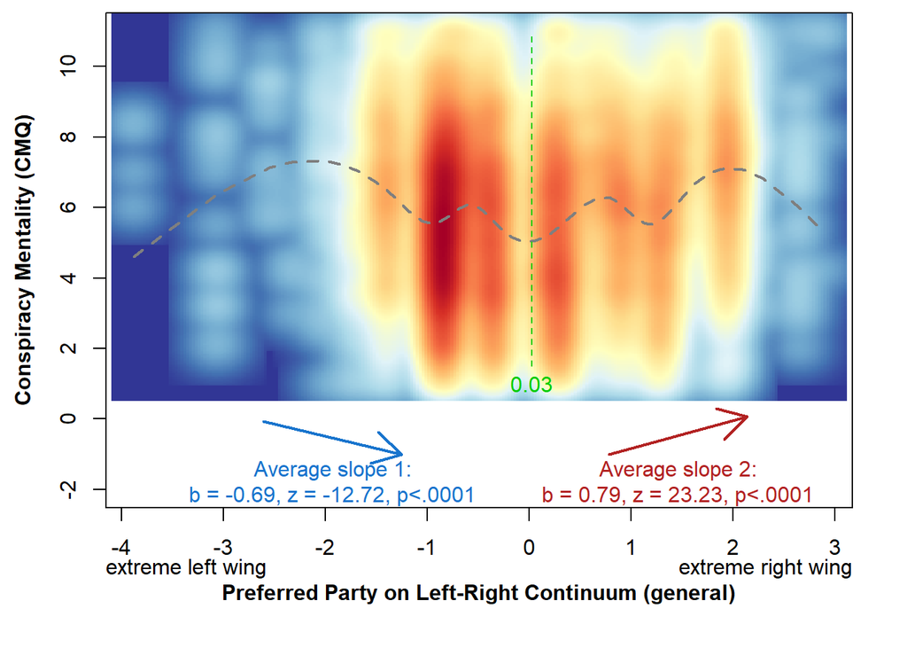

```r
a=twolines(CM4x~zlrgen,data=data,x.label="Preferred Party on Left-Right Continuum (general)",y.label="Conspiracy Mentality (CMQ)",label.extremes=T,lab.extreme.low="extreme left wing",lab.extreme.high="extreme right wing")
```

Left-Right (Economic), twolines

```
## Das folgende Objekt ist maskiert durch .GlobalEnv:
##
##     lr_galtan_cor
##
## Das folgende Objekt ist maskiert durch .GlobalEnv:
##
##     lr_galtan_cor
```

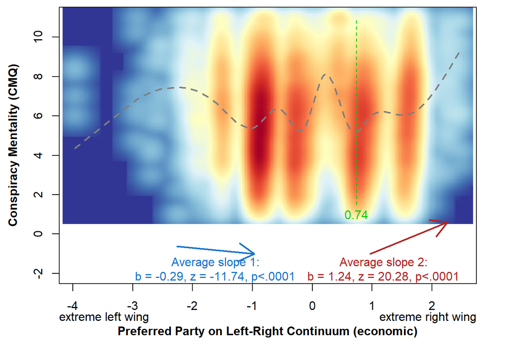

```r
a=twolines(CM4x~zlrecon,data=data, x.label="Preferred Party on Left-Right Continuum (economic)",y.label="Conspiracy Mentality (CMQ)",label.extremes=T,lab.extreme.low="extreme left wing",lab.extreme.high="extreme right wing")
```

Galtan, twolines

```
## Das folgende Objekt ist maskiert durch .GlobalEnv:
##
##     lr_galtan_cor
##
## Das folgende Objekt ist maskiert durch .GlobalEnv:
##
##     lr_galtan_cor
```

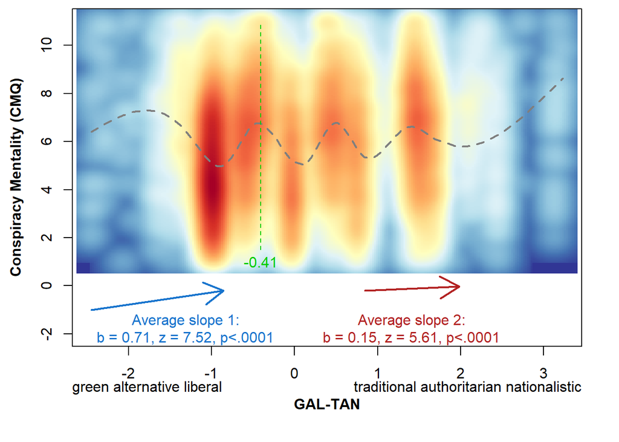

```r
a=twolines(CM4x~zgaltan,data=data, x.label="GAL-TAN",y.label="Conspiracy Mentality (CMQ)",label.extremes=T,lab.extreme.low="green alternative liberal",lab.extreme.high="traditional authoritarian nationalistic")
```

Adding zmean for control

Left-Right (General), mixed model + zmean

```r
model.1=lmer(CM4x ~ zlrgen + I(zlrgen^2)+ (zlrgen+I(zlrgen^2)|Country) + zmean_lrgen, data=data, REML=FALSE, control = lmerControl(optimizer="optimx", optCtrl=list(method="bobyqa")) )
summary(model.1)
```

```
## Linear mixed model fit by maximum likelihood . t-tests use Satterthwaite's
##   method [lmerModLmerTest]
## Formula: CM4x ~ zlrgen + I(zlrgen^2) + (zlrgen + I(zlrgen^2) | Country) +
##     zmean_lrgen
##    Data: data
## Control: lmerControl(optimizer = "optimx", optCtrl = list(method = "bobyqa"))
##
##      AIC      BIC   logLik deviance df.resid
## 104811.9 104901.0 -52395.0 104789.9    24313
##
## Scaled residuals:
##     Min      1Q  Median      3Q     Max
## -3.2667 -0.7257 -0.0114  0.7172  3.0545
##
## Random effects:
##  Groups   Name        Variance Std.Dev. Corr
##  Country  (Intercept) 0.77627  0.8811
##           zlrgen      0.04755  0.2181   -0.04
##           I(zlrgen^2) 0.03770  0.1942   -0.70 -0.21
##  Residual             4.32324  2.0792
## Number of obs: 24324, groups:  Country, 21
##
## Fixed effects:
##             Estimate Std. Error       df t value Pr(>|t|)
## (Intercept)  6.71206    0.19719 21.40414  34.039   <2e-16 ***
## zlrgen       0.05830    0.05630 19.18754   1.036   0.3133
## I(zlrgen^2)  0.15697    0.05025 20.68106   3.124   0.0052 **
## zmean_lrgen -0.05857    0.09739 23.96180  -0.601   0.5532
## ---
## Signif. codes:  0 '***' 0.001 '**' 0.01 '*' 0.05 '.' 0.1 ' ' 1
##
## Correlation of Fixed Effects:
##             (Intr) zlrgen I(z^2)
## zlrgen      -0.033
## I(zlrgen^2) -0.651 -0.201
## zmean_lrgen -0.114  0.104  0.029
```

Left-Right (Economic), mixed model + zmean

```r
model.2=lmer(CM4x ~ zlrecon + I(zlrecon^2) + (zlrecon+I(zlrecon^2)|Country) + zmean_lrecon, data=data, REML=FALSE, control = lmerControl(optimizer="optimx", optCtrl=list(method="bobyqa")) )
summary(model.2)
```

```
## Linear mixed model fit by maximum likelihood . t-tests use Satterthwaite's
##   method [lmerModLmerTest]
## Formula: CM4x ~ zlrecon + I(zlrecon^2) + (zlrecon + I(zlrecon^2) | Country) +
##     zmean_lrecon
##    Data: data
## Control: lmerControl(optimizer = "optimx", optCtrl = list(method = "bobyqa"))
##
##      AIC      BIC   logLik deviance df.resid
## 105573.5 105662.6 -52775.7 105551.5    24313
##
## Scaled residuals:
##     Min      1Q  Median      3Q     Max
## -3.1779 -0.7224 -0.0253  0.7107  2.9289
##
## Random effects:
##  Groups   Name         Variance Std.Dev. Corr
##  Country  (Intercept)  0.60442  0.7774
##           zlrecon      0.01122  0.1059    0.11
##           I(zlrecon^2) 0.03012  0.1735   -0.38 -0.24
##  Residual              4.46383  2.1128
## Number of obs: 24324, groups:  Country, 21
##
## Fixed effects:
##              Estimate Std. Error       df t value Pr(>|t|)
## (Intercept)   6.75347    0.17341 21.63120  38.945   <2e-16 ***
## zlrecon       0.02164    0.03438 18.27910   0.629    0.537
## I(zlrecon^2)  0.09833    0.04503 13.63429   2.183    0.047 *
## zmean_lrecon -0.11704    0.09552 21.65233  -1.225    0.234
## ---
## Signif. codes:  0 '***' 0.001 '**' 0.01 '*' 0.05 '.' 0.1 ' ' 1
##
## Correlation of Fixed Effects:
##             (Intr) zlrecn I(z^2)
## zlrecon      0.071
## I(zlrecn^2) -0.389 -0.138
## zmean_lrecn  0.020  0.020 -0.004
```

Galtan, mixed model + zmean

```r
model.3=lmer(CM4x ~ zgaltan + I(zgaltan^2)  +(zgaltan+I(zgaltan^2)|Country) + zmean_galtan, data=data, REML=FALSE, control = lmerControl(optimizer="optimx", optCtrl=list(method="bobyqa")) )
```

```
## boundary (singular) fit: see ?isSingular
```

```r
summary(model.3)
```

```
## Linear mixed model fit by maximum likelihood . t-tests use Satterthwaite's
##   method [lmerModLmerTest]
## Formula: CM4x ~ zgaltan + I(zgaltan^2) + (zgaltan + I(zgaltan^2) | Country) +
##     zmean_galtan
##    Data: data
## Control: lmerControl(optimizer = "optimx", optCtrl = list(method = "bobyqa"))
##
##      AIC      BIC   logLik deviance df.resid
## 105468.2 105557.2 -52723.1 105446.2    24313
##
## Scaled residuals:
##     Min      1Q  Median      3Q     Max
## -3.2997 -0.7360 -0.0270  0.6975  2.9206
##
## Random effects:
##  Groups   Name         Variance Std.Dev. Corr
##  Country  (Intercept)  0.478077 0.69143
##           zgaltan      0.036635 0.19140  -0.47
##           I(zgaltan^2) 0.004218 0.06494   0.35 -0.99
##  Residual              4.449214 2.10932
## Number of obs: 24324, groups:  Country, 21
##
## Fixed effects:
##              Estimate Std. Error       df t value Pr(>|t|)
## (Intercept)   6.74414    0.16466 21.72911  40.958  < 2e-16 ***
## zgaltan       0.17364    0.05059 18.66134   3.432  0.00285 **
## I(zgaltan^2)  0.02368    0.02209 15.34553   1.072  0.30039
## zmean_galtan  0.18916    0.12286 22.09560   1.540  0.13785
## ---
## Signif. codes:  0 '***' 0.001 '**' 0.01 '*' 0.05 '.' 0.1 ' ' 1
##
## Correlation of Fixed Effects:
##             (Intr) zgaltn I(z^2)
## zgaltan     -0.315
## I(zgaltn^2)  0.087 -0.805
## zmean_galtn -0.354 -0.019  0.115
## optimizer (optimx) convergence code: 0 (OK)
## boundary (singular) fit: see ?isSingular
```

# Control Analyses for 5 Items

## CM and belief in CTS

Mean Conspiracy Belief and within Country Alpha

```r
a = as.character(unique(data$Country))
ct_dat = lapply(a,function(x) (data[data$Country == x, c("CT_left", "CT_right", "CT_neutral")]))

ctmean = sapply(ct_dat,function(dat) rowMeans(dat,na.rm=F))
data$CT_mean =  do.call(c,ctmean)

ct_dat = ct_dat[which(a!="Germany")]
alphas = sapply(ct_dat,function(dat)  psych::alpha(dat,max=10000)$total$raw_alpha)
```

```
## Some items ( CT_left ) were negatively correlated with the total scale and
## probably should be reversed.
## To do this, run the function again with the 'check.keys=TRUE' option
```

[output not shown]

[output not shown]

[output not shown]

[output not shown]

```r
names(alphas)=a[which(a!="Germany")]
alphas
```

```
##         Iceland     Belgium, FR          Bosnia          Brazil Switzerland, FR
##      0.36716462      0.69579367      0.83227153      0.62773733      0.74330764
## Switzerland, GE         Croatia  Czech Republic          France          Greece
##      0.57610677      0.09182243      0.79936607      0.76677201      0.48305472
##         Hungary           Italy       Macedonia     Netherlands          Poland
##     -0.48544155      0.79297666     -0.09632987      0.81710370      0.27446535
##          Serbia           Spain          Turkey          Norway          Israel
##      0.79373877      0.64228126      0.15708021      0.63106992     -0.44769953
##        Portugal         Romania              UK
##      0.59975424      0.68803975      0.56101313
```

Meta-Analysis of the within-country correlations

```r
a = as.character(unique(data$Country))
a1 = lapply(a, function(x) {
 df = data[data$Country == x, c("CM5x", "CT_left", "CT_right", "CT_neutral","CT_mean")]
 b1 = cor(df, use ="pairwise.complete.obs")[2:5, 1]
 b2 = c(sum(complete.cases(df[,c(1,2)])),sum(complete.cases(df[,c(1,3)])),sum(complete.cases(df[,c(1,4)])),sum(complete.cases(df[,c(1,5)])))
   return(c(b1,b2))
})
names(a1) = a
cors = t(as.data.frame(a1))
cors = cors[!rownames(cors)==("Germany"),]
cors = cors[order(rownames(cors)),]

left <- metacor(cors[,1], cors[,4],rownames(cors))
left
```

```
##                    COR 95%-CI %W(fixed) %W(random)
## Belgium..FR     0.4343              0.0        0.0
## Bosnia          0.4073              0.0        0.0
## Brazil          0.4758              0.0        0.0
## Croatia         0.1116              0.0        0.0
## Czech.Republic  0.5430              0.0        0.0
## France          0.6408              0.0        0.0
## Greece          0.4705              0.0        0.0
## Hungary         0.1555              0.0        0.0
## Iceland         0.4585              0.0        0.0
## Israel          0.1493              0.0        0.0
## Italy           0.5211              0.0        0.0
## Macedonia       0.0816              0.0        0.0
## Netherlands     0.5967              0.0        0.0
## Norway          0.1915              0.0        0.0
## Poland          0.1546              0.0        0.0
## Portugal        0.3324              0.0        0.0
## Romania         0.2453              0.0        0.0
## Serbia          0.4137              0.0        0.0
## Spain           0.2184              0.0        0.0
## Switzerland..FR 0.5177              0.0        0.0
## Switzerland..GE 0.4328              0.0        0.0
## Turkey          0.3073              0.0        0.0
## UK              0.3832              0.0        0.0
##
## Number of studies combined: k = 0
##
##                      COR 95%-CI  z p-value
## Fixed effect model    NA        --      --
## Random effects model  NA        --      --
##
## Quantifying heterogeneity:
##  tau^2 = NA; tau = NA; I^2 = NA; H = NA
##
## Details on meta-analytical method:
## - Inverse variance method
## - DerSimonian-Laird estimator for tau^2
## - Fisher's z transformation of correlations
```

[figure not shown]

```r
forest(left)
```

```r
right <- metacor(cors[,2], cors[,5],rownames(cors))
right
```

```
##                     COR            95%-CI %W(fixed) %W(random)
## Belgium..FR      0.2834 [ 0.2035; 0.3596]       1.8        4.3
## Bosnia           0.4026 [ 0.2960; 0.4992]       0.9        4.1
## Brazil           0.3070 [ 0.2596; 0.3530]       5.0        4.5
## Croatia          0.2497 [ 0.1723; 0.3241]       2.0        4.3
## Czech.Republic   0.5240 [ 0.4544; 0.5871]       1.6        4.3
## France           0.5190 [ 0.4612; 0.5724]       2.3        4.4
## Greece           0.2142 [ 0.1265; 0.2985]       1.6        4.3
## Hungary          0.1374 [ 0.0760; 0.1977]       3.4        4.4
## Iceland          0.2764 [ 0.2035; 0.3463]       2.2        4.4
## Israel           0.0689 [-0.0274; 0.1640]       1.4        4.2
## Italy            0.3148 [ 0.2399; 0.3860]       2.0        4.3
## Macedonia        0.2377 [ 0.1617; 0.3109]       2.1        4.4
## Netherlands      0.4491 [ 0.4350; 0.4629]      43.6        4.6
## Norway           0.2885 [ 0.2475; 0.3284]       6.8        4.5
## Poland          -0.0421 [-0.1269; 0.0432]       1.8        4.3
## Portugal         0.1735 [ 0.0880; 0.2565]       1.8        4.3
## Romania          0.3906 [ 0.2980; 0.4760]       1.2        4.2
## Serbia           0.3401 [ 0.2848; 0.3932]       3.5        4.4
## Spain           -0.0128 [-0.0736; 0.0481]       3.6        4.4
## Switzerland..FR  0.3670 [ 0.2886; 0.4405]       1.7        4.3
## Switzerland..GE  0.2603 [ 0.1540; 0.3606]       1.1        4.1
## Turkey           0.0517 [-0.0117; 0.1147]       3.3        4.4
## UK               0.3092 [ 0.2626; 0.3542]       5.2        4.5
##
## Number of studies combined: k = 23
##
##                         COR           95%-CI     z  p-value
## Fixed effect model   0.3433 [0.3331; 0.3534] 60.85        0
## Random effects model 0.2716 [0.2026; 0.3378]  7.47 < 0.0001
##
## Quantifying heterogeneity:
##  tau^2 = 0.0303 [0.0147; 0.0591]; tau = 0.1742 [0.1211; 0.2431]
##  I^2 = 96.9% [96.2%; 97.5%]; H = 5.70 [5.11; 6.36]
##
## Test of heterogeneity:
##       Q d.f.  p-value
##  715.86   22 < 0.0001
##
## Details on meta-analytical method:
## - Inverse variance method
## - DerSimonian-Laird estimator for tau^2
## - Jackson method for confidence interval of tau^2 and tau
## - Fisher's z transformation of correlations
```

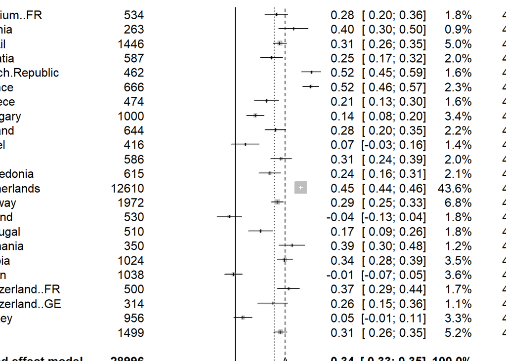

```r
forest(right)
```

```r
available = !is.na(cors[,3])
neutral <- metacor(cors[available,3], cors[available,6],rownames(cors[available,]))
neutral
```

```
##                    COR            95%-CI %W(fixed) %W(random)
## Belgium..FR     0.4494 [ 0.3790; 0.5146]       1.9        4.5
## Bosnia          0.5352 [ 0.4429; 0.6163]       0.9        4.4
## Brazil          0.3980 [ 0.3537; 0.4405]       5.1        4.6
## Croatia         0.3966 [ 0.3264; 0.4625]       2.1        4.5
## Czech.Republic  0.5318 [ 0.4630; 0.5942]       1.6        4.5
## France          0.6569 [ 0.6115; 0.6981]       2.3        4.6
## Greece          0.5160 [ 0.4454; 0.5802]       1.6        4.5
## Hungary         0.3639 [ 0.3089; 0.4165]       3.5        4.6
## Iceland         0.3493 [ 0.2793; 0.4156]       2.2        4.5
## Italy           0.5200 [ 0.4584; 0.5767]       2.0        4.5
## Macedonia       0.3350 [ 0.2629; 0.4034]       2.1        4.5
## Netherlands     0.6953 [ 0.6862; 0.7042]      44.1        4.6
## Norway          0.2935 [ 0.2527; 0.3333]       6.9        4.6
## Poland          0.2602 [ 0.1833; 0.3339]       2.1        4.5
## Portugal        0.3489 [ 0.2702; 0.4229]       1.8        4.5
## Romania         0.4071 [ 0.3157; 0.4909]       1.2        4.5
## Serbia          0.3365 [ 0.2809; 0.3899]       3.6        4.6
## Spain           0.0513 [-0.0095; 0.1118]       3.6        4.6
## Switzerland..FR 0.5023 [ 0.4337; 0.5651]       1.7        4.5
## Switzerland..GE 0.2620 [ 0.1559; 0.3622]       1.1        4.5
## Turkey          0.2917 [ 0.2327; 0.3486]       3.4        4.6
## UK              0.4279 [ 0.3856; 0.4684]       5.2        4.6
##
## Number of studies combined: k = 22
##
##                         COR           95%-CI      z  p-value
## Fixed effect model   0.5368 [0.5285; 0.5450] 101.35        0
## Random effects model 0.4161 [0.3114; 0.5109]   7.18 < 0.0001
##
## Quantifying heterogeneity:
##  tau^2 = 0.0821 [0.0266; 0.1084]; tau = 0.2866 [0.1632; 0.3293]
##  I^2 = 98.9% [98.7%; 99.0%]; H = 9.42 [8.69; 10.21]
##
## Test of heterogeneity:
##        Q d.f. p-value
##  1863.36   21       0
##
## Details on meta-analytical method:
## - Inverse variance method
## - DerSimonian-Laird estimator for tau^2
## - Jackson method for confidence interval of tau^2 and tau
## - Fisher's z transformation of correlations
```

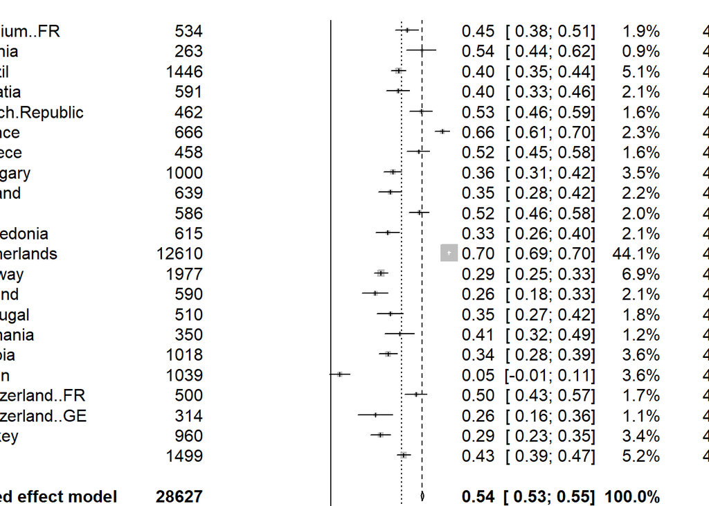

```r
forest(neutral)
```

```r
available = !is.na(cors[,4])
meanCT <- metacor(cors[available,4], cors[available,7],rownames(cors[available,]))
meanCT
```

```
##                    COR           95%-CI %W(fixed) %W(random)
## Belgium..FR     0.4901 [0.4229; 0.5520]       1.9        4.5
## Bosnia          0.5170 [0.4225; 0.6004]       0.9        4.4
## Brazil          0.5208 [0.4822; 0.5574]       5.1        4.6
## Croatia         0.4185 [0.3494; 0.4831]       2.1        4.5
## Czech.Republic  0.6291 [0.5706; 0.6812]       1.6        4.5
## France          0.7369 [0.7001; 0.7698]       2.3        4.6
## Greece          0.5871 [0.5195; 0.6475]       1.4        4.5
## Hungary         0.3937 [0.3400; 0.4449]       3.5        4.6
## Iceland         0.5516 [0.4949; 0.6037]       2.2        4.5
## Italy           0.5369 [0.4767; 0.5922]       2.0        4.5
## Macedonia       0.3898 [0.3206; 0.4548]       2.2        4.5
## Netherlands     0.6672 [0.6574; 0.6768]      44.3        4.7
## Norway          0.3401 [0.3002; 0.3787]       6.8        4.6
## Poland          0.1789 [0.0997; 0.2560]       2.1        4.5
## Portugal        0.3869 [0.3105; 0.4584]       1.8        4.5
## Romania         0.4484 [0.3603; 0.5286]       1.2        4.4
## Serbia          0.4318 [0.3807; 0.4802]       3.6        4.6
## Spain           0.1159 [0.0553; 0.1757]       3.6        4.6
## Switzerland..FR 0.5648 [0.5020; 0.6217]       1.7        4.5
## Switzerland..GE 0.4322 [0.3377; 0.5181]       1.1        4.4
## Turkey          0.3547 [0.2978; 0.4091]       3.3        4.6
## UK              0.5090 [0.4705; 0.5455]       5.3        4.6
##
## Number of studies combined: k = 22
##
##                         COR           95%-CI      z  p-value
## Fixed effect model   0.5535 [0.5454; 0.5615] 105.17        0
## Random effects model 0.4755 [0.3952; 0.5486]  10.22 < 0.0001
##
## Quantifying heterogeneity:
##  tau^2 = 0.0547 [0.0225; 0.0919]; tau = 0.2339 [0.1499; 0.3032]
##  I^2 = 98.3% [98.0%; 98.6%]; H = 7.69 [7.02; 8.43]
##
## Test of heterogeneity:
##        Q d.f.  p-value
##  1242.73   21 < 0.0001
##
## Details on meta-analytical method:
## - Inverse variance method
## - DerSimonian-Laird estimator for tau^2
## - Jackson method for confidence interval of tau^2 and tau
## - Fisher's z transformation of correlations
```

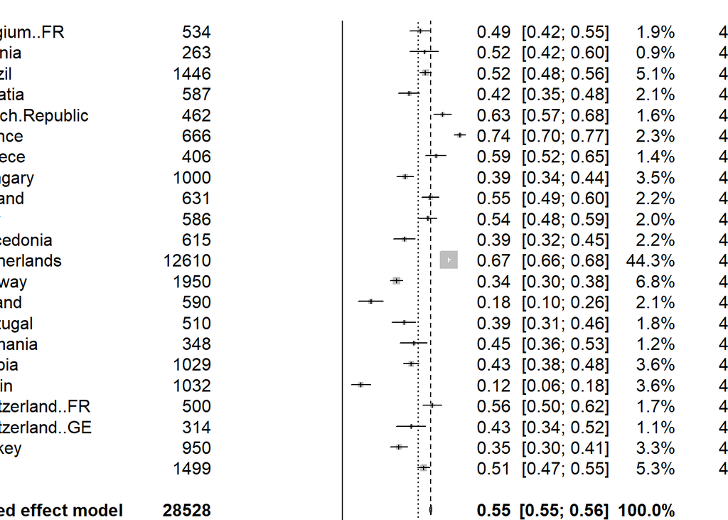

```r
forest(meanCT)
```

## CM and PO

Mixed Model

```r
model.cmpo =lmer(CM5x~ZPO+I(ZPO^2)+(ZPO+I(ZPO^2)|Country), data=data, REML=FALSE, control = lmerControl(optimizer="optimx", optCtrl=list(method="bobyqa")) )
summary(model.cmpo)
```

```
## Linear mixed model fit by maximum likelihood . t-tests use Satterthwaite's
##   method [lmerModLmerTest]
## Formula: CM5x ~ ZPO + I(ZPO^2) + (ZPO + I(ZPO^2) | Country)
##    Data: data
## Control: lmerControl(optimizer = "optimx", optCtrl = list(method = "bobyqa"))
##
##      AIC      BIC   logLik deviance df.resid
## 137339.1 137423.1 -68659.6 137319.1    32592
##
## Scaled residuals:
##     Min      1Q  Median      3Q     Max
## -3.5898 -0.6754  0.0106  0.7080  2.8107
##
## Random effects:
##  Groups   Name        Variance Std.Dev. Corr
##  Country  (Intercept) 0.52429  0.72408
##           ZPO         0.02346  0.15316  -0.41
##           I(ZPO^2)    0.00401  0.06333  -0.52  0.21
##  Residual             3.93143  1.98278
## Number of obs: 32602, groups:  Country, 24
##
## Fixed effects:
##             Estimate Std. Error       df t value Pr(>|t|)
## (Intercept)  7.19130    0.14915 24.24461  48.214  < 2e-16 ***
## ZPO          0.08951    0.03515 22.12950   2.546  0.01836 *
## I(ZPO^2)     0.05226    0.01722 28.36520   3.034  0.00512 **
## ---
## Signif. codes:  0 '***' 0.001 '**' 0.01 '*' 0.05 '.' 0.1 ' ' 1
##
## Correlation of Fixed Effects:
##          (Intr) ZPO
## ZPO      -0.363
## I(ZPO^2) -0.439  0.123
```

Twolines Plot

```
## Das folgende Objekt ist maskiert durch .GlobalEnv:
##
##     lr_galtan_cor
##
## Das folgende Objekt ist maskiert durch .GlobalEnv:
##
##     lr_galtan_cor
```

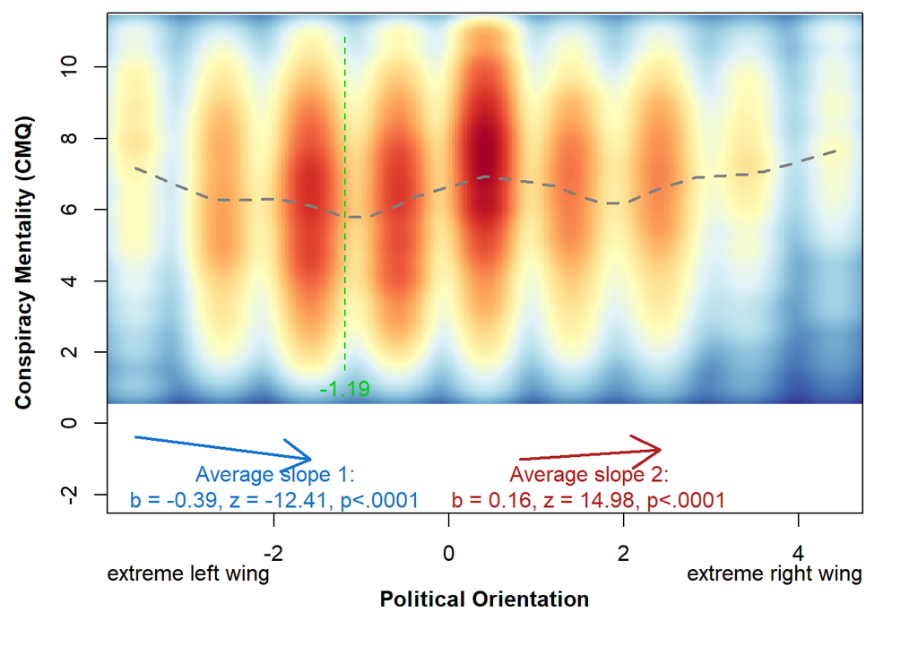

```r
data$Pol_Ori_centered = scale(data$Pol_Ori,scale=F)
a=twolines(CM5x~Pol_Ori_centered,data=data, x.label="Political Orientation",y.label="Conspiracy Mentality (CMQ)",label.extremes=T,lab.extreme.low="extreme left wing",lab.extreme.high="extreme right wing")
```

by country effects in the mixed model

```r
coef(model.cmpo)
```

```
## $Country
##                 (Intercept)         ZPO      I(ZPO^2)
## Belgium, FR        7.723409 -0.01855822  0.0947389326
## Bosnia             7.601932 -0.04570303  0.0528650648
## Brazil             7.307395 -0.03210586  0.1093311713
## Croatia            7.374268  0.23387400  0.0628014961
## Czech Republic     6.525624  0.09714822  0.0569167143
## France             6.081909  0.22919438  0.0893831063
## Germany            7.126613  0.09155801  0.0474880072
## Greece             7.050865  0.16969669  0.0681579856
## Hungary            7.968026  0.10131969  0.0412642238
## Iceland            6.778173 -0.12758352  0.0268855028
## Israel             7.711973 -0.01627415  0.0180282484
## Italy              6.754768  0.29716081  0.0556366990
## Macedonia          7.406303  0.09746455  0.0557282570
## Netherlands        5.449909  0.14573807  0.1810224992
## Norway             6.084619  0.16137920  0.1276236286
## Poland             6.043227  0.24383022  0.0451666135
## Portugal           8.177071  0.12214719  0.0358631084
## Romania            7.757154  0.24850018 -0.0029129984
## Serbia             7.853054 -0.05047537  0.0007688352
## Spain              7.914249 -0.17167842 -0.0879095918
## Switzerland, FR    7.043815  0.22627272  0.0590944054
## Switzerland, GE    7.406252  0.20931840  0.0132634024
## Turkey             8.195098 -0.18722673  0.0422157977
## UK                 7.255399  0.12314700  0.0607954689
##
## attr(,"class")
## [1] "coef.mer"
```

Linear Model for each country

```r
by.country = matrix(NA,0,7)
for (i in unique(data$Country)) {
test = lm(CM5x~ZPO+I(ZPO^2),data[data$Country == i,])
a = coef(test)
b = summary(test)$coefficients[,4] #p-values
b2 = summary(test)$coefficients[,2] #SE
d = c(as.numeric(a)[-1],as.numeric(b2)[-1],as.numeric(b)[-1])
d = c(i,d)
by.country = rbind(by.country,d)
}
by.country = as.data.frame(by.country)
names(by.country) = c("Country","ZPO","ZPO2","SE_ZPO","SE_ZPO2","p_ZPO","p_ZPO2")
by.country[,2:7] = apply(by.country[,2:7],2,as.numeric)

by.country$CI95_low_ZPO = by.country$ZPO-qnorm(.975)*by.country$SE_ZPO
by.country$CI95_high_ZPO = by.country$ZPO+qnorm(.975)*by.country$SE_ZPO
by.country$sig_ZPO = by.country$p_ZPO<.05
by.country$sigbonf_ZPO = by.country$p_ZPO<.05/nrow(by.country)

by.country$CI95_low_ZPO2 = by.country$ZPO2-qnorm(.975)*by.country$SE_ZPO2
by.country$CI95_high_ZPO2 = by.country$ZPO2+qnorm(.975)*by.country$SE_ZPO2
by.country$sig_ZPO2 = by.country$p_ZPO2 <.05
by.country$sigbonf_ZPO2 = by.country$p_ZPO2 <.05/nrow(by.country)

export = by.country[,c(1,2,8,9,10,11,3,12,13,14,15)]
export
```

|  | Country | ZPO | CI95_low_ZPO | CI95_high_ZPO | sig_ZPO | sigbonf_ZPO | ZPO2 | CI95_low_ZPO2 | CI95_high_ZPO2 | sig_ZPO2 | sigbonf_ZPO2 |
| --- | --- | --- | --- | --- | --- | --- | --- | --- | --- | --- | --- |
| d | Iceland | -0.22374837 | -0.385594013 | -0.06190272 | TRUE | FALSE | -0.03709383 | -0.172733168 | 0.09854551 | FALSE | FALSE |
| d.1 | Belgium, FR | -0.05809578 | -0.207252488 | 0.09106093 | FALSE | FALSE | 0.17024479 | 0.069006450 | 0.27148312 | TRUE | TRUE |
| d.2 | Bosnia | -0.12452587 | -0.336275036 | 0.08722330 | FALSE | FALSE | 0.09719344 | -0.048747205 | 0.24313408 | FALSE | FALSE |
| d.3 | Brazil | -0.05097983 | -0.140676193 | 0.03871653 | FALSE | FALSE | 0.13778765 | 0.075129460 | 0.20044584 | TRUE | TRUE |
| d.4 | Switzerland, FR | 0.27658966 | 0.100679421 | 0.45249989 | TRUE | FALSE | 0.05860162 | -0.067161070 | 0.18436431 | FALSE | FALSE |
| d.5 | Switzerland, GE | 0.31620789 | 0.121144758 | 0.51127102 | TRUE | TRUE | -0.07604783 | -0.225110010 | 0.07301435 | FALSE | FALSE |
| d.6 | Croatia | 0.28623871 | 0.118794005 | 0.45368342 | TRUE | TRUE | 0.06932768 | -0.060156777 | 0.19881214 | FALSE | FALSE |
| d.7 | Czech Republic | 0.06009844 | -0.095737583 | 0.21593445 | FALSE | FALSE | 0.01886549 | -0.093366253 | 0.13109723 | FALSE | FALSE |
| d.8 | France | 0.24749273 | 0.077519261 | 0.41746619 | TRUE | FALSE | 0.07862725 | -0.035698006 | 0.19295251 | FALSE | FALSE |
| d.9 | Greece | 0.19949258 | 0.010747889 | 0.38823727 | TRUE | FALSE | 0.08364865 | -0.064998831 | 0.23229613 | FALSE | FALSE |

[output cut: 14 more lines]

```r
#print(xtable(export,digits=4),type="html",file="./table.html")
```

Exploratory: Interaction of ZPO and Countryvars in predicting CM

```r
countrylevelvars = c("lrgengov", "lrecongov","galtangov")

for (i in 1:length(countrylevelvars)) {
fmla <- as.formula(paste("CM5x~ZPO+I(ZPO^2)+(ZPO+I(ZPO^2)|Country) +",countrylevelvars[i],"+ ZPO *",countrylevelvars[i],"+ I(ZPO^2) *",countrylevelvars[i]))
model.1 =lmer(fmla, data=data, REML=FALSE, control = lmerControl(optimizer="optimx", optCtrl=list(method="bobyqa")))
summary(model.1) %>% print()
}
```

```
## Linear mixed model fit by maximum likelihood . t-tests use Satterthwaite's
##   method [lmerModLmerTest]
## Formula: fmla
##    Data: data
## Control: lmerControl(optimizer = "optimx", optCtrl = list(method = "bobyqa"))
##
##      AIC      BIC   logLik deviance df.resid
## 126473.2 126581.2 -63223.6 126447.2    29873
##
## Scaled residuals:
##     Min      1Q  Median      3Q     Max
## -3.5614 -0.6870  0.0115  0.7114  2.7828
##
## Random effects:
##  Groups   Name        Variance Std.Dev. Corr
##  Country  (Intercept) 0.588392 0.76707
##           ZPO         0.016684 0.12916  -0.57
##           I(ZPO^2)    0.003755 0.06128  -0.61  0.43
##  Residual             4.009465 2.00236
## Number of obs: 29886, groups:  Country, 20
##
## Fixed effects:
##                    Estimate Std. Error        df t value Pr(>|t|)
## (Intercept)        6.940126   0.690136 20.276176  10.056 2.51e-09 ***
## ZPO                0.311025   0.137194 21.008948   2.267   0.0341 *
## I(ZPO^2)           0.039277   0.077766 35.110558   0.505   0.6167
## lrgengov           0.033852   0.107916 20.228011   0.314   0.7570
## ZPO:lrgengov      -0.033161   0.021250 20.185632  -1.560   0.1342
## I(ZPO^2):lrgengov  0.002883   0.011984 33.513410   0.241   0.8113
## ---
## Signif. codes:  0 '***' 0.001 '**' 0.01 '*' 0.05 '.' 0.1 ' ' 1
##
## Correlation of Fixed Effects:
##             (Intr) ZPO    I(ZPO^2) lrgngv ZPO:lr
## ZPO         -0.474
## I(ZPO^2)    -0.479  0.228
## lrgengov    -0.968  0.459  0.463
## ZPO:lrgengv  0.463 -0.970 -0.221   -0.478
## I(ZPO^2):lr  0.469 -0.222 -0.972   -0.483  0.230
## Linear mixed model fit by maximum likelihood . t-tests use Satterthwaite's
```

[output cut: 62 more lines]

```
## ZPO                 0.25901    0.08365 19.49076   3.096  0.00581 **
## I(ZPO^2)            0.12305    0.04580 27.14065   2.687  0.01217 *
## galtangov           0.10234    0.06421 20.16348   1.594  0.12654
## ZPO:galtangov      -0.02589    0.01295 19.47218  -2.000  0.05970 .
## I(ZPO^2):galtangov -0.01098    0.00712 28.98784  -1.542  0.13388
## ---
## Signif. codes:  0 '***' 0.001 '**' 0.01 '*' 0.05 '.' 0.1 ' ' 1
##
## Correlation of Fixed Effects:
##             (Intr) ZPO    I(ZPO^2) gltngv ZPO:gl
## ZPO         -0.387
## I(ZPO^2)    -0.386  0.056
## galtangov   -0.919  0.355  0.355
## ZPO:galtngv  0.356 -0.923 -0.044   -0.386
## I(ZPO^2):gl  0.355 -0.044 -0.926   -0.385  0.044
```

Correlations of CountryVars and Slopes

```r
sl = coef(model.cmpo)$Country
cl = aggregate(data[countrylevelvars],by=list(data$Country),mean)
df = cbind(sl,cl[,-1])
df = df[,-1]
res<-rcorr(as.matrix(df[,])) # using Hmisc
res = lapply(res,function(x) x[3:length(df),1:2])
res = cbind(res$r,res$P)
res =as.data.frame(res)
names(res) = c("ZPO","ZPO2","pZPO","pZPO2")
res$sigZPO = res$pZPO<.05
res$sigZPO2 = res$pZPO2<.05
res
```

|  | ZPO | ZPO2 | pZPO | pZPO2 | sigZPO | sigZPO2 |
| --- | --- | --- | --- | --- | --- | --- |
| lrgengov | -0.3161412 | 0.01090782 | 0.1744880 | 0.9635961 | FALSE | FALSE |
| lrecongov | -0.3509876 | 0.12869421 | 0.1291794 | 0.5886891 | FALSE | FALSE |
| galtangov | -0.4327622 | -0.36935680 | 0.0566690 | 0.1089950 | FALSE | FALSE |

Between countries

```r
 model.1=lmer(CM5x~ZPO+I(ZPO^2)+ZmeanPO+I(ZmeanPO^2)+(ZPO+I(ZPO^2)|Country), data=data, REML=FALSE, control = lmerControl(optimizer="optimx", optCtrl=list(method="bobyqa")) )
 summary(model.1)
```

```
## Linear mixed model fit by maximum likelihood . t-tests use Satterthwaite's
##   method [lmerModLmerTest]
## Formula: CM5x ~ ZPO + I(ZPO^2) + ZmeanPO + I(ZmeanPO^2) + (ZPO + I(ZPO^2) |
##     Country)
##    Data: data
## Control: lmerControl(optimizer = "optimx", optCtrl = list(method = "bobyqa"))
##
##      AIC      BIC   logLik deviance df.resid
## 137342.5 137443.3 -68659.3 137318.5    32590
##
## Scaled residuals:
##     Min      1Q  Median      3Q     Max
## -3.5911 -0.6750  0.0107  0.7078  2.8109
##
## Random effects:
##  Groups   Name        Variance Std.Dev. Corr
##  Country  (Intercept) 0.539993 0.73484
##           ZPO         0.023369 0.15287  -0.41
##           I(ZPO^2)    0.003991 0.06317  -0.58  0.22
##  Residual             3.931453 1.98279
## Number of obs: 32602, groups:  Country, 24
##
## Fixed effects:
##               Estimate Std. Error        df t value Pr(>|t|)
## (Intercept)   7.220146   0.176551 26.186809  40.896  < 2e-16 ***
## ZPO           0.088969   0.035114 22.155714   2.534  0.01886 *
## I(ZPO^2)      0.051375   0.017194 28.427228   2.988  0.00573 **
## ZmeanPO      -0.069400   0.109303 23.193964  -0.635  0.53169
## I(ZmeanPO^2) -0.001447   0.047396 25.166040  -0.031  0.97588
## ---
## Signif. codes:  0 '***' 0.001 '**' 0.01 '*' 0.05 '.' 0.1 ' ' 1
##
## Correlation of Fixed Effects:
##             (Intr) ZPO    I(ZPO^2) ZmenPO
## ZPO         -0.320
## I(ZPO^2)    -0.439  0.125
## ZmeanPO      0.160  0.018  0.021
## I(ZmenPO^2) -0.484  0.008  0.032   -0.618
```

+interactions

```r
model.2=lmer(CM5x~ZPO+I(ZPO^2)+ZmeanPO+I(ZmeanPO^2)+ZPO:ZmeanPO+I(ZPO^2):ZmeanPO+(ZPO+I(ZPO^2)|Country), data=data, REML=FALSE, control = lmerControl(optimizer="optimx", optCtrl=list(method="bobyqa")) )
summary(model.2)
```

```
## Linear mixed model fit by maximum likelihood . t-tests use Satterthwaite's
##   method [lmerModLmerTest]
## Formula: CM5x ~ ZPO + I(ZPO^2) + ZmeanPO + I(ZmeanPO^2) + ZPO:ZmeanPO +
##     I(ZPO^2):ZmeanPO + (ZPO + I(ZPO^2) | Country)
##    Data: data
## Control: lmerControl(optimizer = "optimx", optCtrl = list(method = "bobyqa"))
##
##      AIC      BIC   logLik deviance df.resid
## 137342.3 137459.8 -68657.2 137314.3    32588
##
## Scaled residuals:
##     Min      1Q  Median      3Q     Max
## -3.5834 -0.6758  0.0100  0.7072  2.8110
##
## Random effects:
##  Groups   Name        Variance Std.Dev. Corr
##  Country  (Intercept) 0.523297 0.72339
##           ZPO         0.022995 0.15164  -0.41
##           I(ZPO^2)    0.003262 0.05712  -0.58  0.24
##  Residual             3.931302 1.98275
## Number of obs: 32602, groups:  Country, 24
##
## Fixed effects:
##                   Estimate Std. Error        df t value Pr(>|t|)
## (Intercept)       7.204445   0.174756 26.811121  41.226  < 2e-16 ***
## ZPO               0.086522   0.035781 21.836025   2.418  0.02440 *
## I(ZPO^2)          0.058333   0.016421 29.028677   3.552  0.00133 **
## ZmeanPO           0.036481   0.124828 27.891601   0.292  0.77226
## I(ZmeanPO^2)     -0.010089   0.047576 25.566264  -0.212  0.83375
## ZPO:ZmeanPO      -0.004737   0.024328 25.119527  -0.195  0.84718
## I(ZPO^2):ZmeanPO -0.025578   0.012148 48.698197  -2.106  0.04043 *
## ---
## Signif. codes:  0 '***' 0.001 '**' 0.01 '*' 0.05 '.' 0.1 ' ' 1
##
## Correlation of Fixed Effects:
##             (Intr) ZPO    I(ZPO^2) ZmenPO I(ZmPO^2) ZPO:ZP
## ZPO         -0.317
## I(ZPO^2)    -0.420  0.118
## ZmeanPO      0.115  0.063  0.073
## I(ZmenPO^2) -0.481  0.002  0.020   -0.585
## ZPO:ZmeanPO  0.046 -0.216  0.018   -0.312  0.045
## I(ZPO^2):ZP  0.039  0.022 -0.160   -0.409  0.089     0.143
```

```r
anova(model.1,model.2)
```

|  | npar | AIC | BIC | logLik | deviance | Chisq | Df | Pr(>Chisq) |
| --- | --- | --- | --- | --- | --- | --- | --- | --- |
| model.1 | 12 | 137342.5 | 137443.3 | -68659.27 | 137318.5 | NA | NA | NA |
| model.2 | 14 | 137342.3 | 137459.8 | -68657.17 | 137314.3 | 4.215932 | 2 | 0.1214848 |

## CHES

Scale Variables across whole data

```r
data$lrgen = scale(data$lrgen)
data$lrecon = scale(data$lrecon)
data$galtan = scale(data$galtan)
```

Left-Right (General), mixed model

```r
model.1=lmer(CM5x ~ lrgen + I(lrgen^2)+ (lrgen+I(lrgen^2)|Country), data=data, REML=FALSE, control = lmerControl(optimizer="optimx", optCtrl=list(method="bobyqa")) )
summary(model.1)
```

```
## Linear mixed model fit by maximum likelihood . t-tests use Satterthwaite's
##   method [lmerModLmerTest]
## Formula: CM5x ~ lrgen + I(lrgen^2) + (lrgen + I(lrgen^2) | Country)
##    Data: data
## Control: lmerControl(optimizer = "optimx", optCtrl = list(method = "bobyqa"))
##
##      AIC      BIC   logLik deviance df.resid
## 101999.5 102080.4 -50989.7 101979.5    24289
##
## Scaled residuals:
##     Min      1Q  Median      3Q     Max
## -3.5889 -0.6983  0.0000  0.7065  3.0709
##
## Random effects:
##  Groups   Name        Variance Std.Dev. Corr
##  Country  (Intercept) 0.75531  0.8691
##           lrgen       0.02999  0.1732   -0.04
##           I(lrgen^2)  0.05072  0.2252   -0.66 -0.28
##  Residual             3.86975  1.9672
## Number of obs: 24299, groups:  Country, 21
##
## Fixed effects:
##             Estimate Std. Error       df t value Pr(>|t|)
## (Intercept)  6.97845    0.19386 21.68620  35.998  < 2e-16 ***
## lrgen        0.03402    0.04907 18.31677   0.693  0.49679
## I(lrgen^2)   0.19157    0.06037 18.70095   3.173  0.00508 **
## ---
## Signif. codes:  0 '***' 0.001 '**' 0.01 '*' 0.05 '.' 0.1 ' ' 1
##
## Correlation of Fixed Effects:
##            (Intr) lrgen
## lrgen      -0.014
## I(lrgen^2) -0.613 -0.327
```

per country coefficients (fixed+random effect)

```r
coef(model.1)
```

```
## $Country
##                 (Intercept)       lrgen   I(lrgen^2)
## Belgium, FR        7.375774  0.03307466  0.211802214
## Bosnia             7.637747  0.03439451  0.066363043
## Croatia            7.378014  0.03361440  0.179787760
## Czech Republic     6.452257 -0.06455686  0.177058418
## France             5.925213  0.01025745  0.261834230
## Germany            6.584148  0.05246199  0.476069793
## Greece             6.266105  0.22772274  0.414251100
## Hungary            7.910773  0.01791889 -0.007194769
## Italy              6.796419  0.31945106  0.046115737
## Macedonia          7.240807  0.09630893  0.183398384
## Netherlands        4.964983 -0.12475106  0.579786610
## Norway             5.819539  0.12706939  0.309156998
## Poland             5.844818 -0.01106482  0.190950822
## Portugal           7.956043  0.03279461  0.081897954
## Romania            7.704489 -0.05089291  0.061812322
## Serbia             8.029007  0.11930664 -0.131658523
## Spain              7.535928 -0.23807883  0.420584409
## Switzerland, FR    6.743812  0.17751243  0.191201507
## Switzerland, GE    7.255293  0.21144567  0.069134479
## Turkey             8.307652 -0.14424935 -0.158753971
## UK                 6.818664 -0.14525917  0.399312235
##
## attr(,"class")
## [1] "coef.mer"
```

Left-Right (Economic), mixed model

```r
model.2=lmer(CM5x ~ lrecon + I(lrecon^2) + (lrecon+I(lrecon^2)|Country), data=data, REML=FALSE, control = lmerControl(optimizer="optimx", optCtrl=list(method="bobyqa")) )
summary(model.2)
```

```
## Linear mixed model fit by maximum likelihood . t-tests use Satterthwaite's
##   method [lmerModLmerTest]
## Formula: CM5x ~ lrecon + I(lrecon^2) + (lrecon + I(lrecon^2) | Country)
##    Data: data
## Control: lmerControl(optimizer = "optimx", optCtrl = list(method = "bobyqa"))
##
##      AIC      BIC   logLik deviance df.resid
## 102873.7 102954.7 -51426.9 102853.7    24289
##
## Scaled residuals:
##     Min      1Q  Median      3Q     Max
## -3.5317 -0.6981  0.0009  0.6998  2.9330
##
## Random effects:
##  Groups   Name        Variance Std.Dev. Corr
##  Country  (Intercept) 0.65602  0.8100
##           lrecon      0.02982  0.1727   -0.10
##           I(lrecon^2) 0.06006  0.2451   -0.51 -0.18
##  Residual             4.01194  2.0030
## Number of obs: 24299, groups:  Country, 21
##
## Fixed effects:
##              Estimate Std. Error        df t value Pr(>|t|)
## (Intercept)  7.082765   0.181534 22.020255  39.016   <2e-16 ***
## lrecon      -0.009406   0.049998 16.235019  -0.188    0.853
## I(lrecon^2)  0.079645   0.068356 17.193591   1.165    0.260
## ---
## Signif. codes:  0 '***' 0.001 '**' 0.01 '*' 0.05 '.' 0.1 ' ' 1
##
## Correlation of Fixed Effects:
##             (Intr) lrecon
## lrecon      -0.063
## I(lrecon^2) -0.480 -0.165
```

per country coefficients (fixed+random effect)

```r
coef(model.2)
```

```
## $Country
##                 (Intercept)       lrecon  I(lrecon^2)
## Belgium, FR        7.330850 -0.033902468  0.203592611
## Bosnia             7.679253 -0.022415999 -0.010737591
## Croatia            7.640491 -0.026427400 -0.009341193
## Czech Republic     6.487235 -0.059381510  0.077397657
## France             6.109560 -0.122412126  0.037672660
## Germany            6.642519  0.010547185  0.453389336
## Greece             7.401130  0.111006370 -0.276240409
## Hungary            7.925673  0.021124546 -0.085571943
## Italy              6.777078  0.254592364  0.124982415
## Macedonia          7.321369 -0.027927248  0.051032664
## Netherlands        5.113914 -0.129086747  0.409975263
## Norway             5.945412  0.134879858  0.155650073
## Poland             6.024578  0.097287598  0.057288488
## Portugal           7.944917  0.009316326  0.065115345
## Romania            7.788378 -0.097728062 -0.033533908
## Serbia             8.002268  0.025379436 -0.103492118
## Spain              7.191288 -0.322625700  0.505686969
## Switzerland, FR    6.841312  0.114707517  0.069519640
## Switzerland, GE    7.071951  0.177046066  0.184959823
## Turkey             8.308223 -0.223231298 -0.253697175
## UK                 7.190674 -0.088276762  0.048888034
##
## attr(,"class")
## [1] "coef.mer"
```

Galtan, mixed model

```r
model.3=lmer(CM5x ~ galtan + I(galtan^2)  +(galtan+I(galtan^2)|Country), data=data, REML=FALSE, control = lmerControl(optimizer="optimx", optCtrl=list(method="bobyqa")) )
summary(model.3)
```

```
## Linear mixed model fit by maximum likelihood . t-tests use Satterthwaite's
##   method [lmerModLmerTest]
## Formula: CM5x ~ galtan + I(galtan^2) + (galtan + I(galtan^2) | Country)
##    Data: data
## Control: lmerControl(optimizer = "optimx", optCtrl = list(method = "bobyqa"))
##
##      AIC      BIC   logLik deviance df.resid
##   102842   102923   -51411   102822    24289
##
## Scaled residuals:
##     Min      1Q  Median      3Q     Max
## -3.5204 -0.6956  0.0053  0.7046  2.9045
##
## Random effects:
##  Groups   Name        Variance Std.Dev. Corr
##  Country  (Intercept) 0.61312  0.7830
##           galtan      0.04106  0.2026   -0.18
##           I(galtan^2) 0.02857  0.1690   -0.46 -0.57
##  Residual             4.00815  2.0020
## Number of obs: 24299, groups:  Country, 21
##
## Fixed effects:
##             Estimate Std. Error       df t value Pr(>|t|)
## (Intercept)  7.11119    0.17537 21.33934  40.550  < 2e-16 ***
## galtan       0.18893    0.06092 18.90406   3.101  0.00591 **
## I(galtan^2)  0.01820    0.04844 16.64865   0.376  0.71192
## ---
## Signif. codes:  0 '***' 0.001 '**' 0.01 '*' 0.05 '.' 0.1 ' ' 1
##
## Correlation of Fixed Effects:
##             (Intr) galtan
## galtan      -0.082
## I(galtan^2) -0.432 -0.646
```

per country coefficients (fixed+random effect)

```r
coef(model.3)
```

```
## $Country
##                 (Intercept)      galtan  I(galtan^2)
## Belgium, FR        7.856953  0.28739130 -0.099657742
## Bosnia             7.609279  0.19392113 -0.058821874
## Croatia            7.403877  0.12451278  0.035775467
## Czech Republic     6.314209  0.07372682  0.205820976
## France             6.138137  0.18651917  0.157663296
## Germany            6.677698  0.22352069  0.161560609
## Greece             6.341122  0.22889128  0.295418197
## Hungary            8.003147  0.21296697 -0.128835306
## Italy              6.889139  0.47413218 -0.124727271
## Macedonia          7.231498  0.17722235  0.026785814
## Netherlands        5.737603  0.39414538 -0.046817318
## Norway             6.028621  0.39038536  0.027790464
## Poland             5.974263  0.10688293  0.003972830
## Portugal           8.015791  0.06354121  0.022437882
## Romania            7.566417  0.18502729  0.006640496
## Serbia             7.976251  0.22671220 -0.133858569
## Spain              7.624563 -0.27504637  0.209685326
## Switzerland, FR    6.955406  0.22335931  0.026073340
## Switzerland, GE    7.395359  0.25988211 -0.062391381
## Turkey             8.412821  0.18085749 -0.241961509
## UK                 7.182744  0.02895801  0.099565614
##
## attr(,"class")
## [1] "coef.mer"
```

Left-Right (General), twolines

```
## Das folgende Objekt ist maskiert durch .GlobalEnv:
##
##     lr_galtan_cor
##
## Das folgende Objekt ist maskiert durch .GlobalEnv:
##
##     lr_galtan_cor
```

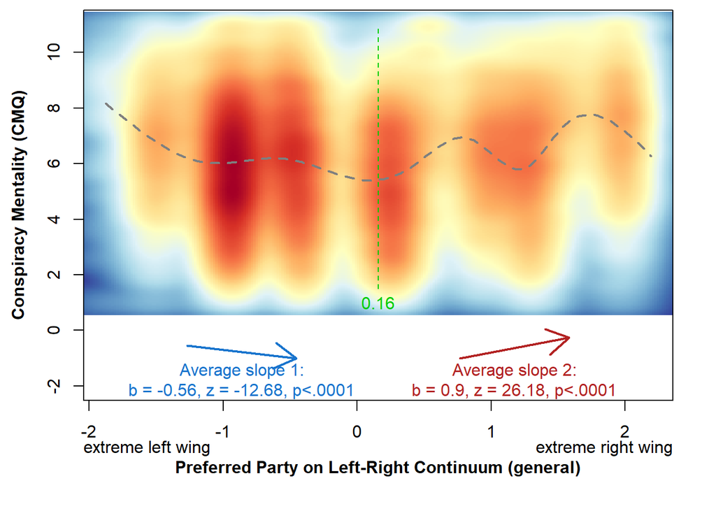

```r
a=twolines(CM5x~lrgen,data=data,x.label="Preferred Party on Left-Right Continuum (general)",y.label="Conspiracy Mentality (CMQ)",label.extremes=T,lab.extreme.low="extreme left wing",lab.extreme.high="extreme right wing")
```

Left-Right (Economic), twolines

```
## Das folgende Objekt ist maskiert durch .GlobalEnv:
##
##     lr_galtan_cor
##
## Das folgende Objekt ist maskiert durch .GlobalEnv:
##
##     lr_galtan_cor
```

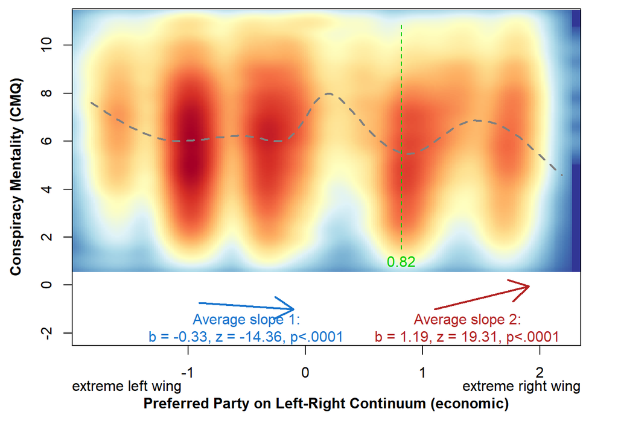

```r
a=twolines(CM5x~lrecon,data=data, x.label="Preferred Party on Left-Right Continuum (economic)",y.label="Conspiracy Mentality (CMQ)",label.extremes=T,lab.extreme.low="extreme left wing",lab.extreme.high="extreme right wing")
```

Galtan, twolines

```
## Das folgende Objekt ist maskiert durch .GlobalEnv:
##
##     lr_galtan_cor
##
## Das folgende Objekt ist maskiert durch .GlobalEnv:
##
##     lr_galtan_cor
```

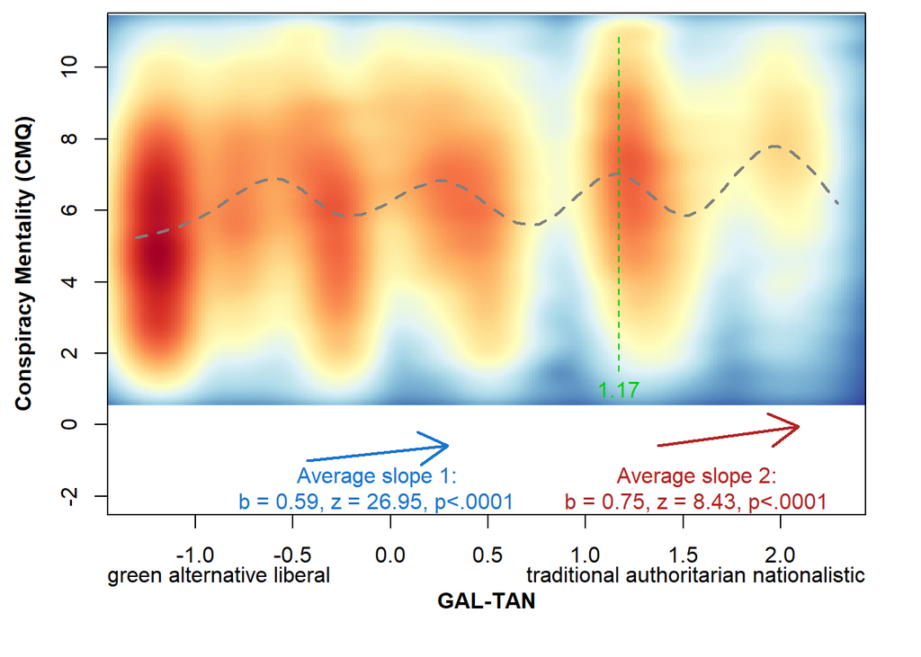

```r
a=twolines(CM5x~galtan,data=data, x.label="GAL-TAN",y.label="Conspiracy Mentality (CMQ)",label.extremes=T,lab.extreme.low="green alternative liberal",lab.extreme.high="traditional authoritarian nationalistic")
```

Adding mean for control

Left-Right (General), mixed model + mean

```r
model.1=lmer(CM5x ~ lrgen + I(lrgen^2)+ (lrgen+I(lrgen^2)|Country) + mean_lrgen, data=data, REML=FALSE, control = lmerControl(optimizer="optimx", optCtrl=list(method="bobyqa")) )
summary(model.1)
```

```
## Linear mixed model fit by maximum likelihood . t-tests use Satterthwaite's
##   method [lmerModLmerTest]
## Formula: CM5x ~ lrgen + I(lrgen^2) + (lrgen + I(lrgen^2) | Country) +
##     mean_lrgen
##    Data: data
## Control: lmerControl(optimizer = "optimx", optCtrl = list(method = "bobyqa"))
##
##      AIC      BIC   logLik deviance df.resid
## 102000.7 102089.8 -50989.3 101978.7    24288
##
## Scaled residuals:
##     Min      1Q  Median      3Q     Max
## -3.5924 -0.6983  0.0000  0.7081  3.0710
##
## Random effects:
##  Groups   Name        Variance Std.Dev. Corr
##  Country  (Intercept) 0.77023  0.8776
##           lrgen       0.03010  0.1735   -0.04
##           I(lrgen^2)  0.05054  0.2248   -0.69 -0.27
##  Residual             3.86973  1.9672
## Number of obs: 24299, groups:  Country, 21
##
## Fixed effects:
##             Estimate Std. Error       df t value Pr(>|t|)
## (Intercept)  7.61493    0.73190 23.67913  10.404 2.62e-10 ***
## lrgen        0.03779    0.04926 18.63331   0.767  0.45263
## I(lrgen^2)   0.18762    0.06017 18.73159   3.118  0.00573 **
## mean_lrgen  -0.12556    0.13946 22.45134  -0.900  0.37749
## ---
## Signif. codes:  0 '***' 0.001 '**' 0.01 '*' 0.05 '.' 0.1 ' ' 1
##
## Correlation of Fixed Effects:
##            (Intr) lrgen  I(l^2)
## lrgen       0.084
## I(lrgen^2) -0.208 -0.323
## mean_lrgen -0.964 -0.091  0.040
```

Left-Right (Economic), mixed model + mean

```r
model.2=lmer(CM5x ~ lrecon + I(lrecon^2) + (lrecon+I(lrecon^2)|Country) + mean_lrecon, data=data, REML=FALSE, control = lmerControl(optimizer="optimx", optCtrl=list(method="bobyqa")) )
summary(model.2)
```

```
## Linear mixed model fit by maximum likelihood . t-tests use Satterthwaite's
##   method [lmerModLmerTest]
## Formula: CM5x ~ lrecon + I(lrecon^2) + (lrecon + I(lrecon^2) | Country) +
##     mean_lrecon
##    Data: data
## Control: lmerControl(optimizer = "optimx", optCtrl = list(method = "bobyqa"))
##
##      AIC      BIC   logLik deviance df.resid
## 102874.8 102963.9 -51426.4 102852.8    24288
##
## Scaled residuals:
##     Min      1Q  Median      3Q     Max
## -3.5329 -0.6981  0.0009  0.6998  2.9330
##
## Random effects:
##  Groups   Name        Variance Std.Dev. Corr
##  Country  (Intercept) 0.63530  0.7971
##           lrecon      0.02966  0.1722   -0.12
##           I(lrecon^2) 0.06052  0.2460   -0.51 -0.18
##  Residual             4.01193  2.0030
## Number of obs: 24299, groups:  Country, 21
##
## Fixed effects:
##              Estimate Std. Error        df t value Pr(>|t|)
## (Intercept)  7.886467   0.843376 21.760754   9.351 4.46e-09 ***
## lrecon      -0.007984   0.049963 16.425828  -0.160    0.875
## I(lrecon^2)  0.077492   0.068506 17.034547   1.131    0.274
## mean_lrecon -0.175939   0.180464 21.211618  -0.975    0.341
## ---
## Signif. codes:  0 '***' 0.001 '**' 0.01 '*' 0.05 '.' 0.1 ' ' 1
##
## Correlation of Fixed Effects:
##             (Intr) lrecon I(l^2)
## lrecon       0.040
## I(lrecon^2) -0.113 -0.167
## mean_lrecon -0.977 -0.057  0.010
```

Galtan, mixed model + mean

```r
model.3=lmer(CM5x ~ galtan + I(galtan^2)  +(galtan+I(galtan^2)|Country) + mean_galtan, data=data, REML=FALSE, control = lmerControl(optimizer="optimx", optCtrl=list(method="bobyqa")) )
summary(model.3)
```

```
## Linear mixed model fit by maximum likelihood . t-tests use Satterthwaite's
##   method [lmerModLmerTest]
## Formula: CM5x ~ galtan + I(galtan^2) + (galtan + I(galtan^2) | Country) +
##     mean_galtan
##    Data: data
## Control: lmerControl(optimizer = "optimx", optCtrl = list(method = "bobyqa"))
##
##      AIC      BIC   logLik deviance df.resid
## 102843.9 102933.0 -51410.9 102821.9    24288
##
## Scaled residuals:
##     Min      1Q  Median      3Q     Max
## -3.5212 -0.6956  0.0051  0.7044  2.9045
##
## Random effects:
##  Groups   Name        Variance Std.Dev. Corr
##  Country  (Intercept) 0.59841  0.7736
##           galtan      0.04107  0.2027   -0.17
##           I(galtan^2) 0.02864  0.1692   -0.46 -0.56
##  Residual             4.00816  2.0020
## Number of obs: 24299, groups:  Country, 21
##
## Fixed effects:
##             Estimate Std. Error       df t value Pr(>|t|)
## (Intercept)  6.93647    0.51912 23.34753  13.362    2e-12 ***
## galtan       0.18890    0.06093 18.90708   3.100  0.00592 **
## I(galtan^2)  0.01787    0.04853 16.72458   0.368  0.71739
## mean_galtan  0.03645    0.10234 21.80395   0.356  0.72512
## ---
## Signif. codes:  0 '***' 0.001 '**' 0.01 '*' 0.05 '.' 0.1 ' ' 1
##
## Correlation of Fixed Effects:
##             (Intr) galtan I(g^2)
## galtan      -0.023
## I(galtan^2) -0.105 -0.643
## mean_galtan -0.943 -0.004 -0.041
```

## Losers

Mixed Model

```r
model.1=lmer(CM5x ~ Winner_state + (1|Country), data=data, REML=FALSE, control = lmerControl(optimizer="optimx", optCtrl=list(method="bobyqa")) )
summary(model.1)
```

```
## Linear mixed model fit by maximum likelihood . t-tests use Satterthwaite's
##   method [lmerModLmerTest]
## Formula: CM5x ~ Winner_state + (1 | Country)
##    Data: data
## Control: lmerControl(optimizer = "optimx", optCtrl = list(method = "bobyqa"))
##
##      AIC      BIC   logLik deviance df.resid
## 110514.6 110547.3 -55253.3 110506.6    26084
##
## Scaled residuals:
##     Min      1Q  Median      3Q     Max
## -3.6022 -0.6770  0.0224  0.7196  2.8447
##
## Random effects:
##  Groups   Name        Variance Std.Dev.
##  Country  (Intercept) 0.4953   0.7038
##  Residual             4.0320   2.0080
## Number of obs: 26088, groups:  Country, 24
##
## Fixed effects:
##                Estimate Std. Error         df t value Pr(>|t|)
## (Intercept)   7.363e+00  1.456e-01  2.455e+01   50.56   <2e-16 ***
## Winner_state -4.672e-01  2.701e-02  2.608e+04  -17.30   <2e-16 ***
## ---
## Signif. codes:  0 '***' 0.001 '**' 0.01 '*' 0.05 '.' 0.1 ' ' 1
##
## Correlation of Fixed Effects:
##             (Intr)
## Winner_stat -0.068
```

Loser vs. CHES: LRgen

```r
model.2=lmer(CM5x ~ lrgen + I(lrgen^2) + Winner_state + (lrgen+I(lrgen^2)|Country), data=data, REML=FALSE, control = lmerControl(optimizer="optimx", optCtrl=list(method="bobyqa")) )
summary(model.2)
```

```
## Linear mixed model fit by maximum likelihood . t-tests use Satterthwaite's
##   method [lmerModLmerTest]
## Formula: CM5x ~ lrgen + I(lrgen^2) + Winner_state + (lrgen + I(lrgen^2) |
##     Country)
##    Data: data
## Control: lmerControl(optimizer = "optimx", optCtrl = list(method = "bobyqa"))
##
##      AIC      BIC   logLik deviance df.resid
## 101717.3 101806.4 -50847.7 101695.3    24232
##
## Scaled residuals:
##     Min      1Q  Median      3Q     Max
## -3.5917 -0.7008 -0.0036  0.7013  3.1238
##
## Random effects:
##  Groups   Name        Variance Std.Dev. Corr
##  Country  (Intercept) 0.74948  0.8657
##           lrgen       0.02165  0.1471   -0.02
##           I(lrgen^2)  0.05811  0.2411   -0.60 -0.34
##  Residual             3.86217  1.9652
## Number of obs: 24243, groups:  Country, 21
##
## Fixed effects:
##                Estimate Std. Error         df t value Pr(>|t|)
## (Intercept)     7.08359    0.19368   21.93458  36.573  < 2e-16 ***
## lrgen           0.09802    0.04575   12.00784   2.143   0.0533 .
## I(lrgen^2)      0.18512    0.06415   15.26579   2.886   0.0112 *
## Winner_state   -0.29738    0.03936 4153.11565  -7.556 5.09e-14 ***
## ---
## Signif. codes:  0 '***' 0.001 '**' 0.01 '*' 0.05 '.' 0.1 ' ' 1
##
## Correlation of Fixed Effects:
##             (Intr) lrgen  I(l^2)
## lrgen        0.021
## I(lrgen^2)  -0.568 -0.371
## Winner_stat -0.072 -0.168  0.004
```

Loser vs. CHES: LRecon

```r
model.2=lmer(CM5x ~ lrecon + I(lrecon^2) + Winner_state + (lrecon + I(lrecon^2)|Country), data=data, REML=FALSE, control = lmerControl(optimizer="optimx", optCtrl=list(method="bobyqa")) )
summary(model.2)
```

```
## Linear mixed model fit by maximum likelihood . t-tests use Satterthwaite's
##   method [lmerModLmerTest]
## Formula: CM5x ~ lrecon + I(lrecon^2) + Winner_state + (lrecon + I(lrecon^2) |
##     Country)
##    Data: data
## Control: lmerControl(optimizer = "optimx", optCtrl = list(method = "bobyqa"))
##
##      AIC      BIC   logLik deviance df.resid
## 102349.2 102438.3 -51163.6 102327.2    24232
##
## Scaled residuals:
##     Min      1Q  Median      3Q     Max
## -3.5608 -0.6990  0.0035  0.6899  3.1276
##
## Random effects:
##  Groups   Name        Variance Std.Dev. Corr
##  Country  (Intercept) 0.69506  0.8337
##           lrecon      0.02169  0.1473   -0.29
##           I(lrecon^2) 0.07568  0.2751   -0.53  0.20
##  Residual             3.96439  1.9911
## Number of obs: 24243, groups:  Country, 21
##
## Fixed effects:
##                Estimate Std. Error         df t value Pr(>|t|)
## (Intercept)     7.30026    0.18719   22.17956  38.999   <2e-16 ***
## lrecon          0.04345    0.04545   16.28013   0.956    0.353
## I(lrecon^2)     0.10020    0.07539   14.79134   1.329    0.204
## Winner_state   -0.64308    0.03712 6232.15149 -17.326   <2e-16 ***
## ---
## Signif. codes:  0 '***' 0.001 '**' 0.01 '*' 0.05 '.' 0.1 ' ' 1
##
## Correlation of Fixed Effects:
##             (Intr) lrecon I(l^2)
## lrecon      -0.180
## I(lrecon^2) -0.498  0.071
## Winner_stat -0.071 -0.096 -0.002
```

Loser vs. CHES: Galtan

```r
model.2=lmer(CM5x ~ galtan + I(galtan^2)  + Winner_state + (galtan + I(galtan^2)|Country), data=data, REML=FALSE, control = lmerControl(optimizer="optimx", optCtrl=list(method="bobyqa")) )
summary(model.2)
```

```
## Linear mixed model fit by maximum likelihood . t-tests use Satterthwaite's
##   method [lmerModLmerTest]
## Formula: CM5x ~ galtan + I(galtan^2) + Winner_state + (galtan + I(galtan^2) |
##     Country)
##    Data: data
## Control: lmerControl(optimizer = "optimx", optCtrl = list(method = "bobyqa"))
##
##      AIC      BIC   logLik deviance df.resid
## 102061.3 102150.3 -51019.6 102039.3    24232
##
## Scaled residuals:
##     Min      1Q  Median      3Q     Max
## -3.5255 -0.7087 -0.0014  0.7035  3.1833
##
## Random effects:
##  Groups   Name        Variance Std.Dev. Corr
##  Country  (Intercept) 0.63931  0.7996
##           galtan      0.09036  0.3006    0.10
##           I(galtan^2) 0.06222  0.2494   -0.40 -0.92
##  Residual             3.91856  1.9795
## Number of obs: 24243, groups:  Country, 21
##
## Fixed effects:
##                Estimate Std. Error         df t value Pr(>|t|)
## (Intercept)     7.35205    0.17913   21.38738  41.042  < 2e-16 ***
## galtan          0.34568    0.08032   20.95735   4.304 0.000315 ***
## I(galtan^2)    -0.02266    0.06388   20.56553  -0.355 0.726440
## Winner_state   -0.73480    0.03092 5819.87208 -23.767  < 2e-16 ***
## ---
## Signif. codes:  0 '***' 0.001 '**' 0.01 '*' 0.05 '.' 0.1 ' ' 1
##
## Correlation of Fixed Effects:
##             (Intr) galtan I(g^2)
## galtan       0.124
## I(galtan^2) -0.402 -0.890
## Winner_stat -0.053 -0.059  0.004
```

Loser vs ZPO

```r
model.cmpo =lmer(CM5x~ZPO+I(ZPO^2)+(ZPO+I(ZPO^2)+Winner_state|Country)+ Winner_state , data=data, REML=FALSE, control = lmerControl(optimizer="optimx", optCtrl=list(method="bobyqa")) )
summary(model.cmpo)
```

```
## Linear mixed model fit by maximum likelihood . t-tests use Satterthwaite's
##   method [lmerModLmerTest]
## Formula: CM5x ~ ZPO + I(ZPO^2) + (ZPO + I(ZPO^2) + Winner_state | Country) +
##     Winner_state
##    Data: data
## Control: lmerControl(optimizer = "optimx", optCtrl = list(method = "bobyqa"))
##
##      AIC      BIC   logLik deviance df.resid
## 108847.6 108970.0 -54408.8 108817.6    25871
##
## Scaled residuals:
##     Min      1Q  Median      3Q     Max
## -3.7170 -0.6989  0.0098  0.7070  3.2322
##
## Random effects:
##  Groups   Name         Variance  Std.Dev. Corr
##  Country  (Intercept)  0.4600426 0.67826
##           ZPO          0.0226281 0.15043  -0.67
##           I(ZPO^2)     0.0008805 0.02967  -0.42 -0.31
##           Winner_state 0.1997318 0.44691   0.06 -0.20 -0.28
##  Residual              3.8947892 1.97352
## Number of obs: 25886, groups:  Country, 24
##
## Fixed effects:
##              Estimate Std. Error       df t value Pr(>|t|)
## (Intercept)   7.19714    0.14211 24.88530  50.644  < 2e-16 ***
## ZPO           0.11281    0.03677 21.13971   3.068  0.00580 **
## I(ZPO^2)      0.08624    0.01200 10.09831   7.187 2.82e-05 ***
## Winner_state -0.34206    0.10432 22.36154  -3.279  0.00338 **
## ---
## Signif. codes:  0 '***' 0.001 '**' 0.01 '*' 0.05 '.' 0.1 ' ' 1
##
## Correlation of Fixed Effects:
##             (Intr) ZPO    I(ZPO^
## ZPO         -0.526
## I(ZPO^2)    -0.283 -0.270
## Winner_stat -0.011 -0.205 -0.133
```

# Controlling for age, gender, education, and party in power

## CM and PO

Mixed Model

```r
model.cmpo =lmer(CM4x~ZPO+I(ZPO^2)+(ZPO+I(ZPO^2)|Country)+Sex+Age+Edu_low+Edu_high+Winner_state, data=data, REML=FALSE, control = lmerControl(optimizer="optimx", optCtrl=list(method="bobyqa")) )
summary(model.cmpo)
```

```
## Linear mixed model fit by maximum likelihood . t-tests use Satterthwaite's
##   method [lmerModLmerTest]
## Formula: CM4x ~ ZPO + I(ZPO^2) + (ZPO + I(ZPO^2) | Country) + Sex + Age +
##     Edu_low + Edu_high + Winner_state
##    Data: data
## Control: lmerControl(optimizer = "optimx", optCtrl = list(method = "bobyqa"))
##
##      AIC      BIC   logLik deviance df.resid
## 104223.8 104353.4 -52095.9 104191.8    24284
##
## Scaled residuals:
##     Min      1Q  Median      3Q     Max
## -3.6624 -0.7133 -0.0133  0.7076  3.0965
##
## Random effects:
##  Groups   Name        Variance Std.Dev. Corr
##  Country  (Intercept) 0.452963 0.67303
##           ZPO         0.028241 0.16805  -0.39
##           I(ZPO^2)    0.004622 0.06798  -0.21 -0.55
##  Residual             4.239414 2.05898
## Number of obs: 24300, groups:  Country, 23
##
## Fixed effects:
##                Estimate Std. Error         df t value Pr(>|t|)
## (Intercept)   7.196e+00  1.506e-01  2.878e+01  47.797  < 2e-16 ***
## ZPO           1.389e-01  4.122e-02  2.076e+01   3.370 0.002930 **
## I(ZPO^2)      9.635e-02  2.052e-02  1.447e+01   4.695 0.000315 ***
## Sexmale       4.853e-02  2.852e-02  2.389e+04   1.702 0.088839 .
## Sexother     -4.511e-01  2.591e-01  2.426e+04  -1.741 0.081658 .
## Age           1.413e-03  9.177e-04  2.389e+04   1.540 0.123555
## Edu_low       1.841e-01  5.725e-02  2.379e+04   3.216 0.001304 **
## Edu_high     -6.944e-01  3.163e-02  2.414e+04 -21.956  < 2e-16 ***
## Winner_state -5.870e-01  3.211e-02  1.356e+04 -18.279  < 2e-16 ***
## ---
## Signif. codes:  0 '***' 0.001 '**' 0.01 '*' 0.05 '.' 0.1 ' ' 1
##
## Correlation of Fixed Effects:
##             (Intr) ZPO    I(ZPO^ Sexmal Sexthr Age    Edu_lw Ed_hgh
## ZPO         -0.299
## I(ZPO^2)    -0.214 -0.395
## Sexmale     -0.105 -0.008 -0.005
## Sexother    -0.012  0.011 -0.013  0.046
## Age         -0.254 -0.007 -0.005  0.057  0.021
## Edu_low     -0.044 -0.013 -0.014 -0.011  0.004 -0.119
## Edu_high    -0.117  0.016  0.014  0.005  0.005  0.013  0.349
## Winner_stat -0.075 -0.094 -0.014  0.026 -0.002  0.023  0.012 -0.055
```

Twolines Plot

(Twolines function currently doesn’t support covariates)

```r
# a=twolines(CM4x~ZPO,data=data, x.label="Political Orientation",y.label="Conspiracy Mentality (CMQ)",label.extremes=T,lab.extreme.low="extreme left wing",lab.extreme.high="extreme right wing")
```

by country effects in the mixed model

```r
coef(model.cmpo)
```

```
## $Country
##                 (Intercept)           ZPO    I(ZPO^2)    Sexmale   Sexother
## Belgium, FR        7.363852  0.0395141850 0.134886342 0.04853194 -0.4511202
## Bosnia             7.217885 -0.0764603708 0.177977883 0.04853194 -0.4511202
## Brazil             6.991388 -0.0767539228 0.192629784 0.04853194 -0.4511202
## Croatia            7.311517  0.1699090748 0.106706927 0.04853194 -0.4511202
## Czech Republic     6.454999  0.2059997435 0.096478931 0.04853194 -0.4511202
## France             6.329777  0.3619698532 0.043859051 0.04853194 -0.4511202
## Greece             6.821620  0.0782452519 0.131323823 0.04853194 -0.4511202
## Hungary            7.702818  0.1454390947 0.125868629 0.04853194 -0.4511202
## Iceland            6.770738 -0.0436530332 0.150283217 0.04853194 -0.4511202
## Israel             8.041035  0.1111848036 0.042758743 0.04853194 -0.4511202
## Italy              7.049425  0.2138993148 0.051786564 0.04853194 -0.4511202
## Macedonia          7.356490  0.1417242149 0.131915305 0.04853194 -0.4511202
## Netherlands        5.716819  0.2237388256 0.136195635 0.04853194 -0.4511202
## Norway             6.217089  0.2897347769 0.130003434 0.04853194 -0.4511202
## Poland             6.309572  0.3582274027 0.062180477 0.04853194 -0.4511202
## Portugal           8.154063  0.0706143745 0.076516177 0.04853194 -0.4511202
## Romania            7.416532  0.3302533416 0.006124554 0.04853194 -0.4511202
## Serbia             8.064515 -0.0677790767 0.086946359 0.04853194 -0.4511202
## Spain              7.837383  0.0008985688 0.040765648 0.04853194 -0.4511202
## Switzerland, FR    7.208451  0.2427284326 0.071407720 0.04853194 -0.4511202
## Switzerland, GE    7.650486  0.3385801793 0.006471018 0.04853194 -0.4511202
## Turkey             8.213511 -0.0810592043 0.140918731 0.04853194 -0.4511202
## UK                 7.317235  0.2178541224 0.072026851 0.04853194 -0.4511202
##                         Age   Edu_low  Edu_high Winner_state
## Belgium, FR     0.001413397 0.1840883 -0.694383   -0.5869912
## Bosnia          0.001413397 0.1840883 -0.694383   -0.5869912
## Brazil          0.001413397 0.1840883 -0.694383   -0.5869912
## Croatia         0.001413397 0.1840883 -0.694383   -0.5869912
## Czech Republic  0.001413397 0.1840883 -0.694383   -0.5869912
## France          0.001413397 0.1840883 -0.694383   -0.5869912
## Greece          0.001413397 0.1840883 -0.694383   -0.5869912
## Hungary         0.001413397 0.1840883 -0.694383   -0.5869912
## Iceland         0.001413397 0.1840883 -0.694383   -0.5869912
## Israel          0.001413397 0.1840883 -0.694383   -0.5869912
## Italy           0.001413397 0.1840883 -0.694383   -0.5869912
## Macedonia       0.001413397 0.1840883 -0.694383   -0.5869912
## Netherlands     0.001413397 0.1840883 -0.694383   -0.5869912
## Norway          0.001413397 0.1840883 -0.694383   -0.5869912
## Poland          0.001413397 0.1840883 -0.694383   -0.5869912
## Portugal        0.001413397 0.1840883 -0.694383   -0.5869912
## Romania         0.001413397 0.1840883 -0.694383   -0.5869912
## Serbia          0.001413397 0.1840883 -0.694383   -0.5869912
## Spain           0.001413397 0.1840883 -0.694383   -0.5869912
## Switzerland, FR 0.001413397 0.1840883 -0.694383   -0.5869912
## Switzerland, GE 0.001413397 0.1840883 -0.694383   -0.5869912
## Turkey          0.001413397 0.1840883 -0.694383   -0.5869912
## UK              0.001413397 0.1840883 -0.694383   -0.5869912
##
## attr(,"class")
## [1] "coef.mer"
```

Linear Model for each country

```r
by.country = matrix(NA,0,7)
for (i in unique(data$Country)) {
  if (i=="Germany") { # Since Germany is missing education
    test = lm(CM4x~ZPO+I(ZPO^2)+Sex+Age+Winner_state,data[data$Country == i,])
  }
  if (i!="Germany") {
    test = lm(CM4x~ZPO+I(ZPO^2)+Sex+Age+Edu_low+Edu_high+Winner_state,data[data$Country == i,])
  }
  a = coef(test)
  b = summary(test)$coefficients[,4] #p-values
  b2 = summary(test)$coefficients[,2] #SE
  d = c(as.numeric(a)[2:3],as.numeric(b2)[2:3],as.numeric(b)[2:3])
  d = c(i,d)
  by.country = rbind(by.country,d)
}
by.country = as.data.frame(by.country)
names(by.country) = c("Country","ZPO","ZPO2","SE_ZPO","SE_ZPO2","p_ZPO","p_ZPO2")
by.country[,2:7] = apply(by.country[,2:7],2,as.numeric)

by.country$CI95_low_ZPO = by.country$ZPO-qnorm(.975)*by.country$SE_ZPO
by.country$CI95_high_ZPO = by.country$ZPO+qnorm(.975)*by.country$SE_ZPO
by.country$sig_ZPO = by.country$p_ZPO<.05
by.country$sigbonf_ZPO = by.country$p_ZPO<.05/nrow(by.country)

by.country$CI95_low_ZPO2 = by.country$ZPO2-qnorm(.975)*by.country$SE_ZPO2
by.country$CI95_high_ZPO2 = by.country$ZPO2+qnorm(.975)*by.country$SE_ZPO2
by.country$sig_ZPO2 = by.country$p_ZPO2 <.05
by.country$sigbonf_ZPO2 = by.country$p_ZPO2 <.05/nrow(by.country)

export = by.country[,c(1,2,8,9,10,11,3,12,13,14,15)]
export
```

|  | Country | ZPO | CI95_low_ZPO | CI95_high_ZPO | sig_ZPO | sigbonf_ZPO | ZPO2 | CI95_low_ZPO2 | CI95_high_ZPO2 | sig_ZPO2 | sigbonf_ZPO2 |
| --- | --- | --- | --- | --- | --- | --- | --- | --- | --- | --- | --- |
| d | Iceland | -0.09835025 | -0.35968776 | 0.162987249 | FALSE | FALSE | 0.09121901 | -0.070436895 | 0.25287492 | FALSE | FALSE |
| d.1 | Belgium, FR | 0.02526464 | -0.21972836 | 0.270257635 | FALSE | FALSE | 0.21120229 | 0.050949334 | 0.37145524 | TRUE | FALSE |
| d.2 | Bosnia | -0.25145464 | -0.50930215 | 0.006392874 | FALSE | FALSE | 0.20339989 | 0.022498851 | 0.38430092 | TRUE | FALSE |
| d.3 | Brazil | 0.05425374 | -0.09895307 | 0.207460551 | FALSE | FALSE | 0.20744322 | 0.104394188 | 0.31049225 | TRUE | TRUE |
| d.4 | Switzerland, FR | 0.31082816 | 0.08108696 | 0.540569354 | TRUE | FALSE | 0.04948572 | -0.110724231 | 0.20969568 | FALSE | FALSE |
| d.5 | Switzerland, GE | 0.55483086 | 0.25666632 | 0.852995408 | TRUE | TRUE | -0.19748987 | -0.424832207 | 0.02985246 | FALSE | FALSE |
| d.6 | Croatia | 0.13673854 | -0.74043496 | 1.013912045 | FALSE | FALSE | 0.22387047 | -0.179006278 | 0.62674722 | FALSE | FALSE |
| d.7 | Czech Republic | 0.16055779 | -0.07321569 | 0.394331274 | FALSE | FALSE | 0.04920987 | -0.120134606 | 0.21855435 | FALSE | FALSE |
| d.8 | France | 0.41088894 | 0.22503833 | 0.596739555 | TRUE | TRUE | 0.02113615 | -0.101021233 | 0.14329352 | FALSE | FALSE |
| d.9 | Greece | -0.05602138 | -0.32069519 | 0.208652431 | FALSE | FALSE | 0.14817502 | -0.052424723 | 0.34877476 | FALSE | FALSE |

[output cut: 14 more lines]

```r
#print(xtable(export,digits=4),type="html",file="./table.html")
```

Exploratory: Interaction of ZPO and Countryvars in predicting CM

```r
countrylevelvars = c("lrgengov", "lrecongov","galtangov")

for (i in 1:length(countrylevelvars)) {
  fmla <- as.formula(paste("CM4x~ZPO+I(ZPO^2)+(ZPO+I(ZPO^2)|Country) +Sex+Age+Edu_low+Edu_high+Winner_state+",countrylevelvars[i],"+ ZPO *",countrylevelvars[i],"+ I(ZPO^2) *",countrylevelvars[i]))
  model.1 =lmer(fmla, data=data, REML=FALSE, control = lmerControl(optimizer="optimx", optCtrl=list(method="bobyqa")))
  summary(model.1) %>% print()
}
```

```
## boundary (singular) fit: see ?isSingular
```

```
## Linear mixed model fit by maximum likelihood . t-tests use Satterthwaite's
##   method [lmerModLmerTest]
## Formula: fmla
##    Data: data
## Control: lmerControl(optimizer = "optimx", optCtrl = list(method = "bobyqa"))
##
##      AIC      BIC   logLik deviance df.resid
##  97594.6  97747.2 -48778.3  97556.6    22708
##
## Scaled residuals:
##     Min      1Q  Median      3Q     Max
## -3.6624 -0.7171 -0.0183  0.7051  3.1085
##
## Random effects:
##  Groups   Name        Variance  Std.Dev. Corr
##  Country  (Intercept) 0.4920364 0.70145
##           ZPO         0.0196735 0.14026  -0.66
##           I(ZPO^2)    0.0008143 0.02854  -0.22 -0.58
##  Residual             4.2654934 2.06531
## Number of obs: 22727, groups:  Country, 19
##
## Fixed effects:
##                     Estimate Std. Error         df t value Pr(>|t|)
## (Intercept)        7.268e+00  6.549e-01  2.002e+01  11.098 5.28e-10 ***
## ZPO                9.622e-02  1.613e-01  1.869e+01   0.597  0.55787
## I(ZPO^2)          -8.427e-02  7.543e-02  4.962e+01  -1.117  0.26931
## Sexmale            8.854e-02  2.966e-02  1.976e+04   2.985  0.00284 **
## Sexother          -3.362e-01  2.799e-01  2.270e+04  -1.201  0.22962
## Age                1.162e-03  9.415e-04  2.266e+04   1.234  0.21724
## Edu_low            1.594e-01  5.999e-02  2.251e+04   2.657  0.00788 **
## Edu_high          -7.219e-01  3.282e-02  2.262e+04 -21.997  < 2e-16 ***
## Winner_state      -6.311e-01  3.345e-02  1.939e+04 -18.868  < 2e-16 ***
## lrgengov          -1.039e-02  1.012e-01  1.974e+01  -0.103  0.91926
## ZPO:lrgengov       9.427e-03  2.473e-02  1.772e+01   0.381  0.70760
## I(ZPO^2):lrgengov  2.778e-02  1.149e-02  4.772e+01   2.418  0.01950 *
## ---
## Signif. codes:  0 '***' 0.001 '**' 0.01 '*' 0.05 '.' 0.1 ' ' 1
##
## Correlation of Fixed Effects:
##             (Intr) ZPO    I(ZPO^2) Sexmal Sexthr Age    Edu_lw Ed_hgh Wnnr_s
```

[output cut: 74 more lines]

```
## lrecongov   -0.945  0.491  0.149    0.001  0.000 -0.009 -0.004 -0.012  0.011
## ZPO:lrecngv  0.505 -0.949  0.146    0.014  0.003 -0.006  0.011  0.020 -0.062
## I(ZPO^2):lr  0.160  0.155 -0.958    0.000  0.000  0.014 -0.004  0.002  0.006
##             lrcngv ZPO:lr
## ZPO
## I(ZPO^2)
## Sexmale
## Sexother
## Age
## Edu_low
## Edu_high
## Winner_stat
## lrecongov
## ZPO:lrecngv -0.535
## I(ZPO^2):lr -0.157 -0.158
```

```
## boundary (singular) fit: see ?isSingular
```

```
## Linear mixed model fit by maximum likelihood . t-tests use Satterthwaite's
##   method [lmerModLmerTest]
## Formula: fmla
##    Data: data
## Control: lmerControl(optimizer = "optimx", optCtrl = list(method = "bobyqa"))
##
##      AIC      BIC   logLik deviance df.resid
##  97595.7  97748.3 -48778.9  97557.7    22708
##
## Scaled residuals:
##     Min      1Q  Median      3Q     Max
## -3.6641 -0.7172 -0.0185  0.7050  3.1067
##
## Random effects:
##  Groups   Name        Variance  Std.Dev. Corr
##  Country  (Intercept) 0.4592927 0.67771
##           ZPO         0.0187466 0.13692  -0.66
##           I(ZPO^2)    0.0007589 0.02755  -0.77  0.03
##  Residual             4.2662068 2.06548
## Number of obs: 22727, groups:  Country, 19
##
## Fixed effects:
##                      Estimate Std. Error         df t value Pr(>|t|)
## (Intercept)         6.743e+00  3.991e-01  1.989e+01  16.894 2.92e-13 ***
## ZPO                 2.166e-01  9.776e-02  1.661e+01   2.215  0.04101 *
## I(ZPO^2)            2.008e-02  3.567e-02  2.686e+01   0.563  0.57819
## Sexmale             8.837e-02  2.968e-02  2.035e+04   2.978  0.00291 **
## Sexother           -3.353e-01  2.799e-01  2.269e+04  -1.198  0.23086
## Age                 1.186e-03  9.418e-04  2.256e+04   1.259  0.20803
## Edu_low             1.583e-01  5.997e-02  2.235e+04   2.639  0.00832 **
## Edu_high           -7.221e-01  3.281e-02  2.258e+04 -22.006  < 2e-16 ***
## Winner_state       -6.280e-01  3.334e-02  1.722e+04 -18.839  < 2e-16 ***
## galtangov           7.566e-02  6.109e-02  1.942e+01   1.239  0.23029
## ZPO:galtangov      -9.946e-03  1.510e-02  1.685e+01  -0.659  0.51904
## I(ZPO^2):galtangov  1.276e-02  6.173e-03  5.006e+01   2.066  0.04398 *
## ---
## Signif. codes:  0 '***' 0.001 '**' 0.01 '*' 0.05 '.' 0.1 ' ' 1
##
## Correlation of Fixed Effects:
##             (Intr) ZPO    I(ZPO^2) Sexmal Sexthr Age    Edu_lw Ed_hgh Wnnr_s
```

[output cut: 10 more lines]

```
## I(ZPO^2):gl  0.361  0.146 -0.927   -0.007  0.006 -0.038 -0.002  0.000 -0.083
##             gltngv ZPO:gl
## ZPO
## I(ZPO^2)
## Sexmale
## Sexother
## Age
## Edu_low
## Edu_high
## Winner_stat
## galtangov
## ZPO:galtngv -0.507
## I(ZPO^2):gl -0.401 -0.153
## optimizer (optimx) convergence code: 0 (OK)
## boundary (singular) fit: see ?isSingular
```

Correlations of CountryVars and Slopes

```r
sl = coef(model.cmpo)$Country
cl = aggregate(data[countrylevelvars],by=list(data$Country),mean)
cl = cl[cl[,1]!="Germany",] # Germany is lacking Education
df = cbind(sl,cl[,-1])
df = df[,-1]
res<-rcorr(as.matrix(df[,])) # using Hmisc
res = lapply(res,function(x) x[3:length(df),1:2])
res = cbind(res$r,res$P)
res =as.data.frame(res)
names(res) = c("ZPO","ZPO2","pZPO","pZPO2")
res$sigZPO = res$pZPO<.05
res$sigZPO2 = res$pZPO2<.05
res
```

|  | ZPO | ZPO2 | pZPO | pZPO2 | sigZPO | sigZPO2 |
| --- | --- | --- | --- | --- | --- | --- |
| Sexmale | 1.066768e-08 | 0.000000e+00 | 1.0000000 | 1.0000000 | FALSE | FALSE |
| Sexother | -2.177532e-08 | -3.149754e-08 | 0.9999999 | 0.9999999 | FALSE | FALSE |
| Age | 1.742025e-08 | 0.000000e+00 | 0.9999999 | 1.0000000 | FALSE | FALSE |
| Edu_low | 1.508638e-08 | 1.091107e-08 | 0.9999999 | 1.0000000 | FALSE | FALSE |
| Edu_high | -2.274358e-08 | -2.631849e-08 | 0.9999999 | 0.9999999 | FALSE | FALSE |
| Winner_state | -1.777947e-08 | -1.028705e-08 | 0.9999999 | 1.0000000 | FALSE | FALSE |
| lrgengov | -3.260184e-02 | 3.090207e-01 | 0.8945928 | 0.1979793 | FALSE | FALSE |
| lrecongov | 2.692970e-02 | -5.472982e-02 | 0.9128583 | 0.8238997 | FALSE | FALSE |
| galtangov | -2.740061e-01 | 2.441804e-01 | 0.2563017 | 0.3137154 | FALSE | FALSE |

Between countries

```r
 model.1=lmer(CM4x~ZPO+I(ZPO^2)+ZmeanPO+I(ZmeanPO^2)+(ZPO+I(ZPO^2)|Country)+Sex+Age+Edu_low+Edu_high+Winner_state, data=data, REML=FALSE, control = lmerControl(optimizer="optimx", optCtrl=list(method="bobyqa")) )
 summary(model.1)
```

```
## Linear mixed model fit by maximum likelihood . t-tests use Satterthwaite's
##   method [lmerModLmerTest]
## Formula: CM4x ~ ZPO + I(ZPO^2) + ZmeanPO + I(ZmeanPO^2) + (ZPO + I(ZPO^2) |
##     Country) + Sex + Age + Edu_low + Edu_high + Winner_state
##    Data: data
## Control: lmerControl(optimizer = "optimx", optCtrl = list(method = "bobyqa"))
##
##      AIC      BIC   logLik deviance df.resid
## 104227.5 104373.3 -52095.8 104191.5    24282
##
## Scaled residuals:
##     Min      1Q  Median      3Q     Max
## -3.6633 -0.7133 -0.0137  0.7077  3.0963
##
## Random effects:
##  Groups   Name        Variance Std.Dev. Corr
##  Country  (Intercept) 0.453662 0.6735
##           ZPO         0.027996 0.1673   -0.42
##           I(ZPO^2)    0.004652 0.0682   -0.18 -0.54
##  Residual             4.239421 2.0590
## Number of obs: 24300, groups:  Country, 23
##
## Fixed effects:
##                Estimate Std. Error         df t value Pr(>|t|)
## (Intercept)   7.157e+00  1.773e-01  2.996e+01  40.358  < 2e-16 ***
## ZPO           1.384e-01  4.108e-02  2.073e+01   3.369 0.002944 **
## I(ZPO^2)      9.648e-02  2.061e-02  1.482e+01   4.682 0.000304 ***
## ZmeanPO      -4.548e-02  1.065e-01  2.321e+01  -0.427 0.673272
## I(ZmeanPO^2)  2.273e-02  4.634e-02  2.448e+01   0.491 0.628069
## Sexmale       4.877e-02  2.852e-02  2.391e+04   1.710 0.087271 .
## Sexother     -4.507e-01  2.591e-01  2.426e+04  -1.740 0.081945 .
## Age           1.418e-03  9.178e-04  2.393e+04   1.545 0.122429
## Edu_low       1.850e-01  5.727e-02  2.395e+04   3.231 0.001235 **
## Edu_high     -6.944e-01  3.163e-02  2.415e+04 -21.957  < 2e-16 ***
## Winner_state -5.867e-01  3.211e-02  1.349e+04 -18.273  < 2e-16 ***
## ---
## Signif. codes:  0 '***' 0.001 '**' 0.01 '*' 0.05 '.' 0.1 ' ' 1
##
## Correlation of Fixed Effects:
##             (Intr) ZPO    I(ZPO^2) ZmenPO I(ZmPO^2) Sexmal Sexthr Age    Edu_lw
## ZPO         -0.282
## I(ZPO^2)    -0.180 -0.391
## ZmeanPO      0.179  0.013  0.040
## I(ZmenPO^2) -0.499  0.006  0.011   -0.626
## Sexmale     -0.092 -0.008 -0.005   -0.015  0.010
## Sexother    -0.011  0.011 -0.013   -0.001  0.001     0.046
## Age         -0.221 -0.007 -0.006   -0.011  0.012     0.057  0.021
## Edu_low     -0.051 -0.013 -0.014   -0.022  0.029    -0.011  0.004 -0.119
## Edu_high    -0.099  0.016  0.014    0.011 -0.004     0.005  0.005  0.013  0.349
## Winner_stat -0.066 -0.095 -0.015   -0.018  0.010     0.026 -0.002  0.023  0.013
##             Ed_hgh
## ZPO
## I(ZPO^2)
## ZmeanPO
## I(ZmenPO^2)
## Sexmale
## Sexother
## Age
## Edu_low
## Edu_high
## Winner_stat -0.055
```

+interactions

```r
model.2=lmer(CM4x~ZPO+I(ZPO^2)+ZmeanPO+I(ZmeanPO^2)+ZPO:ZmeanPO+I(ZPO^2):ZmeanPO+(ZPO+I(ZPO^2)|Country)+Sex+Age+Edu_low+Edu_high+Winner_state, data=data, REML=FALSE, control = lmerControl(optimizer="optimx", optCtrl=list(method="bobyqa")) )
summary(model.2)
```

```
## Linear mixed model fit by maximum likelihood . t-tests use Satterthwaite's
##   method [lmerModLmerTest]
## Formula: CM4x ~ ZPO + I(ZPO^2) + ZmeanPO + I(ZmeanPO^2) + ZPO:ZmeanPO +
##     I(ZPO^2):ZmeanPO + (ZPO + I(ZPO^2) | Country) + Sex + Age +
##     Edu_low + Edu_high + Winner_state
##    Data: data
## Control: lmerControl(optimizer = "optimx", optCtrl = list(method = "bobyqa"))
##
##      AIC      BIC   logLik deviance df.resid
## 104229.7 104391.7 -52094.9 104189.7    24280
##
## Scaled residuals:
##     Min      1Q  Median      3Q     Max
## -3.6649 -0.7135 -0.0131  0.7076  3.0962
##
## Random effects:
##  Groups   Name        Variance Std.Dev. Corr
##  Country  (Intercept) 0.448957 0.67004
##           ZPO         0.027076 0.16455  -0.44
##           I(ZPO^2)    0.004387 0.06623  -0.15 -0.53
##  Residual             4.239238 2.05894
## Number of obs: 24300, groups:  Country, 23
##
## Fixed effects:
##                    Estimate Std. Error         df t value Pr(>|t|)
## (Intercept)       7.154e+00  1.769e-01  2.993e+01  40.440  < 2e-16 ***
## ZPO               1.298e-01  4.190e-02  2.083e+01   3.099 0.005476 **
## I(ZPO^2)          1.017e-01  2.072e-02  1.558e+01   4.906 0.000171 ***
## ZmeanPO          -1.221e-02  1.191e-01  2.631e+01  -0.103 0.919088
## I(ZmeanPO^2)      1.969e-02  4.670e-02  2.464e+01   0.422 0.676973
## Sexmale           4.855e-02  2.852e-02  2.396e+04   1.702 0.088726 .
## Sexother         -4.525e-01  2.591e-01  2.426e+04  -1.747 0.080704 .
## Age               1.419e-03  9.178e-04  2.394e+04   1.546 0.122054
## Edu_low           1.862e-01  5.728e-02  2.397e+04   3.251 0.001152 **
## Edu_high         -6.938e-01  3.163e-02  2.415e+04 -21.937  < 2e-16 ***
## Winner_state     -5.858e-01  3.212e-02  1.400e+04 -18.235  < 2e-16 ***
## ZPO:ZmeanPO       1.077e-02  2.721e-02  2.245e+01   0.396 0.696148
## I(ZPO^2):ZmeanPO -1.958e-02  1.429e-02  2.320e+01  -1.370 0.183844
## ---
## Signif. codes:  0 '***' 0.001 '**' 0.01 '*' 0.05 '.' 0.1 ' ' 1
```

```
##
## Correlation matrix not shown by default, as p = 13 > 12.
## Use print(x, correlation=TRUE)  or
##     vcov(x)        if you need it
```

```r
anova(model.1,model.2)
```

|  | npar | AIC | BIC | logLik | deviance | Chisq | Df | Pr(>Chisq) |
| --- | --- | --- | --- | --- | --- | --- | --- | --- |
| model.1 | 18 | 104227.5 | 104373.3 | -52095.77 | 104191.5 | NA | NA | NA |
| model.2 | 20 | 104229.7 | 104391.7 | -52094.85 | 104189.7 | 1.844898 | 2 | 0.3975443 |

## CHES

Scale Variables across whole data

```r
data$lrgen = scale(data$lrgen)
data$lrecon = scale(data$lrecon)
data$galtan = scale(data$galtan)
```

Left-Right (General), mixed model

```r
model.1=lmer(CM4x ~ lrgen + I(lrgen^2)+ (lrgen+I(lrgen^2)|Country)+Sex+Age+Edu_low+Edu_high+Winner_state, data=data, REML=FALSE, control = lmerControl(optimizer="optimx", optCtrl=list(method="bobyqa")) )
summary(model.1)
```

```
## Linear mixed model fit by maximum likelihood . t-tests use Satterthwaite's
##   method [lmerModLmerTest]
## Formula: CM4x ~ lrgen + I(lrgen^2) + (lrgen + I(lrgen^2) | Country) +
##     Sex + Age + Edu_low + Edu_high + Winner_state
##    Data: data
## Control: lmerControl(optimizer = "optimx", optCtrl = list(method = "bobyqa"))
##
##      AIC      BIC   logLik deviance df.resid
##  96881.6  97010.1 -48424.8  96849.6    22647
##
## Scaled residuals:
##     Min      1Q  Median      3Q     Max
## -3.3649 -0.7116 -0.0163  0.7040  3.2101
##
## Random effects:
##  Groups   Name        Variance Std.Dev. Corr
##  Country  (Intercept) 0.69683  0.8348
##           lrgen       0.02690  0.1640    0.07
##           I(lrgen^2)  0.05883  0.2426   -0.58 -0.58
##  Residual             4.17906  2.0443
## Number of obs: 22663, groups:  Country, 20
##
## Fixed effects:
##                Estimate Std. Error         df t value Pr(>|t|)
## (Intercept)   6.963e+00  1.980e-01  2.363e+01  35.168  < 2e-16 ***
## lrgen         1.134e-01  5.165e-02  9.729e+00   2.196   0.0535 .
## I(lrgen^2)    1.551e-01  6.774e-02  1.277e+01   2.289   0.0398 *
## Sexmale       9.540e-02  2.945e-02  2.246e+04   3.239   0.0012 **
## Sexother     -3.703e-01  2.793e-01  2.261e+04  -1.326   0.1850
## Age           1.712e-03  9.344e-04  2.261e+04   1.832   0.0669 .
## Edu_low       1.525e-01  5.970e-02  2.255e+04   2.554   0.0107 *
## Edu_high     -6.538e-01  3.271e-02  2.260e+04 -19.992  < 2e-16 ***
## Winner_state -2.693e-01  4.211e-02  2.409e+03  -6.396 1.91e-10 ***
## ---
## Signif. codes:  0 '***' 0.001 '**' 0.01 '*' 0.05 '.' 0.1 ' ' 1
##
## Correlation of Fixed Effects:
##             (Intr) lrgen  I(l^2) Sexmal Sexthr Age    Edu_lw Ed_hgh
## lrgen        0.092
## I(lrgen^2)  -0.529 -0.541
## Sexmale     -0.083 -0.004 -0.006
## Sexother    -0.011  0.007  0.000  0.041
## Age         -0.206 -0.005  0.007  0.068  0.023
## Edu_low     -0.036 -0.004 -0.003 -0.007  0.001 -0.110
## Edu_high    -0.101  0.011  0.007  0.010  0.001  0.031  0.345
## Winner_stat -0.074 -0.158 -0.008  0.021  0.004  0.022  0.004 -0.005
```

per country coefficients (fixed+random effect)

```r
coef(model.1)
```

```
## $Country
##                 (Intercept)       lrgen   I(lrgen^2)    Sexmale   Sexother
## Belgium, FR        7.047126  0.10831214  0.237771720 0.09540009 -0.3703158
## Bosnia             7.184294  0.13999118  0.090802053 0.09540009 -0.3703158
## Croatia            7.233823  0.14531850  0.133002276 0.09540009 -0.3703158
## Czech Republic     6.373928  0.03435861  0.144390712 0.09540009 -0.3703158
## France             6.109388  0.10885259  0.176600087 0.09540009 -0.3703158
## Greece             5.992653  0.20883955  0.414424522 0.09540009 -0.3703158
## Hungary            7.586207  0.11402483  0.031328723 0.09540009 -0.3703158
## Italy              6.987626  0.38296055 -0.180609371 0.09540009 -0.3703158
## Macedonia          7.335997  0.20657073  0.172091477 0.09540009 -0.3703158
## Netherlands        5.218329 -0.01533407  0.436970118 0.09540009 -0.3703158
## Norway             5.816560  0.20067040  0.342704132 0.09540009 -0.3703158
## Poland             5.899321  0.05222973  0.232545048 0.09540009 -0.3703158
## Portugal           8.136547  0.10197322  0.009409715 0.09540009 -0.3703158
## Romania            7.241850  0.07308221  0.110312946 0.09540009 -0.3703158
## Serbia             8.087861  0.21411926 -0.218518263 0.09540009 -0.3703158
## Spain              7.426233 -0.16267088  0.537641669 0.09540009 -0.3703158
## Switzerland, FR    6.954826  0.19382339  0.093473661 0.09540009 -0.3703158
## Switzerland, GE    7.429678  0.23143901  0.020210407 0.09540009 -0.3703158
## Turkey             8.367878  0.01083425 -0.087369188 0.09540009 -0.3703158
## UK                 6.826472 -0.08057232  0.404163148 0.09540009 -0.3703158
##                         Age   Edu_low   Edu_high Winner_state
## Belgium, FR     0.001711862 0.1524892 -0.6538407   -0.2693488
## Bosnia          0.001711862 0.1524892 -0.6538407   -0.2693488
## Croatia         0.001711862 0.1524892 -0.6538407   -0.2693488
## Czech Republic  0.001711862 0.1524892 -0.6538407   -0.2693488
## France          0.001711862 0.1524892 -0.6538407   -0.2693488
## Greece          0.001711862 0.1524892 -0.6538407   -0.2693488
## Hungary         0.001711862 0.1524892 -0.6538407   -0.2693488
## Italy           0.001711862 0.1524892 -0.6538407   -0.2693488
## Macedonia       0.001711862 0.1524892 -0.6538407   -0.2693488
## Netherlands     0.001711862 0.1524892 -0.6538407   -0.2693488
## Norway          0.001711862 0.1524892 -0.6538407   -0.2693488
## Poland          0.001711862 0.1524892 -0.6538407   -0.2693488
## Portugal        0.001711862 0.1524892 -0.6538407   -0.2693488
## Romania         0.001711862 0.1524892 -0.6538407   -0.2693488
## Serbia          0.001711862 0.1524892 -0.6538407   -0.2693488
## Spain           0.001711862 0.1524892 -0.6538407   -0.2693488
## Switzerland, FR 0.001711862 0.1524892 -0.6538407   -0.2693488
## Switzerland, GE 0.001711862 0.1524892 -0.6538407   -0.2693488
## Turkey          0.001711862 0.1524892 -0.6538407   -0.2693488
## UK              0.001711862 0.1524892 -0.6538407   -0.2693488
##
## attr(,"class")
## [1] "coef.mer"
```

Left-Right (Economic), mixed model

```r
model.2=lmer(CM4x ~ lrecon + I(lrecon^2) + (lrecon+I(lrecon^2)|Country)+Sex+Age+Edu_low+Edu_high+Winner_state, data=data, REML=FALSE, control = lmerControl(optimizer="optimx", optCtrl=list(method="bobyqa")) )
summary(model.2)
```

```
## Linear mixed model fit by maximum likelihood . t-tests use Satterthwaite's
##   method [lmerModLmerTest]
## Formula: CM4x ~ lrecon + I(lrecon^2) + (lrecon + I(lrecon^2) | Country) +
##     Sex + Age + Edu_low + Edu_high + Winner_state
##    Data: data
## Control: lmerControl(optimizer = "optimx", optCtrl = list(method = "bobyqa"))
##
##      AIC      BIC   logLik deviance df.resid
##  97305.5  97433.9 -48636.7  97273.5    22647
##
## Scaled residuals:
##     Min      1Q  Median      3Q     Max
## -3.4913 -0.7167 -0.0117  0.7010  3.1153
##
## Random effects:
##  Groups   Name        Variance Std.Dev. Corr
##  Country  (Intercept) 0.60580  0.7783
##           lrecon      0.01830  0.1353   -0.08
##           I(lrecon^2) 0.07461  0.2731   -0.47 -0.22
##  Residual             4.25840  2.0636
## Number of obs: 22663, groups:  Country, 20
##
## Fixed effects:
##                Estimate Std. Error         df t value Pr(>|t|)
## (Intercept)   7.164e+00  1.864e-01  2.452e+01  38.425  < 2e-16 ***
## lrecon        5.014e-02  4.540e-02  1.474e+01   1.104 0.287088
## I(lrecon^2)   1.140e-01  7.873e-02  1.455e+01   1.448 0.168778
## Sexmale       8.279e-02  2.971e-02  2.257e+04   2.787 0.005331 **
## Sexother     -4.396e-01  2.820e-01  2.262e+04  -1.559 0.119063
## Age           1.825e-03  9.441e-04  2.262e+04   1.933 0.053216 .
## Edu_low       2.068e-01  6.027e-02  2.258e+04   3.431 0.000602 ***
## Edu_high     -7.230e-01  3.284e-02  2.258e+04 -22.018  < 2e-16 ***
## Winner_state -5.635e-01  3.953e-02  3.256e+03 -14.255  < 2e-16 ***
## ---
## Signif. codes:  0 '***' 0.001 '**' 0.01 '*' 0.05 '.' 0.1 ' ' 1
##
## Correlation of Fixed Effects:
##             (Intr) lrecon I(l^2) Sexmal Sexthr Age    Edu_lw Ed_hgh
## lrecon      -0.025
## I(lrecon^2) -0.442 -0.216
## Sexmale     -0.089  0.002  0.000
## Sexother    -0.012  0.008  0.002  0.041
## Age         -0.220 -0.006  0.004  0.069  0.023
## Edu_low     -0.043 -0.005  0.004 -0.006  0.002 -0.108
## Edu_high    -0.101  0.010 -0.003  0.007  0.000  0.031  0.350
## Winner_stat -0.067 -0.108 -0.023 -0.001  0.003  0.013  0.007 -0.045
```

per country coefficients (fixed+random effect)

```r
coef(model.2)
```

```
## $Country
##                 (Intercept)       lrecon I(lrecon^2)    Sexmale   Sexother
## Belgium, FR        7.028347  0.093311030  0.26055891 0.08278729 -0.4395501
## Bosnia             7.332922 -0.025870948  0.22316594 0.08278729 -0.4395501
## Croatia            7.708544  0.042127095  0.02172686 0.08278729 -0.4395501
## Czech Republic     6.535265  0.008104865  0.01804678 0.08278729 -0.4395501
## France             6.330905  0.092962367  0.06909675 0.08278729 -0.4395501
## Greece             7.407279  0.101386742 -0.36046111 0.08278729 -0.4395501
## Hungary            7.925805  0.085663932 -0.19854198 0.08278729 -0.4395501
## Italy              7.041553  0.043981042  0.24457110 0.08278729 -0.4395501
## Macedonia          7.501006  0.026204484  0.07875435 0.08278729 -0.4395501
## Netherlands        5.491211  0.060639159  0.28850740 0.08278729 -0.4395501
## Norway             5.914301  0.266713171  0.38791479 0.08278729 -0.4395501
## Poland             6.291868 -0.033622224  0.08720337 0.08278729 -0.4395501
## Portugal           8.344362  0.052878952 -0.09363943 0.08278729 -0.4395501
## Romania            7.317733  0.007725973  0.05320706 0.08278729 -0.4395501
## Serbia             8.226794  0.048983684 -0.07100778 0.08278729 -0.4395501
## Spain              7.058516 -0.217860217  0.61210430 0.08278729 -0.4395501
## Switzerland, FR    7.095548  0.138929615  0.11229273 0.08278729 -0.4395501
## Switzerland, GE    7.245791  0.168228285  0.30591226 0.08278729 -0.4395501
## Turkey             8.401782  0.028620421 -0.03941878 0.08278729 -0.4395501
## UK                 7.077286  0.013739625  0.28016806 0.08278729 -0.4395501
##                         Age   Edu_low   Edu_high Winner_state
## Belgium, FR     0.001825167 0.2067869 -0.7230306   -0.5635394
## Bosnia          0.001825167 0.2067869 -0.7230306   -0.5635394
## Croatia         0.001825167 0.2067869 -0.7230306   -0.5635394
## Czech Republic  0.001825167 0.2067869 -0.7230306   -0.5635394
## France          0.001825167 0.2067869 -0.7230306   -0.5635394
## Greece          0.001825167 0.2067869 -0.7230306   -0.5635394
## Hungary         0.001825167 0.2067869 -0.7230306   -0.5635394
## Italy           0.001825167 0.2067869 -0.7230306   -0.5635394
## Macedonia       0.001825167 0.2067869 -0.7230306   -0.5635394
## Netherlands     0.001825167 0.2067869 -0.7230306   -0.5635394
## Norway          0.001825167 0.2067869 -0.7230306   -0.5635394
## Poland          0.001825167 0.2067869 -0.7230306   -0.5635394
## Portugal        0.001825167 0.2067869 -0.7230306   -0.5635394
## Romania         0.001825167 0.2067869 -0.7230306   -0.5635394
## Serbia          0.001825167 0.2067869 -0.7230306   -0.5635394
## Spain           0.001825167 0.2067869 -0.7230306   -0.5635394
## Switzerland, FR 0.001825167 0.2067869 -0.7230306   -0.5635394
## Switzerland, GE 0.001825167 0.2067869 -0.7230306   -0.5635394
## Turkey          0.001825167 0.2067869 -0.7230306   -0.5635394
## UK              0.001825167 0.2067869 -0.7230306   -0.5635394
##
## attr(,"class")
## [1] "coef.mer"
```

Galtan, mixed model

```r
model.3=lmer(CM4x ~ galtan + I(galtan^2)  +(galtan+I(galtan^2)|Country)+Sex+Age+Edu_low+Edu_high+Winner_state, data=data, REML=FALSE, control = lmerControl(optimizer="optimx", optCtrl=list(method="bobyqa")) )
```

```
## boundary (singular) fit: see ?isSingular
```

```r
summary(model.3)
```

```
## Linear mixed model fit by maximum likelihood . t-tests use Satterthwaite's
##   method [lmerModLmerTest]
## Formula: CM4x ~ galtan + I(galtan^2) + (galtan + I(galtan^2) | Country) +
##     Sex + Age + Edu_low + Edu_high + Winner_state
##    Data: data
## Control: lmerControl(optimizer = "optimx", optCtrl = list(method = "bobyqa"))
##
##      AIC      BIC   logLik deviance df.resid
##  97134.0  97262.5 -48551.0  97102.0    22647
##
## Scaled residuals:
##     Min      1Q  Median      3Q     Max
## -3.4648 -0.7150 -0.0103  0.7058  3.2959
##
## Random effects:
##  Groups   Name        Variance Std.Dev. Corr
##  Country  (Intercept) 0.60528  0.7780
##           galtan      0.06627  0.2574    0.07
##           I(galtan^2) 0.05475  0.2340   -0.38 -0.95
##  Residual             4.22851  2.0563
## Number of obs: 22663, groups:  Country, 20
##
## Fixed effects:
##                Estimate Std. Error         df t value Pr(>|t|)
## (Intercept)   7.298e+00  1.853e-01  2.341e+01  39.378  < 2e-16 ***
## galtan        2.899e-01  7.151e-02  1.696e+01   4.055 0.000828 ***
## I(galtan^2)  -6.921e-03  6.211e-02  1.807e+01  -0.111 0.912507
## Sexmale       9.934e-02  2.943e-02  2.228e+04   3.375 0.000738 ***
## Sexother     -3.423e-01  2.810e-01  2.262e+04  -1.218 0.223182
## Age          -7.859e-04  9.450e-04  2.261e+04  -0.832 0.405638
## Edu_low       1.652e-01  5.996e-02  2.255e+04   2.755 0.005883 **
## Edu_high     -6.686e-01  3.291e-02  2.259e+04 -20.315  < 2e-16 ***
## Winner_state -6.310e-01  3.277e-02  1.504e+04 -19.254  < 2e-16 ***
## ---
## Signif. codes:  0 '***' 0.001 '**' 0.01 '*' 0.05 '.' 0.1 ' ' 1
##
## Correlation of Fixed Effects:
##             (Intr) galtan I(g^2) Sexmal Sexthr Age    Edu_lw Ed_hgh
## galtan       0.109
## I(galtan^2) -0.380 -0.915
## Sexmale     -0.092  0.007  0.003
## Sexother    -0.010  0.007 -0.004  0.041
## Age         -0.221 -0.010  0.011  0.055  0.021
## Edu_low     -0.040 -0.013  0.002 -0.007  0.001 -0.106
## Edu_high    -0.101  0.020  0.000  0.011  0.002  0.014  0.345
## Winner_stat -0.056 -0.071 -0.008  0.060  0.007  0.028  0.016 -0.060
## optimizer (optimx) convergence code: 0 (OK)
## boundary (singular) fit: see ?isSingular
```

per country coefficients (fixed+random effect)

```r
coef(model.3)
```

```
## $Country
##                 (Intercept)      galtan  I(galtan^2)    Sexmale   Sexother
## Belgium, FR        7.785498  0.42571889 -0.167827211 0.09933715 -0.3422904
## Bosnia             7.208334  0.24998093  0.035281994 0.09933715 -0.3422904
## Croatia            7.632814  0.31205456 -0.057518130 0.09933715 -0.3422904
## Czech Republic     6.368182  0.12018225  0.224801509 0.09933715 -0.3422904
## France             6.529167  0.31564784  0.044802225 0.09933715 -0.3422904
## Greece             6.359385  0.01883091  0.311005283 0.09933715 -0.3422904
## Hungary            7.783909  0.25497899 -0.023868288 0.09933715 -0.3422904
## Italy              7.350197  0.63616255 -0.303524285 0.09933715 -0.3422904
## Macedonia          7.368638 -0.04178864  0.265725974 0.09933715 -0.3422904
## Netherlands        5.998850  0.39873612  0.025440975 0.09933715 -0.3422904
## Norway             6.458102  0.73833884 -0.304429603 0.09933715 -0.3422904
## Poland             5.990210  0.30117329  0.108438866 0.09933715 -0.3422904
## Portugal           8.412925  0.20097355 -0.038423424 0.09933715 -0.3422904
## Romania            7.287047  0.24787897  0.029538902 0.09933715 -0.3422904
## Serbia             8.386946  0.57585898 -0.351694317 0.09933715 -0.3422904
## Spain              7.578127 -0.23273897  0.406559152 0.09933715 -0.3422904
## Switzerland, FR    7.552927  0.34735576 -0.079625432 0.09933715 -0.3422904
## Switzerland, GE    7.923143  0.35881691 -0.124617066 0.09933715 -0.3422904
## Turkey             8.513835  0.29848068 -0.130181892 0.09933715 -0.3422904
## UK                 7.470150  0.27205112 -0.008298051 0.09933715 -0.3422904
##                          Age   Edu_low  Edu_high Winner_state
## Belgium, FR     -0.000785872 0.1651564 -0.668603    -0.631026
## Bosnia          -0.000785872 0.1651564 -0.668603    -0.631026
## Croatia         -0.000785872 0.1651564 -0.668603    -0.631026
## Czech Republic  -0.000785872 0.1651564 -0.668603    -0.631026
## France          -0.000785872 0.1651564 -0.668603    -0.631026
## Greece          -0.000785872 0.1651564 -0.668603    -0.631026
## Hungary         -0.000785872 0.1651564 -0.668603    -0.631026
## Italy           -0.000785872 0.1651564 -0.668603    -0.631026
## Macedonia       -0.000785872 0.1651564 -0.668603    -0.631026
## Netherlands     -0.000785872 0.1651564 -0.668603    -0.631026
## Norway          -0.000785872 0.1651564 -0.668603    -0.631026
## Poland          -0.000785872 0.1651564 -0.668603    -0.631026
## Portugal        -0.000785872 0.1651564 -0.668603    -0.631026
## Romania         -0.000785872 0.1651564 -0.668603    -0.631026
## Serbia          -0.000785872 0.1651564 -0.668603    -0.631026
## Spain           -0.000785872 0.1651564 -0.668603    -0.631026
## Switzerland, FR -0.000785872 0.1651564 -0.668603    -0.631026
## Switzerland, GE -0.000785872 0.1651564 -0.668603    -0.631026
## Turkey          -0.000785872 0.1651564 -0.668603    -0.631026
## UK              -0.000785872 0.1651564 -0.668603    -0.631026
##
## attr(,"class")
## [1] "coef.mer"
```

Left-Right (General), twolines

```r
# a=twolines(CM4x~lrgen,data=data,x.label="Preferred Party on Left-Right Continuum (general)",y.label="Conspiracy Mentality (CMQ)",label.extremes=T,lab.extreme.low="extreme left wing",lab.extreme.high="extreme right wing")
```

Left-Right (Economic), twolines

```r
# a=twolines(CM4x~lrecon,data=data, x.label="Preferred Party on Left-Right Continuum (economic)",y.label="Conspiracy Mentality (CMQ)",label.extremes=T,lab.extreme.low="extreme left wing",lab.extreme.high="extreme right wing")
```

Galtan, twolines

```r
# a=twolines(CM4x~galtan,data=data, x.label="GAL-TAN",y.label="Conspiracy Mentality (CMQ)",label.extremes=T,lab.extreme.low="green alternative liberal",lab.extreme.high="traditional authoritarian nationalistic")
```

Adding zmean for control

Left-Right (General), mixed model + zmean

```r
model.1=lmer(CM4x ~ lrgen + I(lrgen^2)+ (lrgen+I(lrgen^2)|Country) + mean_lrgen+Sex+Age+Edu_low+Edu_high+Winner_state, data=data, REML=FALSE, control = lmerControl(optimizer="optimx", optCtrl=list(method="bobyqa")) )
summary(model.1)
```

```
## Linear mixed model fit by maximum likelihood . t-tests use Satterthwaite's
##   method [lmerModLmerTest]
## Formula: CM4x ~ lrgen + I(lrgen^2) + (lrgen + I(lrgen^2) | Country) +
##     mean_lrgen + Sex + Age + Edu_low + Edu_high + Winner_state
##    Data: data
## Control: lmerControl(optimizer = "optimx", optCtrl = list(method = "bobyqa"))
##
##      AIC      BIC   logLik deviance df.resid
##  96882.5  97019.0 -48424.2  96848.5    22646
##
## Scaled residuals:
##     Min      1Q  Median      3Q     Max
## -3.3685 -0.7115 -0.0162  0.7044  3.2100
##
## Random effects:
##  Groups   Name        Variance Std.Dev. Corr
##  Country  (Intercept) 0.68459  0.8274
##           lrgen       0.02728  0.1652    0.07
##           I(lrgen^2)  0.05784  0.2405   -0.59 -0.57
##  Residual             4.17903  2.0443
## Number of obs: 22663, groups:  Country, 20
##
## Fixed effects:
##                Estimate Std. Error         df t value Pr(>|t|)
## (Intercept)   7.734e+00  7.369e-01  2.128e+01  10.495 7.13e-10 ***
## lrgen         1.165e-01  5.194e-02  9.995e+00   2.243  0.04874 *
## I(lrgen^2)    1.520e-01  6.726e-02  1.265e+01   2.260  0.04215 *
## mean_lrgen   -1.520e-01  1.402e-01  2.017e+01  -1.084  0.29115
## Sexmale       9.567e-02  2.945e-02  2.248e+04   3.248  0.00116 **
## Sexother     -3.702e-01  2.793e-01  2.261e+04  -1.325  0.18513
## Age           1.714e-03  9.343e-04  2.261e+04   1.834  0.06660 .
## Edu_low       1.527e-01  5.970e-02  2.255e+04   2.557  0.01056 *
## Edu_high     -6.541e-01  3.270e-02  2.260e+04 -20.000  < 2e-16 ***
## Winner_state -2.689e-01  4.210e-02  2.450e+03  -6.388 2.00e-10 ***
## ---
## Signif. codes:  0 '***' 0.001 '**' 0.01 '*' 0.05 '.' 0.1 ' ' 1
##
## Correlation of Fixed Effects:
##             (Intr) lrgen  I(l^2) mn_lrg Sexmal Sexthr Age    Edu_lw Ed_hgh
## lrgen        0.087
## I(lrgen^2)  -0.164 -0.539
## mean_lrgen  -0.964 -0.065  0.020
## Sexmale     -0.016 -0.004 -0.006 -0.007
## Sexother    -0.003  0.007  0.000  0.000  0.041
## Age         -0.057 -0.005  0.007  0.001  0.068  0.023
## Edu_low     -0.007 -0.004 -0.003 -0.003 -0.007  0.001 -0.110
## Edu_high    -0.032  0.011  0.007  0.005  0.010  0.001  0.031  0.345
## Winner_stat -0.029 -0.157 -0.007  0.009  0.021  0.004  0.021  0.004 -0.005
```

Left-Right (Economic), mixed model + zmean

```r
model.3=lmer(CM4x ~ lrecon + I(lrecon^2) + (lrecon+I(lrecon^2)|Country) + mean_lrecon+Sex+Age+Edu_low+Edu_high+Winner_state, data=data, REML=FALSE, control = lmerControl(optimizer="optimx", optCtrl=list(method="bobyqa")) )
summary(model.3)
```

```
## Linear mixed model fit by maximum likelihood . t-tests use Satterthwaite's
##   method [lmerModLmerTest]
## Formula: CM4x ~ lrecon + I(lrecon^2) + (lrecon + I(lrecon^2) | Country) +
##     mean_lrecon + Sex + Age + Edu_low + Edu_high + Winner_state
##    Data: data
## Control: lmerControl(optimizer = "optimx", optCtrl = list(method = "bobyqa"))
##
##      AIC      BIC   logLik deviance df.resid
##  97305.0  97441.5 -48635.5  97271.0    22646
##
## Scaled residuals:
##     Min      1Q  Median      3Q     Max
## -3.4882 -0.7168 -0.0112  0.7010  3.1152
##
## Random effects:
##  Groups   Name        Variance Std.Dev. Corr
##  Country  (Intercept) 0.56120  0.7491
##           lrecon      0.01800  0.1342   -0.15
##           I(lrecon^2) 0.07585  0.2754   -0.49 -0.24
##  Residual             4.25838  2.0636
## Number of obs: 22663, groups:  Country, 20
##
## Fixed effects:
##                Estimate Std. Error         df t value Pr(>|t|)
## (Intercept)   8.433e+00  7.969e-01  2.125e+01  10.582 6.27e-10 ***
## lrecon        5.050e-02  4.515e-02  1.507e+01   1.119 0.280820
## I(lrecon^2)   1.106e-01  7.901e-02  1.456e+01   1.399 0.182657
## mean_lrecon  -2.780e-01  1.700e-01  2.052e+01  -1.635 0.117235
## Sexmale       8.310e-02  2.971e-02  2.255e+04   2.797 0.005156 **
## Sexother     -4.391e-01  2.820e-01  2.262e+04  -1.557 0.119464
## Age           1.825e-03  9.440e-04  2.261e+04   1.934 0.053183 .
## Edu_low       2.081e-01  6.026e-02  2.254e+04   3.454 0.000554 ***
## Edu_high     -7.227e-01  3.284e-02  2.257e+04 -22.010  < 2e-16 ***
## Winner_state -5.642e-01  3.949e-02  3.224e+03 -14.289  < 2e-16 ***
## ---
## Signif. codes:  0 '***' 0.001 '**' 0.01 '*' 0.05 '.' 0.1 ' ' 1
##
## Correlation of Fixed Effects:
##             (Intr) lrecon I(l^2) mn_lrc Sexmal Sexthr Age    Edu_lw Ed_hgh
## lrecon       0.037
## I(lrecon^2) -0.105 -0.234
## mean_lrecon -0.974 -0.052  0.000
## Sexmale     -0.016  0.002  0.000 -0.005
## Sexother    -0.002  0.008  0.002 -0.001  0.041
## Age         -0.054 -0.007  0.004  0.003  0.069  0.023
## Edu_low     -0.002 -0.005  0.004 -0.008 -0.006  0.002 -0.108
## Edu_high    -0.013  0.010 -0.003 -0.011  0.007  0.000  0.031  0.350
## Winner_stat -0.040 -0.112 -0.024  0.025 -0.001  0.002  0.013  0.007 -0.045
```

Galtan, mixed model + zmean

```r
model.1=lmer(CM4x ~ galtan + I(galtan^2)  +(galtan+I(galtan^2)|Country) + mean_galtan+Sex+Age+Edu_low+Edu_high+Winner_state, data=data, REML=FALSE, control = lmerControl(optimizer="optimx", optCtrl=list(method="bobyqa")) )
```

```
## boundary (singular) fit: see ?isSingular
```

```r
summary(model.1)
```

```
## Linear mixed model fit by maximum likelihood . t-tests use Satterthwaite's
##   method [lmerModLmerTest]
## Formula: CM4x ~ galtan + I(galtan^2) + (galtan + I(galtan^2) | Country) +
##     mean_galtan + Sex + Age + Edu_low + Edu_high + Winner_state
##    Data: data
## Control: lmerControl(optimizer = "optimx", optCtrl = list(method = "bobyqa"))
##
##      AIC      BIC   logLik deviance df.resid
##  97135.9  97272.4 -48551.0  97101.9    22646
##
## Scaled residuals:
##     Min      1Q  Median      3Q     Max
## -3.4659 -0.7147 -0.0098  0.7061  3.2959
##
## Random effects:
##  Groups   Name        Variance Std.Dev. Corr
##  Country  (Intercept) 0.60395  0.7771
##           galtan      0.06598  0.2569    0.07
##           I(galtan^2) 0.05482  0.2341   -0.39 -0.95
##  Residual             4.22851  2.0563
## Number of obs: 22663, groups:  Country, 20
##
## Fixed effects:
##                Estimate Std. Error         df t value Pr(>|t|)
## (Intercept)   7.164e+00  4.686e-01  2.951e+01  15.289 1.45e-15 ***
## galtan        2.917e-01  7.213e-02  1.763e+01   4.044 0.000791 ***
## I(galtan^2)  -8.108e-03  6.233e-02  1.827e+01  -0.130 0.897925
## mean_galtan   2.799e-02  9.015e-02  2.672e+01   0.310 0.758602
## Sexmale       9.908e-02  2.946e-02  2.243e+04   3.364 0.000771 ***
## Sexother     -3.422e-01  2.810e-01  2.262e+04  -1.218 0.223292
## Age          -7.886e-04  9.451e-04  2.262e+04  -0.834 0.404066
## Edu_low       1.653e-01  5.996e-02  2.254e+04   2.756 0.005851 **
## Edu_high     -6.684e-01  3.291e-02  2.261e+04 -20.308  < 2e-16 ***
## Winner_state -6.312e-01  3.278e-02  1.515e+04 -19.255  < 2e-16 ***
## ---
## Signif. codes:  0 '***' 0.001 '**' 0.01 '*' 0.05 '.' 0.1 ' ' 1
##
## Correlation of Fixed Effects:
##             (Intr) galtan I(g^2) mn_glt Sexmal Sexthr Age    Edu_lw Ed_hgh
## galtan      -0.091
## I(galtan^2) -0.078 -0.913
## mean_galtan -0.919  0.145 -0.079
## Sexmale      0.004  0.000  0.006 -0.044
## Sexother    -0.004  0.007 -0.004  0.000  0.041
## Age         -0.071 -0.013  0.013 -0.018  0.056  0.021
## Edu_low     -0.015 -0.013  0.002 -0.001 -0.007  0.001 -0.106
## Edu_high    -0.054  0.022 -0.002  0.016  0.011  0.002  0.014  0.345
## Winner_stat  0.000 -0.075 -0.006 -0.024  0.061  0.007  0.029  0.016 -0.060
## optimizer (optimx) convergence code: 0 (OK)
## boundary (singular) fit: see ?isSingular
```

## Losers

Mixed Model

```r
model.1=lmer(CM4x ~ Winner_state + (1|Country)+Sex+Age+Edu_low+Edu_high, data=data, REML=FALSE, control = lmerControl(optimizer="optimx", optCtrl=list(method="bobyqa")) )
summary(model.1)
```

```
## Linear mixed model fit by maximum likelihood . t-tests use Satterthwaite's
##   method [lmerModLmerTest]
## Formula: CM4x ~ Winner_state + (1 | Country) + Sex + Age + Edu_low + Edu_high
##    Data: data
## Control: lmerControl(optimizer = "optimx", optCtrl = list(method = "bobyqa"))
##
##      AIC      BIC   logLik deviance df.resid
## 105515.6 105588.6 -52748.8 105497.6    24486
##
## Scaled residuals:
##     Min      1Q  Median      3Q     Max
## -3.5705 -0.7124  0.0011  0.7194  3.0143
##
## Random effects:
##  Groups   Name        Variance Std.Dev.
##  Country  (Intercept) 0.4343   0.659
##  Residual             4.3293   2.081
## Number of obs: 24495, groups:  Country, 23
##
## Fixed effects:
##                Estimate Std. Error         df t value Pr(>|t|)
## (Intercept)   7.310e+00  1.467e-01  2.877e+01  49.828  < 2e-16 ***
## Winner_state -4.073e-01  2.896e-02  2.449e+04 -14.065  < 2e-16 ***
## Sexmale       1.484e-02  2.838e-02  2.449e+04   0.523    0.601
## Sexother     -4.144e-01  2.593e-01  2.448e+04  -1.598    0.110
## Age           1.204e-03  9.205e-04  2.438e+04   1.308    0.191
## Edu_low       2.296e-01  5.725e-02  2.447e+04   4.010 6.09e-05 ***
## Edu_high     -7.507e-01  3.161e-02  2.441e+04 -23.749  < 2e-16 ***
## ---
## Signif. codes:  0 '***' 0.001 '**' 0.01 '*' 0.05 '.' 0.1 ' ' 1
##
## Correlation of Fixed Effects:
##             (Intr) Wnnr_s Sexmal Sexthr Age    Edu_lw
## Winner_stat -0.077
## Sexmale     -0.110  0.064
## Sexother    -0.015  0.008  0.044
## Age         -0.261  0.013  0.057  0.022
## Edu_low     -0.047  0.003 -0.010  0.004 -0.120
## Edu_high    -0.120 -0.017 -0.003  0.003  0.013  0.355
```

Loser vs. CHES: LRgen

```r
model.2=lmer(CM4x ~ lrgen + I(lrgen^2) + Winner_state + (lrgen+I(lrgen^2)|Country)+Sex+Age+Edu_low+Edu_high, data=data, REML=FALSE, control = lmerControl(optimizer="optimx", optCtrl=list(method="bobyqa")) )
summary(model.2)
```

```
## Linear mixed model fit by maximum likelihood . t-tests use Satterthwaite's
##   method [lmerModLmerTest]
## Formula: CM4x ~ lrgen + I(lrgen^2) + Winner_state + (lrgen + I(lrgen^2) |
##     Country) + Sex + Age + Edu_low + Edu_high
##    Data: data
## Control: lmerControl(optimizer = "optimx", optCtrl = list(method = "bobyqa"))
##
##      AIC      BIC   logLik deviance df.resid
##  96881.6  97010.1 -48424.8  96849.6    22647
##
## Scaled residuals:
##     Min      1Q  Median      3Q     Max
## -3.3649 -0.7116 -0.0163  0.7040  3.2101
##
## Random effects:
##  Groups   Name        Variance Std.Dev. Corr
##  Country  (Intercept) 0.69682  0.8348
##           lrgen       0.02690  0.1640    0.07
##           I(lrgen^2)  0.05883  0.2426   -0.58 -0.58
##  Residual             4.17906  2.0443
## Number of obs: 22663, groups:  Country, 20
##
## Fixed effects:
##                Estimate Std. Error         df t value Pr(>|t|)
## (Intercept)   6.963e+00  1.980e-01  2.363e+01  35.168  < 2e-16 ***
## lrgen         1.134e-01  5.165e-02  9.729e+00   2.196   0.0535 .
## I(lrgen^2)    1.551e-01  6.774e-02  1.277e+01   2.289   0.0398 *
## Winner_state -2.693e-01  4.211e-02  2.409e+03  -6.396 1.91e-10 ***
## Sexmale       9.540e-02  2.945e-02  2.246e+04   3.239   0.0012 **
## Sexother     -3.703e-01  2.793e-01  2.261e+04  -1.326   0.1850
## Age           1.712e-03  9.344e-04  2.261e+04   1.832   0.0669 .
## Edu_low       1.525e-01  5.970e-02  2.255e+04   2.554   0.0107 *
## Edu_high     -6.538e-01  3.271e-02  2.260e+04 -19.992  < 2e-16 ***
## ---
## Signif. codes:  0 '***' 0.001 '**' 0.01 '*' 0.05 '.' 0.1 ' ' 1
##
## Correlation of Fixed Effects:
##             (Intr) lrgen  I(l^2) Wnnr_s Sexmal Sexthr Age    Edu_lw
## lrgen        0.092
## I(lrgen^2)  -0.529 -0.541
## Winner_stat -0.074 -0.158 -0.008
## Sexmale     -0.083 -0.004 -0.006  0.021
## Sexother    -0.011  0.007  0.000  0.004  0.041
## Age         -0.206 -0.005  0.007  0.022  0.068  0.023
## Edu_low     -0.036 -0.004 -0.003  0.004 -0.007  0.001 -0.110
## Edu_high    -0.101  0.011  0.007 -0.005  0.010  0.001  0.031  0.345
```

Loser vs. CHES: LRecon

```r
model.2=lmer(CM4x ~ lrecon + I(lrecon^2) + Winner_state + (lrecon + I(lrecon^2)|Country)+Sex+Age+Edu_low+Edu_high, data=data, REML=FALSE, control = lmerControl(optimizer="optimx", optCtrl=list(method="bobyqa")) )
summary(model.2)
```

```
## Linear mixed model fit by maximum likelihood . t-tests use Satterthwaite's
##   method [lmerModLmerTest]
## Formula: CM4x ~ lrecon + I(lrecon^2) + Winner_state + (lrecon + I(lrecon^2) |
##     Country) + Sex + Age + Edu_low + Edu_high
##    Data: data
## Control: lmerControl(optimizer = "optimx", optCtrl = list(method = "bobyqa"))
##
##      AIC      BIC   logLik deviance df.resid
##  97305.5  97433.9 -48636.7  97273.5    22647
##
## Scaled residuals:
##     Min      1Q  Median      3Q     Max
## -3.4913 -0.7167 -0.0117  0.7010  3.1153
##
## Random effects:
##  Groups   Name        Variance Std.Dev. Corr
##  Country  (Intercept) 0.60579  0.7783
##           lrecon      0.01830  0.1353   -0.08
##           I(lrecon^2) 0.07461  0.2731   -0.47 -0.22
##  Residual             4.25840  2.0636
## Number of obs: 22663, groups:  Country, 20
##
## Fixed effects:
##                Estimate Std. Error         df t value Pr(>|t|)
## (Intercept)   7.164e+00  1.864e-01  2.452e+01  38.425  < 2e-16 ***
## lrecon        5.014e-02  4.540e-02  1.474e+01   1.104 0.287091
## I(lrecon^2)   1.140e-01  7.873e-02  1.455e+01   1.448 0.168777
## Winner_state -5.635e-01  3.953e-02  3.256e+03 -14.255  < 2e-16 ***
## Sexmale       8.279e-02  2.971e-02  2.257e+04   2.787 0.005331 **
## Sexother     -4.396e-01  2.820e-01  2.262e+04  -1.559 0.119063
## Age           1.825e-03  9.441e-04  2.262e+04   1.933 0.053216 .
## Edu_low       2.068e-01  6.027e-02  2.258e+04   3.431 0.000602 ***
## Edu_high     -7.230e-01  3.284e-02  2.258e+04 -22.018  < 2e-16 ***
## ---
## Signif. codes:  0 '***' 0.001 '**' 0.01 '*' 0.05 '.' 0.1 ' ' 1
##
## Correlation of Fixed Effects:
##             (Intr) lrecon I(l^2) Wnnr_s Sexmal Sexthr Age    Edu_lw
## lrecon      -0.025
## I(lrecon^2) -0.442 -0.216
## Winner_stat -0.067 -0.108 -0.023
## Sexmale     -0.089  0.002  0.000 -0.001
## Sexother    -0.012  0.008  0.002  0.003  0.041
## Age         -0.220 -0.006  0.004  0.013  0.069  0.023
## Edu_low     -0.043 -0.005  0.004  0.007 -0.006  0.002 -0.108
## Edu_high    -0.101  0.010 -0.003 -0.045  0.007  0.000  0.031  0.350
```

Loser vs. CHES: Galtan

```r
model.2=lmer(CM4x ~ galtan + I(galtan^2)  + Winner_state + (galtan + I(galtan^2)|Country)+Sex+Age+Edu_low+Edu_high, data=data, REML=FALSE, control = lmerControl(optimizer="optimx", optCtrl=list(method="bobyqa")) )
```

```
## boundary (singular) fit: see ?isSingular
```

```r
summary(model.2)
```

```
## Linear mixed model fit by maximum likelihood . t-tests use Satterthwaite's
##   method [lmerModLmerTest]
## Formula: CM4x ~ galtan + I(galtan^2) + Winner_state + (galtan + I(galtan^2) |
##     Country) + Sex + Age + Edu_low + Edu_high
##    Data: data
## Control: lmerControl(optimizer = "optimx", optCtrl = list(method = "bobyqa"))
##
##      AIC      BIC   logLik deviance df.resid
##  97134.0  97262.5 -48551.0  97102.0    22647
##
## Scaled residuals:
##     Min      1Q  Median      3Q     Max
## -3.4648 -0.7150 -0.0103  0.7058  3.2959
##
## Random effects:
##  Groups   Name        Variance Std.Dev. Corr
##  Country  (Intercept) 0.60529  0.7780
##           galtan      0.06627  0.2574    0.07
##           I(galtan^2) 0.05475  0.2340   -0.38 -0.95
##  Residual             4.22851  2.0563
## Number of obs: 22663, groups:  Country, 20
##
## Fixed effects:
##                Estimate Std. Error         df t value Pr(>|t|)
## (Intercept)   7.298e+00  1.853e-01  2.341e+01  39.378  < 2e-16 ***
## galtan        2.899e-01  7.151e-02  1.696e+01   4.055 0.000828 ***
## I(galtan^2)  -6.920e-03  6.211e-02  1.807e+01  -0.111 0.912508
## Winner_state -6.310e-01  3.277e-02  1.504e+04 -19.254  < 2e-16 ***
## Sexmale       9.934e-02  2.943e-02  2.228e+04   3.375 0.000738 ***
## Sexother     -3.423e-01  2.810e-01  2.262e+04  -1.218 0.223183
## Age          -7.859e-04  9.450e-04  2.261e+04  -0.832 0.405639
## Edu_low       1.652e-01  5.996e-02  2.255e+04   2.755 0.005883 **
## Edu_high     -6.686e-01  3.291e-02  2.259e+04 -20.315  < 2e-16 ***
## ---
## Signif. codes:  0 '***' 0.001 '**' 0.01 '*' 0.05 '.' 0.1 ' ' 1
##
## Correlation of Fixed Effects:
##             (Intr) galtan I(g^2) Wnnr_s Sexmal Sexthr Age    Edu_lw
## galtan       0.109
## I(galtan^2) -0.380 -0.915
## Winner_stat -0.056 -0.071 -0.008
## Sexmale     -0.092  0.007  0.003  0.060
## Sexother    -0.010  0.007 -0.004  0.007  0.041
## Age         -0.221 -0.010  0.011  0.028  0.055  0.021
## Edu_low     -0.040 -0.013  0.002  0.016 -0.007  0.001 -0.106
## Edu_high    -0.101  0.020  0.000 -0.060  0.011  0.002  0.014  0.345
## optimizer (optimx) convergence code: 0 (OK)
## boundary (singular) fit: see ?isSingular
```

# Control anlyses without NL

```r
data = data[data$Country != "Netherlands",]
```

## CM and belief in CTS

Mean Conspiracy Belief and within Country Alpha

```r
a = as.character(unique(data$Country))
ct_dat = lapply(a,function(x) (data[data$Country == x, c("CT_left", "CT_right", "CT_neutral")]))

ctmean = sapply(ct_dat,function(dat) rowMeans(dat,na.rm=F))
data$CT_mean =  do.call(c,ctmean)

ct_dat = ct_dat[which(a!="Germany")]
alphas = sapply(ct_dat,function(dat)  psych::alpha(dat,max=10000)$total$raw_alpha)
```

[output not shown]

[output not shown]

[output not shown]

[output not shown]

[output not shown]

```r
names(alphas)=a[which(a!="Germany")]
alphas
```

```
##         Iceland     Belgium, FR          Bosnia          Brazil Switzerland, FR
##      0.36716462      0.69579367      0.83227153      0.62773733      0.74330764
## Switzerland, GE         Croatia  Czech Republic          France          Greece
##      0.57610677      0.09182243      0.79936607      0.76677201      0.48305472
##         Hungary           Italy       Macedonia          Poland          Serbia
##     -0.48544155      0.79297666     -0.09632987      0.27446535      0.79373877
##           Spain          Turkey          Norway          Israel        Portugal
##      0.64228126      0.15708021      0.63106992     -0.44769953      0.59975424
##         Romania              UK
##      0.68803975      0.56101313
```

Meta-Analysis of the within-country correlations

```r
a = as.character(unique(data$Country))
a1 = lapply(a, function(x) {
 df = data[data$Country == x, c("CM4x", "CT_left", "CT_right", "CT_neutral","CT_mean")]
 b1 = cor(df, use ="pairwise.complete.obs")[2:5, 1]
 b2 = c(sum(complete.cases(df[,c(1,2)])),sum(complete.cases(df[,c(1,3)])),sum(complete.cases(df[,c(1,4)])),sum(complete.cases(df[,c(1,5)])))
   return(c(b1,b2))
})
names(a1) = a
cors = t(as.data.frame(a1))
cors = cors[!rownames(cors)==("Germany"),]
cors = cors[order(rownames(cors)),]

left <- metacor(cors[,1], cors[,4],rownames(cors))
left
```

```
##                    COR 95%-CI %W(fixed) %W(random)
## Belgium..FR     0.4476              0.0        0.0
## Bosnia          0.3785              0.0        0.0
## Brazil          0.4948              0.0        0.0
## Croatia         0.0932              0.0        0.0
## Czech.Republic  0.5640              0.0        0.0
## France          0.6532              0.0        0.0
## Greece          0.4676              0.0        0.0
## Hungary         0.1395              0.0        0.0
## Iceland         0.4292              0.0        0.0
## Israel          0.1260              0.0        0.0
## Italy           0.5404              0.0        0.0
## Macedonia       0.0661              0.0        0.0
## Norway          0.1994              0.0        0.0
## Poland          0.1430              0.0        0.0
## Portugal        0.3427              0.0        0.0
## Romania         0.2595              0.0        0.0
## Serbia          0.3943              0.0        0.0
## Spain           0.2419              0.0        0.0
## Switzerland..FR 0.5286              0.0        0.0
## Switzerland..GE 0.4614              0.0        0.0
## Turkey          0.2483              0.0        0.0
## UK              0.3801              0.0        0.0
##
## Number of studies combined: k = 0
##
##                      COR 95%-CI  z p-value
## Fixed effect model    NA        --      --
## Random effects model  NA        --      --
##
## Quantifying heterogeneity:
##  tau^2 = NA; tau = NA; I^2 = NA; H = NA
##
## Details on meta-analytical method:
## - Inverse variance method
## - DerSimonian-Laird estimator for tau^2
## - Fisher's z transformation of correlations
```

[figure not shown]

```r
forest(left)
```

```r
right <- metacor(cors[,2], cors[,5],rownames(cors))
right
```

```
##                     COR            95%-CI %W(fixed) %W(random)
## Belgium..FR      0.2937 [ 0.2142; 0.3694]       3.2        4.5
## Bosnia           0.4026 [ 0.2961; 0.4992]       1.6        4.1
## Brazil           0.3232 [ 0.2763; 0.3686]       8.8        4.8
## Croatia          0.2729 [ 0.1963; 0.3461]       3.6        4.5
## Czech.Republic   0.5491 [ 0.4820; 0.6097]       2.8        4.5
## France           0.5247 [ 0.4674; 0.5776]       4.1        4.6
## Greece           0.2337 [ 0.1468; 0.3171]       2.9        4.5
## Hungary          0.1698 [ 0.1089; 0.2294]       6.1        4.7
## Iceland          0.2940 [ 0.2219; 0.3629]       3.9        4.6
## Israel           0.0856 [-0.0106; 0.1803]       2.5        4.4
## Italy            0.3357 [ 0.2618; 0.4057]       3.6        4.5
## Macedonia        0.2815 [ 0.2070; 0.3527]       3.7        4.6
## Norway           0.2958 [ 0.2550; 0.3355]      12.1        4.8
## Poland          -0.0279 [-0.1118; 0.0563]       3.3        4.5
## Portugal         0.1960 [ 0.1110; 0.2781]       3.1        4.5
## Romania          0.3990 [ 0.3072; 0.4835]       2.1        4.3
## Serbia           0.3632 [ 0.3089; 0.4151]       6.3        4.7
## Spain            0.0148 [-0.0460; 0.0755]       6.3        4.7
## Switzerland..FR  0.3836 [ 0.3063; 0.4560]       3.0        4.5
## Switzerland..GE  0.2931 [ 0.1886; 0.3911]       1.9        4.3
## Turkey           0.1269 [ 0.0641; 0.1887]       5.8        4.7
## UK               0.3227 [ 0.2766; 0.3673]       9.1        4.8
##
## Number of studies combined: k = 22
##
##                         COR           95%-CI     z  p-value
## Fixed effect model   0.2764 [0.2622; 0.2905] 36.29 < 0.0001
## Random effects model 0.2837 [0.2256; 0.3399]  9.19 < 0.0001
##
## Quantifying heterogeneity:
##  tau^2 = 0.0204 [0.0123; 0.0477]; tau = 0.1430 [0.1111; 0.2185]
##  I^2 = 93.7% [91.7%; 95.3%]; H = 3.99 [3.47; 4.59]
##
## Test of heterogeneity:
##       Q d.f.  p-value
##  334.97   21 < 0.0001
##
## Details on meta-analytical method:
## - Inverse variance method
## - DerSimonian-Laird estimator for tau^2
## - Jackson method for confidence interval of tau^2 and tau
## - Fisher's z transformation of correlations
```

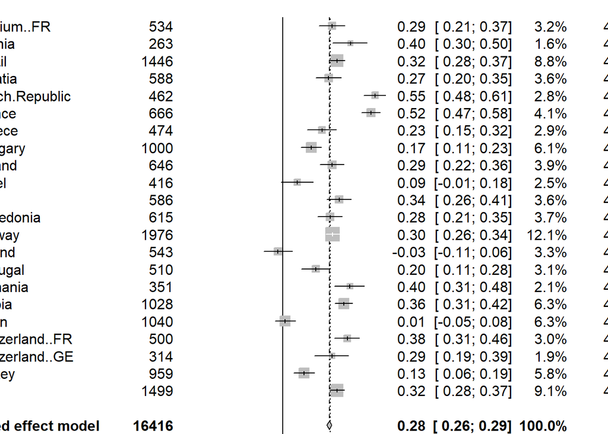

```r
forest(right)
```

```r
available = !is.na(cors[,3])
neutral <- metacor(cors[available,3], cors[available,6],rownames(cors[available,]))
neutral
```

```
##                    COR           95%-CI %W(fixed) %W(random)
## Belgium..FR     0.4516 [0.3813; 0.5166]       3.3        4.7
## Bosnia          0.5211 [0.4271; 0.6040]       1.6        4.4
## Brazil          0.4163 [0.3727; 0.4580]       9.0        5.0
## Croatia         0.4098 [0.3404; 0.4747]       3.7        4.8
## Czech.Republic  0.5375 [0.4693; 0.5994]       2.9        4.7
## France          0.6620 [0.6170; 0.7026]       4.1        4.8
## Greece          0.5313 [0.4621; 0.5940]       2.8        4.7
## Hungary         0.3647 [0.3098; 0.4173]       6.2        4.9
## Iceland         0.3500 [0.2801; 0.4161]       4.0        4.8
## Italy           0.5479 [0.4886; 0.6022]       3.6        4.8
## Macedonia       0.3634 [0.2928; 0.4301]       3.8        4.8
## Norway          0.3002 [0.2596; 0.3398]      12.4        5.0
## Poland          0.2607 [0.1847; 0.3335]       3.8        4.8
## Portugal        0.3624 [0.2846; 0.4355]       3.2        4.7
## Romania         0.4048 [0.3134; 0.4888]       2.2        4.5
## Serbia          0.3528 [0.2979; 0.4053]       6.4        4.9
## Spain           0.0761 [0.0155; 0.1363]       6.5        4.9
## Switzerland..FR 0.4967 [0.4276; 0.5600]       3.1        4.7
## Switzerland..GE 0.2438 [0.1368; 0.3452]       1.9        4.5
## Turkey          0.3328 [0.2755; 0.3879]       6.0        4.9
## UK              0.4466 [0.4051; 0.4862]       9.4        5.0
##
## Number of studies combined: k = 21
##
##                         COR           95%-CI     z  p-value
## Fixed effect model   0.3884 [0.3752; 0.4015] 51.83        0
## Random effects model 0.4080 [0.3518; 0.4613] 12.92 < 0.0001
##
## Quantifying heterogeneity:
##  tau^2 = 0.0219 [0.0124; 0.0496]; tau = 0.1482 [0.1115; 0.2227]
##  I^2 = 94.3% [92.4%; 95.7%]; H = 4.18 [3.63; 4.80]
##
## Test of heterogeneity:
##       Q d.f.  p-value
##  348.84   20 < 0.0001
##
## Details on meta-analytical method:
## - Inverse variance method
## - DerSimonian-Laird estimator for tau^2
## - Jackson method for confidence interval of tau^2 and tau
## - Fisher's z transformation of correlations
```

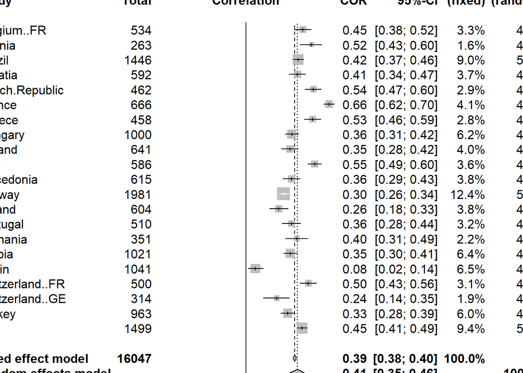

```r
forest(neutral)
```

```r
available = !is.na(cors[,4])
meanCT <- metacor(cors[available,4], cors[available,7],rownames(cors[available,]))
meanCT
```

```
##                    COR           95%-CI %W(fixed) %W(random)
## Belgium..FR     0.5016 [0.4353; 0.5625]       3.3        4.7
## Bosnia          0.5005 [0.4040; 0.5860]       1.6        4.5
## Brazil          0.5443 [0.5070; 0.5796]       9.1        4.9
## Croatia         0.4293 [0.3610; 0.4930]       3.7        4.8
## Czech.Republic  0.6488 [0.5926; 0.6987]       2.9        4.7
## France          0.7463 [0.7107; 0.7782]       4.2        4.8
## Greece          0.6031 [0.5373; 0.6616]       2.5        4.7
## Hungary         0.4070 [0.3539; 0.4574]       6.3        4.9
## Iceland         0.5451 [0.4879; 0.5976]       4.0        4.8
## Italy           0.5632 [0.5053; 0.6161]       3.7        4.8
## Macedonia       0.4245 [0.3574; 0.4872]       3.9        4.8
## Norway          0.3498 [0.3102; 0.3881]      12.3        4.9
## Poland          0.1804 [0.1021; 0.2565]       3.8        4.8
## Portugal        0.4072 [0.3321; 0.4772]       3.2        4.7
## Romania         0.4564 [0.3692; 0.5358]       2.2        4.6
## Serbia          0.4402 [0.3897; 0.4881]       6.5        4.9
## Spain           0.1484 [0.0882; 0.2075]       6.5        4.9
## Switzerland..FR 0.5748 [0.5129; 0.6307]       3.1        4.7
## Switzerland..GE 0.4530 [0.3604; 0.5368]       2.0        4.6
## Turkey          0.3797 [0.3240; 0.4327]       6.0        4.9
## UK              0.5230 [0.4852; 0.5589]       9.4        4.9
##
## Number of studies combined: k = 21
##
##                         COR           95%-CI     z  p-value
## Fixed effect model   0.4602 [0.4478; 0.4723] 62.71        0
## Random effects model 0.4784 [0.4157; 0.5366] 13.01 < 0.0001
##
## Quantifying heterogeneity:
##  tau^2 = 0.0319 [0.0180; 0.0703]; tau = 0.1787 [0.1342; 0.2651]
##  I^2 = 96.0% [94.8%; 96.9%]; H = 4.98 [4.39; 5.64]
##
## Test of heterogeneity:
##       Q d.f.  p-value
##  495.49   20 < 0.0001
##
## Details on meta-analytical method:
## - Inverse variance method
## - DerSimonian-Laird estimator for tau^2
## - Jackson method for confidence interval of tau^2 and tau
## - Fisher's z transformation of correlations
```

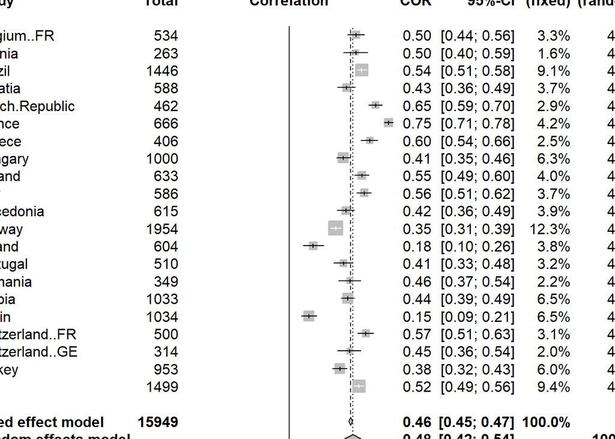

```r
forest(meanCT)
```

## CM and PO

Mixed Model

```r
model.cmpo =lmer(CM4x~ZPO+I(ZPO^2)+(ZPO+I(ZPO^2)|Country), data=data, REML=FALSE, control = lmerControl(optimizer="optimx", optCtrl=list(method="bobyqa")) )
summary(model.cmpo)
```

```
## Linear mixed model fit by maximum likelihood . t-tests use Satterthwaite's
##   method [lmerModLmerTest]
## Formula: CM4x ~ ZPO + I(ZPO^2) + (ZPO + I(ZPO^2) | Country)
##    Data: data
## Control: lmerControl(optimizer = "optimx", optCtrl = list(method = "bobyqa"))
##
##      AIC      BIC   logLik deviance df.resid
##  75559.4  75637.2 -37769.7  75539.4    17685
##
## Scaled residuals:
##     Min      1Q  Median      3Q     Max
## -3.4614 -0.6646  0.0355  0.7205  2.7652
##
## Random effects:
##  Groups   Name        Variance Std.Dev. Corr
##  Country  (Intercept) 0.41973  0.64786
##           ZPO         0.02813  0.16771  -0.42
##           I(ZPO^2)    0.00301  0.05486  -0.26 -0.01
##  Residual             4.14866  2.03683
## Number of obs: 17695, groups:  Country, 23
##
## Fixed effects:
##             Estimate Std. Error       df t value Pr(>|t|)
## (Intercept)  6.93890    0.13678 23.10671  50.729  < 2e-16 ***
## ZPO          0.11459    0.03903 21.72481   2.936  0.00772 **
## I(ZPO^2)     0.05438    0.01681 24.09603   3.236  0.00351 **
## ---
## Signif. codes:  0 '***' 0.001 '**' 0.01 '*' 0.05 '.' 0.1 ' ' 1
##
## Correlation of Fixed Effects:
##          (Intr) ZPO
## ZPO      -0.372
## I(ZPO^2) -0.241 -0.028
```

Twolines Plot

[output not shown]

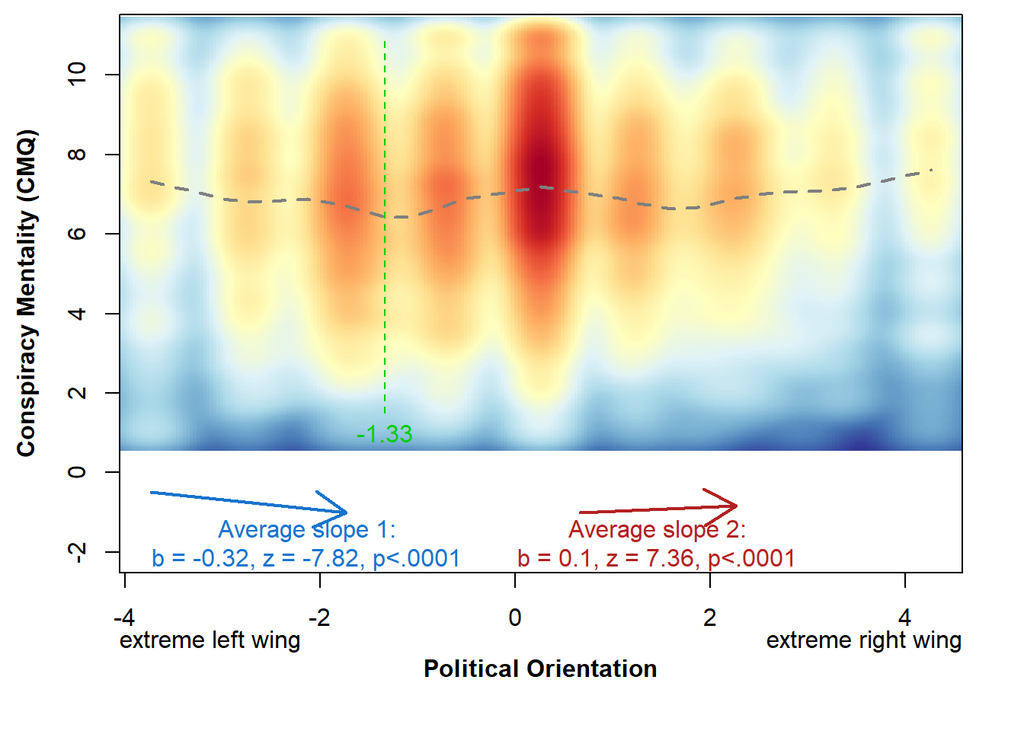

```r
data$Pol_Ori_centered = scale(data$Pol_Ori,scale=F)
a=twolines(CM4x~Pol_Ori_centered,data=data, x.label="Political Orientation",y.label="Conspiracy Mentality (CMQ)",label.extremes=T,lab.extreme.low="extreme left wing",lab.extreme.high="extreme right wing")
```

by country effects in the mixed model

```r
coef(model.cmpo)
```

```
## $Country
##                 (Intercept)          ZPO    I(ZPO^2)
## Belgium, FR        7.406090 -0.035095704  0.10623697
## Bosnia             7.112076 -0.031024586  0.07351007
## Brazil             6.808645 -0.037322575  0.11957321
## Croatia            6.909249  0.308172577  0.07475667
## Czech Republic     5.941099  0.111556735  0.06349507
## France             5.650630  0.285619665  0.06891957
## Germany            6.915125  0.095294315  0.04417699
## Greece             6.429183  0.205172030  0.07163932
## Hungary            7.498232  0.151832988  0.06090799
## Iceland            6.613831 -0.127440773  0.04558276
## Israel             7.452323  0.001432123  0.02441000
## Italy              6.369565  0.338505332  0.04046910
## Macedonia          6.974377  0.129146463  0.08849919
## Norway             5.833078  0.172366551  0.11906912
## Poland             6.132585  0.256711856  0.02603083
## Portugal           7.949648  0.101097866  0.05934056
## Romania            7.366529  0.317082295  0.01409172
## Serbia             7.660580 -0.047988378  0.01589885
## Spain              7.675580 -0.146852923 -0.05231845
## Switzerland, FR    6.808499  0.261195815  0.04051244
## Switzerland, GE    7.228774  0.257340122  0.01190899
## Turkey             7.949966 -0.116098302  0.07537326
## UK                 6.909080  0.184847715  0.05857412
##
## attr(,"class")
## [1] "coef.mer"
```

Linear Model for each country

```r
by.country = matrix(NA,0,7)
for (i in unique(data$Country)) {
test = lm(CM4x~ZPO+I(ZPO^2),data[data$Country == i,])
a = coef(test)
b = summary(test)$coefficients[,4] #p-values
b2 = summary(test)$coefficients[,2] #SE
d = c(as.numeric(a)[-1],as.numeric(b2)[-1],as.numeric(b)[-1])
d = c(i,d)
by.country = rbind(by.country,d)
}
by.country = as.data.frame(by.country)
names(by.country) = c("Country","ZPO","ZPO2","SE_ZPO","SE_ZPO2","p_ZPO","p_ZPO2")
by.country[,2:7] = apply(by.country[,2:7],2,as.numeric)

by.country$CI95_low_ZPO = by.country$ZPO-qnorm(.975)*by.country$SE_ZPO
by.country$CI95_high_ZPO = by.country$ZPO+qnorm(.975)*by.country$SE_ZPO
by.country$sig_ZPO = by.country$p_ZPO<.05
by.country$sigbonf_ZPO = by.country$p_ZPO<.05/nrow(by.country)

by.country$CI95_low_ZPO2 = by.country$ZPO2-qnorm(.975)*by.country$SE_ZPO2
by.country$CI95_high_ZPO2 = by.country$ZPO2+qnorm(.975)*by.country$SE_ZPO2
by.country$sig_ZPO2 = by.country$p_ZPO2 <.05
by.country$sigbonf_ZPO2 = by.country$p_ZPO2 <.05/nrow(by.country)

export = by.country[,c(1,2,8,9,10,11,3,12,13,14,15)]
export
```

|  | Country | ZPO | CI95_low_ZPO | CI95_high_ZPO | sig_ZPO | sigbonf_ZPO | ZPO2 | CI95_low_ZPO2 | CI95_high_ZPO2 | sig_ZPO2 | sigbonf_ZPO2 |
| --- | --- | --- | --- | --- | --- | --- | --- | --- | --- | --- | --- |
| d | Iceland | -0.22572895 | -0.394162509 | -0.05729539 | TRUE | FALSE | 0.003585237 | -0.137494986 | 0.14466546 | FALSE | FALSE |
| d.1 | Belgium, FR | -0.07706100 | -0.238209473 | 0.08408747 | FALSE | FALSE | 0.181005005 | 0.071627402 | 0.29038261 | TRUE | TRUE |
| d.2 | Bosnia | -0.11590399 | -0.359043821 | 0.12723584 | FALSE | FALSE | 0.122402162 | -0.045173390 | 0.28997771 | FALSE | FALSE |
| d.3 | Brazil | -0.05885684 | -0.163022852 | 0.04530917 | FALSE | FALSE | 0.149364820 | 0.076598726 | 0.22213092 | TRUE | TRUE |
| d.4 | Switzerland, FR | 0.30727602 | 0.118671365 | 0.49588068 | TRUE | TRUE | 0.023460026 | -0.111378228 | 0.15829828 | FALSE | FALSE |
| d.5 | Switzerland, GE | 0.37102146 | 0.166740754 | 0.57530217 | TRUE | TRUE | -0.089295715 | -0.245401724 | 0.06681029 | FALSE | FALSE |
| d.6 | Croatia | 0.35821498 | 0.168713221 | 0.54771673 | TRUE | TRUE | 0.100196594 | -0.046275366 | 0.24666855 | FALSE | FALSE |
| d.7 | Czech Republic | 0.05438672 | -0.117968565 | 0.22674200 | FALSE | FALSE | 0.035904678 | -0.088224097 | 0.16003345 | FALSE | FALSE |
| d.8 | France | 0.29562099 | 0.109743125 | 0.48149886 | TRUE | TRUE | 0.062517323 | -0.062505341 | 0.18753999 | FALSE | FALSE |
| d.9 | Greece | 0.21870164 | 0.003331474 | 0.43407181 | TRUE | FALSE | 0.092742678 | -0.076873923 | 0.26235928 | FALSE | FALSE |

[output cut: 13 more lines]

```r
#print(xtable(export,digits=4),type="html",file="./table.html")
```

Exploratory: Interaction of ZPO and Countryvars in predicting CM

```r
countrylevelvars = c("lrgengov", "lrecongov","galtangov")

for (i in 1:length(countrylevelvars)) {
fmla <- as.formula(paste("CM4x~ZPO+I(ZPO^2)+(ZPO+I(ZPO^2)|Country) +",countrylevelvars[i],"+ ZPO *",countrylevelvars[i],"+ I(ZPO^2) *",countrylevelvars[i]))
model.1 =lmer(fmla, data=data, REML=FALSE, control = lmerControl(optimizer="optimx", optCtrl=list(method="bobyqa")))
summary(model.1) %>% print()
}
```

```
## Linear mixed model fit by maximum likelihood . t-tests use Satterthwaite's
##   method [lmerModLmerTest]
## Formula: fmla
##    Data: data
## Control: lmerControl(optimizer = "optimx", optCtrl = list(method = "bobyqa"))
##
##      AIC      BIC   logLik deviance df.resid
##  64144.8  64243.8 -32059.4  64118.8    14963
##
## Scaled residuals:
##     Min      1Q  Median      3Q     Max
## -3.4265 -0.6677  0.0321  0.7164  2.7606
##
## Random effects:
##  Groups   Name        Variance Std.Dev. Corr
##  Country  (Intercept) 0.467725 0.68390
##           ZPO         0.019535 0.13977  -0.64
##           I(ZPO^2)    0.002313 0.04809  -0.29  0.35
##  Residual             4.203905 2.05034
## Number of obs: 14976, groups:  Country, 19
##
## Fixed effects:
##                    Estimate Std. Error        df t value Pr(>|t|)
## (Intercept)        6.559897   0.617715 19.175362  10.620  1.8e-09 ***
## ZPO                0.292861   0.146369 19.640871   2.001   0.0594 .
## I(ZPO^2)           0.007453   0.071017 25.311106   0.105   0.9172
## lrgengov           0.056962   0.096476 19.109159   0.590   0.5618
## ZPO:lrgengov      -0.025712   0.022641 18.810141  -1.136   0.2704
## I(ZPO^2):lrgengov  0.007860   0.010856 23.472116   0.724   0.4762
## ---
## Signif. codes:  0 '***' 0.001 '**' 0.01 '*' 0.05 '.' 0.1 ' ' 1
##
## Correlation of Fixed Effects:
##             (Intr) ZPO    I(ZPO^2) lrgngv ZPO:lr
## ZPO         -0.537
## I(ZPO^2)    -0.248  0.152
## lrgengov    -0.966  0.519  0.238
## ZPO:lrgengv  0.524 -0.967 -0.146   -0.543
## I(ZPO^2):lr  0.243 -0.148 -0.970   -0.249  0.152
## Linear mixed model fit by maximum likelihood . t-tests use Satterthwaite's
```

[output cut: 62 more lines]

```
## ZPO                 0.265788   0.093970 19.760709   2.828   0.0105 *
## I(ZPO^2)            0.078058   0.047446 26.006641   1.645   0.1120
## galtangov           0.089396   0.058875 19.072802   1.518   0.1453
## ZPO:galtangov      -0.021981   0.014232 19.079927  -1.544   0.1389
## I(ZPO^2):galtangov -0.003390   0.007141 24.868383  -0.475   0.6392
## ---
## Signif. codes:  0 '***' 0.001 '**' 0.01 '*' 0.05 '.' 0.1 ' ' 1
##
## Correlation of Fixed Effects:
##             (Intr) ZPO    I(ZPO^2) gltngv ZPO:gl
## ZPO         -0.483
## I(ZPO^2)    -0.181  0.036
## galtangov   -0.920  0.444  0.166
## ZPO:galtngv  0.447 -0.924 -0.026   -0.486
## I(ZPO^2):gl  0.169 -0.027 -0.929   -0.181  0.027
```

Correlations of CountryVars and Slopes

```r
sl = coef(model.cmpo)$Country
cl = aggregate(data[countrylevelvars],by=list(data$Country),mean)
df = cbind(sl,cl[,-1])
df = df[,-1]
res<-rcorr(as.matrix(df[,])) # using Hmisc
res = lapply(res,function(x) x[3:length(df),1:2])
res = cbind(res$r,res$P)
res =as.data.frame(res)
names(res) = c("ZPO","ZPO2","pZPO","pZPO2")
res$sigZPO = res$pZPO<.05
res$sigZPO2 = res$pZPO2<.05
res
```

|  | ZPO | ZPO2 | pZPO | pZPO2 | sigZPO | sigZPO2 |
| --- | --- | --- | --- | --- | --- | --- |
| lrgengov | -0.2539793 | 0.14809748 | 0.2940668 | 0.5451334 | FALSE | FALSE |
| lrecongov | -0.3183900 | 0.06618117 | 0.1840135 | 0.7877855 | FALSE | FALSE |
| galtangov | -0.3526644 | -0.13752912 | 0.1386237 | 0.5744860 | FALSE | FALSE |

Between countries

```r
 model.1=lmer(CM4x~ZPO+I(ZPO^2)+ZmeanPO+I(ZmeanPO^2)+(ZPO+I(ZPO^2)|Country), data=data, REML=FALSE, control = lmerControl(optimizer="optimx", optCtrl=list(method="bobyqa")) )
 summary(model.1)
```

```
## Linear mixed model fit by maximum likelihood . t-tests use Satterthwaite's
##   method [lmerModLmerTest]
## Formula: CM4x ~ ZPO + I(ZPO^2) + ZmeanPO + I(ZmeanPO^2) + (ZPO + I(ZPO^2) |
##     Country)
##    Data: data
## Control: lmerControl(optimizer = "optimx", optCtrl = list(method = "bobyqa"))
##
##      AIC      BIC   logLik deviance df.resid
##  75563.0  75656.4 -37769.5  75539.0    17683
##
## Scaled residuals:
##     Min      1Q  Median      3Q     Max
## -3.4587 -0.6643  0.0353  0.7199  2.7610
##
## Random effects:
##  Groups   Name        Variance Std.Dev. Corr
##  Country  (Intercept) 0.424498 0.65154
##           ZPO         0.028041 0.16746  -0.42
##           I(ZPO^2)    0.003023 0.05498  -0.33 -0.01
##  Residual             4.148681 2.03683
## Number of obs: 17695, groups:  Country, 23
##
## Fixed effects:
##               Estimate Std. Error        df t value Pr(>|t|)
## (Intercept)   6.975805   0.163377 24.377717  42.698  < 2e-16 ***
## ZPO           0.114258   0.038991 21.733687   2.930  0.00781 **
## I(ZPO^2)      0.053876   0.016824 24.043513   3.202  0.00381 **
## ZmeanPO      -0.039219   0.104627 21.923764  -0.375  0.71138
## I(ZmeanPO^2) -0.008823   0.044990 23.119338  -0.196  0.84624
## ---
## Signif. codes:  0 '***' 0.001 '**' 0.01 '*' 0.05 '.' 0.1 ' ' 1
##
## Correlation of Fixed Effects:
##             (Intr) ZPO    I(ZPO^2) ZmenPO
## ZPO         -0.320
## I(ZPO^2)    -0.255 -0.029
## ZmeanPO      0.157  0.008  0.020
## I(ZmenPO^2) -0.502  0.009  0.014   -0.624
```

+interactions

```r
model.2=lmer(CM4x~ZPO+I(ZPO^2)+ZmeanPO+I(ZmeanPO^2)+ZPO:ZmeanPO+I(ZPO^2):ZmeanPO+(ZPO+I(ZPO^2)|Country), data=data, REML=FALSE, control = lmerControl(optimizer="optimx", optCtrl=list(method="bobyqa")) )
summary(model.2)
```

```
## Linear mixed model fit by maximum likelihood . t-tests use Satterthwaite's
##   method [lmerModLmerTest]
## Formula: CM4x ~ ZPO + I(ZPO^2) + ZmeanPO + I(ZmeanPO^2) + ZPO:ZmeanPO +
##     I(ZPO^2):ZmeanPO + (ZPO + I(ZPO^2) | Country)
##    Data: data
## Control: lmerControl(optimizer = "optimx", optCtrl = list(method = "bobyqa"))
##
##      AIC      BIC   logLik deviance df.resid
##  75562.8  75671.7 -37767.4  75534.8    17681
##
## Scaled residuals:
##     Min      1Q  Median      3Q     Max
## -3.4750 -0.6663  0.0381  0.7193  2.7256
##
## Random effects:
##  Groups   Name        Variance Std.Dev. Corr
##  Country  (Intercept) 0.417006 0.64576
##           ZPO         0.027438 0.16564  -0.41
##           I(ZPO^2)    0.002524 0.05024  -0.32 -0.05
##  Residual             4.148260 2.03673
## Number of obs: 17695, groups:  Country, 23
##
## Fixed effects:
##                  Estimate Std. Error       df t value Pr(>|t|)
## (Intercept)       6.96594    0.16252 24.83345  42.863  < 2e-16 ***
## ZPO               0.11326    0.03992 21.59994   2.837  0.00969 **
## I(ZPO^2)          0.06032    0.01644 26.52253   3.668  0.00108 **
## ZmeanPO           0.03483    0.11400 25.45142   0.305  0.76248
## I(ZmeanPO^2)     -0.01559    0.04498 23.34862  -0.346  0.73207
## ZPO:ZmeanPO      -0.00947    0.02639 23.85173  -0.359  0.72289
## I(ZPO^2):ZmeanPO -0.02421    0.01185 42.64549  -2.043  0.04729 *
## ---
## Signif. codes:  0 '***' 0.001 '**' 0.01 '*' 0.05 '.' 0.1 ' ' 1
##
## Correlation of Fixed Effects:
##             (Intr) ZPO    I(ZPO^2) ZmenPO I(ZmPO^2) ZPO:ZP
## ZPO         -0.313
## I(ZPO^2)    -0.240 -0.080
## ZmeanPO      0.122  0.065  0.050
## I(ZmenPO^2) -0.498  0.004  0.004   -0.598
## ZPO:ZmeanPO  0.056 -0.243  0.066   -0.304  0.033
## I(ZPO^2):ZP  0.016  0.067 -0.196   -0.258  0.069    -0.028
```

```r
anova(model.1,model.2)
```

|  | npar | AIC | BIC | logLik | deviance | Chisq | Df | Pr(>Chisq) |
| --- | --- | --- | --- | --- | --- | --- | --- | --- |
| model.1 | 12 | 75563.03 | 75656.40 | -37769.52 | 75539.03 | NA | NA | NA |
| model.2 | 14 | 75562.81 | 75671.75 | -37767.41 | 75534.81 | 4.217628 | 2 | 0.1213819 |

## CHES

Scale Variables across whole data

```r
data$lrgen = scale(data$lrgen)
data$lrecon = scale(data$lrecon)
data$galtan = scale(data$galtan)
```

Left-Right (General), mixed model

```r
model.1=lmer(CM4x ~ lrgen + I(lrgen^2)+ (lrgen+I(lrgen^2)|Country), data=data, REML=FALSE, control = lmerControl(optimizer="optimx", optCtrl=list(method="bobyqa")) )
summary(model.1)
```

```
## Linear mixed model fit by maximum likelihood . t-tests use Satterthwaite's
##   method [lmerModLmerTest]
## Formula: CM4x ~ lrgen + I(lrgen^2) + (lrgen + I(lrgen^2) | Country)
##    Data: data
## Control: lmerControl(optimizer = "optimx", optCtrl = list(method = "bobyqa"))
##
##      AIC      BIC   logLik deviance df.resid
##  42150.8  42222.7 -21065.4  42130.8     9852
##
## Scaled residuals:
##     Min      1Q  Median      3Q     Max
## -3.3464 -0.6589  0.0342  0.7062  2.6706
##
## Random effects:
##  Groups   Name        Variance Std.Dev. Corr
##  Country  (Intercept) 0.63104  0.7944
##           lrgen       0.02635  0.1623   -0.27
##           I(lrgen^2)  0.03725  0.1930   -0.57 -0.13
##  Residual             4.14600  2.0362
## Number of obs: 9862, groups:  Country, 20
##
## Fixed effects:
##             Estimate Std. Error       df t value Pr(>|t|)
## (Intercept)  6.76189    0.18299 20.55818  36.952   <2e-16 ***
## lrgen        0.09144    0.04775 16.68060   1.915   0.0728 .
## I(lrgen^2)   0.15996    0.05519 16.98686   2.899   0.0100 **
## ---
## Signif. codes:  0 '***' 0.001 '**' 0.01 '*' 0.05 '.' 0.1 ' ' 1
##
## Correlation of Fixed Effects:
##            (Intr) lrgen
## lrgen      -0.183
## I(lrgen^2) -0.537 -0.202
```

per country coefficients (fixed+random effect)

```r
coef(model.1)
```

```
## $Country
##                 (Intercept)        lrgen  I(lrgen^2)
## Belgium, FR        7.027599  0.084625683  0.21406839
## Bosnia             7.159643  0.073780801  0.07642781
## Croatia            7.051868  0.103335684  0.14683114
## Czech Republic     5.850742  0.004524568  0.17808103
## France             5.507059  0.071799305  0.21730054
## Germany            6.371433  0.117219896  0.42392948
## Greece             5.537075  0.326056325  0.41353136
## Hungary            7.414985  0.037640114  0.01555561
## Italy              6.455211  0.338108880  0.01613230
## Macedonia          6.875023  0.187638283  0.20028193
## Norway             5.585583  0.175601418  0.25111047
## Poland             5.903800  0.023030193  0.16689332
## Portugal           7.749784  0.033831534  0.07700702
## Romania            7.353661 -0.011544924  0.07594576
## Serbia             7.895260  0.130440874 -0.12388766
## Spain              7.342556 -0.170780885  0.38304164
## Switzerland, FR    6.522242  0.214243940  0.14925648
## Switzerland, GE    7.093138  0.218398923  0.05701302
## Turkey             8.091674 -0.063231348 -0.11148340
## UK                 6.449519 -0.065873758  0.37212565
##
## attr(,"class")
## [1] "coef.mer"
```

Left-Right (Economic), mixed model

```r
model.2=lmer(CM4x ~ lrecon + I(lrecon^2) + (lrecon+I(lrecon^2)|Country), data=data, REML=FALSE, control = lmerControl(optimizer="optimx", optCtrl=list(method="bobyqa")) )
summary(model.2)
```

```
## Linear mixed model fit by maximum likelihood . t-tests use Satterthwaite's
##   method [lmerModLmerTest]
## Formula: CM4x ~ lrecon + I(lrecon^2) + (lrecon + I(lrecon^2) | Country)
##    Data: data
## Control: lmerControl(optimizer = "optimx", optCtrl = list(method = "bobyqa"))
##
##      AIC      BIC   logLik deviance df.resid
##  42244.6  42316.5 -21112.3  42224.6     9852
##
## Scaled residuals:
##     Min      1Q  Median      3Q     Max
## -3.3101 -0.6702  0.0212  0.7034  2.6139
##
## Random effects:
##  Groups   Name        Variance Std.Dev. Corr
##  Country  (Intercept) 0.48482  0.6963
##           lrecon      0.02077  0.1441   -0.19
##           I(lrecon^2) 0.02945  0.1716   -0.29 -0.33
##  Residual             4.18830  2.0465
## Number of obs: 9862, groups:  Country, 20
##
## Fixed effects:
##             Estimate Std. Error       df t value Pr(>|t|)
## (Intercept)  6.87067    0.16168 21.00944  42.494   <2e-16 ***
## lrecon       0.01599    0.04442 15.21902   0.360    0.724
## I(lrecon^2)  0.05552    0.05183 15.53688   1.071    0.300
## ---
## Signif. codes:  0 '***' 0.001 '**' 0.01 '*' 0.05 '.' 0.1 ' ' 1
##
## Correlation of Fixed Effects:
##             (Intr) lrecon
## lrecon      -0.116
## I(lrecon^2) -0.326 -0.281
```

per country coefficients (fixed+random effect)

```r
coef(model.2)
```

```
## $Country
##                 (Intercept)       lrecon I(lrecon^2)
## Belgium, FR        6.975406 -0.019256121  0.17527636
## Bosnia             7.208756 -0.012426074  0.04505106
## Croatia            7.316940 -0.002634449  0.02163822
## Czech Republic     5.915465 -0.018833672  0.04259967
## France             5.659294 -0.056979070  0.04291792
## Germany            6.441219 -0.001216905  0.32407926
## Greece             6.769838  0.142635961 -0.22966487
## Hungary            7.487865  0.045711656 -0.04668189
## Italy              6.407500  0.225884992  0.07434597
## Macedonia          6.956043 -0.002837029  0.06008067
## Norway             5.693688  0.134631213  0.10064092
## Poland             6.074079  0.063473774  0.05773217
## Portugal           7.734503 -0.002096879  0.05306642
## Romania            7.402282 -0.058245866  0.01996783
## Serbia             7.864068  0.037459831 -0.06901042
## Spain              7.082948 -0.278381343  0.34912805
## Switzerland, FR    6.630071  0.124686861  0.02071436
## Switzerland, GE    6.906936  0.147508725  0.13198030
## Turkey             8.074778 -0.087283767 -0.12534531
## UK                 6.811788 -0.061987773  0.06193495
##
## attr(,"class")
## [1] "coef.mer"
```

Galtan, mixed model

```r
model.3=lmer(CM4x ~ galtan + I(galtan^2)  +(galtan+I(galtan^2)|Country), data=data, REML=FALSE, control = lmerControl(optimizer="optimx", optCtrl=list(method="bobyqa")) )
summary(model.3)
```

```
## Linear mixed model fit by maximum likelihood . t-tests use Satterthwaite's
##   method [lmerModLmerTest]
## Formula: CM4x ~ galtan + I(galtan^2) + (galtan + I(galtan^2) | Country)
##    Data: data
## Control: lmerControl(optimizer = "optimx", optCtrl = list(method = "bobyqa"))
##
##      AIC      BIC   logLik deviance df.resid
##  42156.6  42228.6 -21068.3  42136.6     9852
##
## Scaled residuals:
##     Min      1Q  Median      3Q     Max
## -3.3998 -0.6722  0.0358  0.6981  2.6614
##
## Random effects:
##  Groups   Name        Variance Std.Dev. Corr
##  Country  (Intercept) 0.61688  0.7854
##           galtan      0.03025  0.1739   -0.38
##           I(galtan^2) 0.02870  0.1694   -0.68 -0.09
##  Residual             4.15140  2.0375
## Number of obs: 9862, groups:  Country, 20
##
## Fixed effects:
##             Estimate Std. Error       df t value Pr(>|t|)
## (Intercept)  6.90915    0.18160 19.85604  38.047  < 2e-16 ***
## galtan       0.21104    0.05072 20.63857   4.161 0.000456 ***
## I(galtan^2)  0.02934    0.04901 17.49092   0.599 0.557155
## ---
## Signif. codes:  0 '***' 0.001 '**' 0.01 '*' 0.05 '.' 0.1 ' ' 1
##
## Correlation of Fixed Effects:
##             (Intr) galtan
## galtan      -0.240
## I(galtan^2) -0.626 -0.244
```

per country coefficients (fixed+random effect)

```r
coef(model.3)
```

```
## $Country
##                 (Intercept)      galtan  I(galtan^2)
## Belgium, FR        7.674540  0.26070644 -0.137271581
## Bosnia             7.172624  0.18799170 -0.036182537
## Croatia            7.099148  0.19180680  0.024019187
## Czech Republic     5.721819  0.25247651  0.254137468
## France             5.695868  0.27350776  0.195884848
## Germany            6.522676  0.31269044  0.164385636
## Greece             5.677813  0.47067247  0.310359365
## Hungary            7.596404  0.17559183 -0.123319154
## Italy              6.672725  0.43268967 -0.128989689
## Macedonia          6.875291  0.22437625  0.068718675
## Norway             5.875123  0.39467587  0.043533538
## Poland             6.028868  0.06519827  0.052469591
## Portugal           7.871768  0.05466510 -0.015724858
## Romania            7.291889  0.20980747 -0.007485008
## Serbia             7.879844  0.17910551 -0.128925775
## Spain              7.373805 -0.15750036  0.195542279
## Switzerland, FR    6.780467  0.25543846  0.017267137
## Switzerland, GE    7.308601  0.22358803 -0.064734010
## Turkey             8.194903  0.09474996 -0.181613038
## UK                 6.868835  0.11852142  0.084629876
##
## attr(,"class")
## [1] "coef.mer"
```

Left-Right (General), twolines

[output not shown]

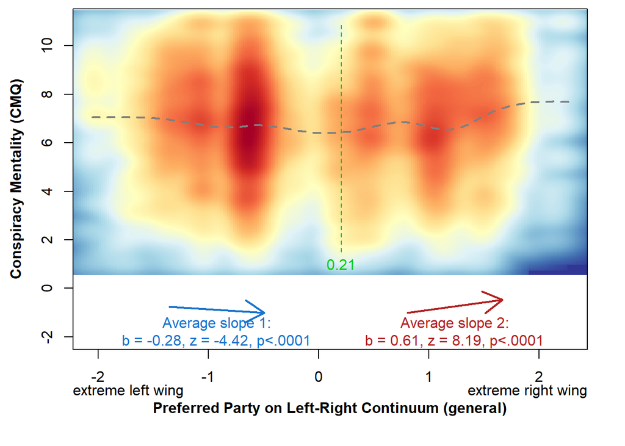

```r
a=twolines(CM4x~lrgen,data=data,x.label="Preferred Party on Left-Right Continuum (general)",y.label="Conspiracy Mentality (CMQ)",label.extremes=T,lab.extreme.low="extreme left wing",lab.extreme.high="extreme right wing")
```

Left-Right (Economic), twolines

[output not shown]

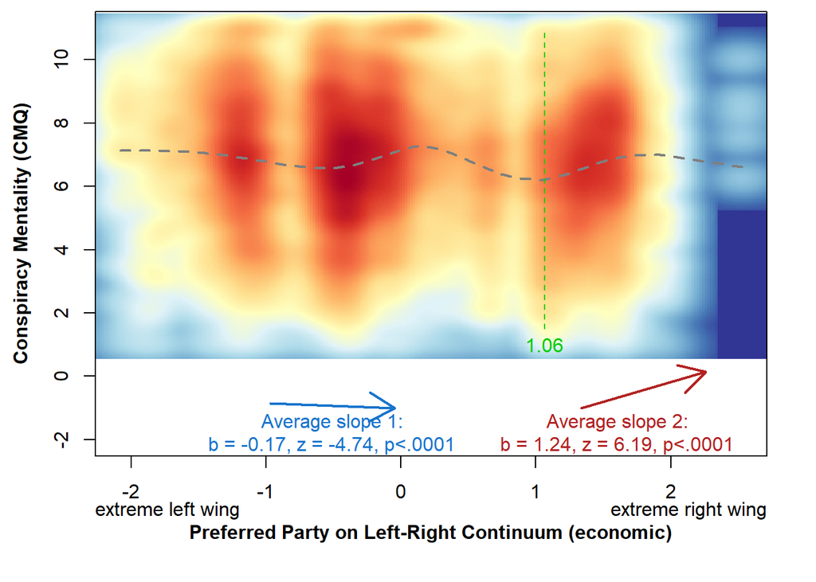

```r
a=twolines(CM4x~lrecon,data=data, x.label="Preferred Party on Left-Right Continuum (economic)",y.label="Conspiracy Mentality (CMQ)",label.extremes=T,lab.extreme.low="extreme left wing",lab.extreme.high="extreme right wing")
```

Galtan, twolines

[output not shown]

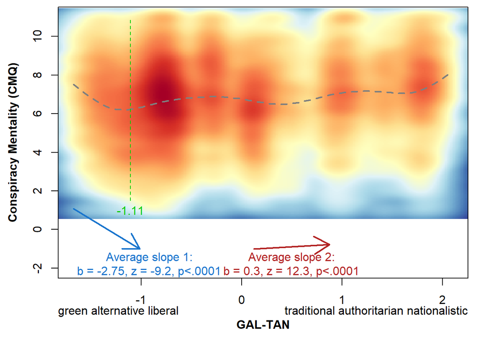

```r
a=twolines(CM4x~galtan,data=data, x.label="GAL-TAN",y.label="Conspiracy Mentality (CMQ)",label.extremes=T,lab.extreme.low="green alternative liberal",lab.extreme.high="traditional authoritarian nationalistic")
```

Adding mean for control

Left-Right (General), mixed model + mean

```r
model.1=lmer(CM4x ~ lrgen + I(lrgen^2)+ (lrgen+I(lrgen^2)|Country) + mean_lrgen, data=data, REML=FALSE, control = lmerControl(optimizer="optimx", optCtrl=list(method="bobyqa")) )
summary(model.1)
```

```
## Linear mixed model fit by maximum likelihood . t-tests use Satterthwaite's
##   method [lmerModLmerTest]
## Formula: CM4x ~ lrgen + I(lrgen^2) + (lrgen + I(lrgen^2) | Country) +
##     mean_lrgen
##    Data: data
## Control: lmerControl(optimizer = "optimx", optCtrl = list(method = "bobyqa"))
##
##      AIC      BIC   logLik deviance df.resid
##  42151.5  42230.6 -21064.7  42129.5     9851
##
## Scaled residuals:
##     Min      1Q  Median      3Q     Max
## -3.3499 -0.6590  0.0335  0.7066  2.6711
##
## Random effects:
##  Groups   Name        Variance Std.Dev. Corr
##  Country  (Intercept) 0.63818  0.7989
##           lrgen       0.02658  0.1630   -0.29
##           I(lrgen^2)  0.03689  0.1921   -0.60 -0.12
##  Residual             4.14591  2.0362
## Number of obs: 9862, groups:  Country, 20
##
## Fixed effects:
##             Estimate Std. Error       df t value Pr(>|t|)
## (Intercept)  7.54354    0.69558 21.70394  10.845 3.16e-10 ***
## lrgen        0.09349    0.04790 16.89161   1.952   0.0678 .
## I(lrgen^2)   0.15786    0.05487 17.10317   2.877   0.0104 *
## mean_lrgen  -0.15386    0.13227 20.65781  -1.163   0.2580
## ---
## Signif. codes:  0 '***' 0.001 '**' 0.01 '*' 0.05 '.' 0.1 ' ' 1
##
## Correlation of Fixed Effects:
##            (Intr) lrgen  I(l^2)
## lrgen       0.001
## I(lrgen^2) -0.155 -0.196
## mean_lrgen -0.964 -0.056  0.006
```

Left-Right (Economic), mixed model + mean

```r
model.2=lmer(CM4x ~ lrecon + I(lrecon^2) + (lrecon+I(lrecon^2)|Country) + mean_lrecon, data=data, REML=FALSE, control = lmerControl(optimizer="optimx", optCtrl=list(method="bobyqa")) )
summary(model.2)
```

```
## Linear mixed model fit by maximum likelihood . t-tests use Satterthwaite's
##   method [lmerModLmerTest]
## Formula: CM4x ~ lrecon + I(lrecon^2) + (lrecon + I(lrecon^2) | Country) +
##     mean_lrecon
##    Data: data
## Control: lmerControl(optimizer = "optimx", optCtrl = list(method = "bobyqa"))
##
##      AIC      BIC   logLik deviance df.resid
##  42244.5  42323.6 -21111.2  42222.5     9851
##
## Scaled residuals:
##     Min      1Q  Median      3Q     Max
## -3.3084 -0.6729  0.0207  0.7087  2.6111
##
## Random effects:
##  Groups   Name        Variance Std.Dev. Corr
##  Country  (Intercept) 0.45448  0.6742
##           lrecon      0.02037  0.1427   -0.26
##           I(lrecon^2) 0.02954  0.1719   -0.31 -0.33
##  Residual             4.18837  2.0466
## Number of obs: 9862, groups:  Country, 20
##
## Fixed effects:
##             Estimate Std. Error       df t value Pr(>|t|)
## (Intercept)  7.97770    0.75237 19.94705  10.603  1.2e-09 ***
## lrecon       0.01513    0.04403 15.37089   0.344    0.736
## I(lrecon^2)  0.05433    0.05178 15.51193   1.049    0.310
## mean_lrecon -0.24260    0.16128 19.50439  -1.504    0.149
## ---
## Signif. codes:  0 '***' 0.001 '**' 0.01 '*' 0.05 '.' 0.1 ' ' 1
##
## Correlation of Fixed Effects:
##             (Intr) lrecon I(l^2)
## lrecon      -0.004
## I(lrecon^2) -0.054 -0.286
## mean_lrecon -0.978 -0.031 -0.018
```

Galtan, mixed model + mean

```r
model.3=lmer(CM4x ~ galtan + I(galtan^2)  +(galtan+I(galtan^2)|Country) + mean_galtan, data=data, REML=FALSE, control = lmerControl(optimizer="optimx", optCtrl=list(method="bobyqa")) )
summary(model.3)
```

```
## Linear mixed model fit by maximum likelihood . t-tests use Satterthwaite's
##   method [lmerModLmerTest]
## Formula: CM4x ~ galtan + I(galtan^2) + (galtan + I(galtan^2) | Country) +
##     mean_galtan
##    Data: data
## Control: lmerControl(optimizer = "optimx", optCtrl = list(method = "bobyqa"))
##
##      AIC      BIC   logLik deviance df.resid
##  42158.6  42237.8 -21068.3  42136.6     9851
##
## Scaled residuals:
##     Min      1Q  Median      3Q     Max
## -3.3998 -0.6722  0.0358  0.6981  2.6614
##
## Random effects:
##  Groups   Name        Variance Std.Dev. Corr
##  Country  (Intercept) 0.61815  0.7862
##           galtan      0.03025  0.1739   -0.38
##           I(galtan^2) 0.02868  0.1694   -0.68 -0.09
##  Residual             4.15140  2.0375
## Number of obs: 9862, groups:  Country, 20
##
## Fixed effects:
##              Estimate Std. Error        df t value Pr(>|t|)
## (Intercept)  6.927438   0.489827 23.540417  14.143 5.34e-13 ***
## galtan       0.211179   0.050869 20.735328   4.151 0.000463 ***
## I(galtan^2)  0.029354   0.049034 17.567309   0.599 0.557046
## mean_galtan -0.003752   0.093581 20.745227  -0.040 0.968401
## ---
## Signif. codes:  0 '***' 0.001 '**' 0.01 '*' 0.05 '.' 0.1 ' ' 1
##
## Correlation of Fixed Effects:
##             (Intr) galtan I(g^2)
## galtan      -0.017
## I(galtan^2) -0.199 -0.241
## mean_galtan -0.929 -0.078 -0.036
```

## Losers

Mixed Model

```r
model.1=lmer(CM4x ~ Winner_state + (1|Country), data=data, REML=FALSE, control = lmerControl(optimizer="optimx", optCtrl=list(method="bobyqa")) )
summary(model.1)
```

```
## Linear mixed model fit by maximum likelihood . t-tests use Satterthwaite's
##   method [lmerModLmerTest]
## Formula: CM4x ~ Winner_state + (1 | Country)
##    Data: data
## Control: lmerControl(optimizer = "optimx", optCtrl = list(method = "bobyqa"))
##
##      AIC      BIC   logLik deviance df.resid
##  49909.9  49939.3 -24950.9  49901.9    11650
##
## Scaled residuals:
##     Min      1Q  Median      3Q     Max
## -3.3572 -0.6823  0.0296  0.7167  2.5625
##
## Random effects:
##  Groups   Name        Variance Std.Dev.
##  Country  (Intercept) 0.4153   0.6445
##  Residual             4.2068   2.0510
## Number of obs: 11654, groups:  Country, 23
##
## Fixed effects:
##                Estimate Std. Error         df t value Pr(>|t|)
## (Intercept)   6.999e+00  1.373e-01  2.388e+01  50.990  < 2e-16 ***
## Winner_state -1.206e-01  4.252e-02  1.164e+04  -2.836  0.00458 **
## ---
## Signif. codes:  0 '***' 0.001 '**' 0.01 '*' 0.05 '.' 0.1 ' ' 1
##
## Correlation of Fixed Effects:
##             (Intr)
## Winner_stat -0.114
```

Loser vs. CHES: LRgen

```r
model.2=lmer(CM4x ~ lrgen + I(lrgen^2) + Winner_state + (lrgen+I(lrgen^2)|Country), data=data, REML=FALSE, control = lmerControl(optimizer="optimx", optCtrl=list(method="bobyqa")) )
summary(model.2)
```

```
## Linear mixed model fit by maximum likelihood . t-tests use Satterthwaite's
##   method [lmerModLmerTest]
## Formula: CM4x ~ lrgen + I(lrgen^2) + Winner_state + (lrgen + I(lrgen^2) |
##     Country)
##    Data: data
## Control: lmerControl(optimizer = "optimx", optCtrl = list(method = "bobyqa"))
##
##      AIC      BIC   logLik deviance df.resid
##  41900.5  41979.6 -20939.3  41878.5     9795
##
## Scaled residuals:
##     Min      1Q  Median      3Q     Max
## -3.3213 -0.6713  0.0367  0.6978  2.6845
##
## Random effects:
##  Groups   Name        Variance Std.Dev. Corr
##  Country  (Intercept) 0.64974  0.8061
##           lrgen       0.02347  0.1532   -0.17
##           I(lrgen^2)  0.05201  0.2281   -0.52 -0.31
##  Residual             4.13926  2.0345
## Number of obs: 9806, groups:  Country, 20
##
## Fixed effects:
##               Estimate Std. Error        df t value Pr(>|t|)
## (Intercept)    6.85587    0.18701  21.19282  36.660  < 2e-16 ***
## lrgen          0.15125    0.04856   9.83638   3.114   0.0112 *
## I(lrgen^2)     0.15034    0.06328  13.31657   2.376   0.0332 *
## Winner_state  -0.25409    0.06350 578.17767  -4.002 7.11e-05 ***
## ---
## Signif. codes:  0 '***' 0.001 '**' 0.01 '*' 0.05 '.' 0.1 ' ' 1
##
## Correlation of Fixed Effects:
##             (Intr) lrgen  I(l^2)
## lrgen       -0.067
## I(lrgen^2)  -0.501 -0.329
## Winner_stat -0.117 -0.221 -0.015
```

Loser vs. CHES: LRecon

```r
model.2=lmer(CM4x ~ lrecon + I(lrecon^2) + Winner_state + (lrecon + I(lrecon^2)|Country), data=data, REML=FALSE, control = lmerControl(optimizer="optimx", optCtrl=list(method="bobyqa")) )
summary(model.2)
```

```
## Linear mixed model fit by maximum likelihood . t-tests use Satterthwaite's
##   method [lmerModLmerTest]
## Formula: CM4x ~ lrecon + I(lrecon^2) + Winner_state + (lrecon + I(lrecon^2) |
##     Country)
##    Data: data
## Control: lmerControl(optimizer = "optimx", optCtrl = list(method = "bobyqa"))
##
##      AIC      BIC   logLik deviance df.resid
##  42002.8  42081.9 -20990.4  41980.8     9795
##
## Scaled residuals:
##     Min      1Q  Median      3Q     Max
## -3.3144 -0.6775  0.0189  0.7027  2.6128
##
## Random effects:
##  Groups   Name        Variance Std.Dev. Corr
##  Country  (Intercept) 0.50042  0.7074
##           lrecon      0.01485  0.1218   -0.18
##           I(lrecon^2) 0.03270  0.1808   -0.34 -0.33
##  Residual             4.18776  2.0464
## Number of obs: 9806, groups:  Country, 20
##
## Fixed effects:
##               Estimate Std. Error        df t value Pr(>|t|)
## (Intercept)    6.91928    0.16553  21.68816  41.802  < 2e-16 ***
## lrecon         0.01940    0.04111  16.13772   0.472  0.64337
## I(lrecon^2)    0.06900    0.05461  15.14084   1.263  0.22555
## Winner_state  -0.16016    0.06067 453.43615  -2.640  0.00858 **
## ---
## Signif. codes:  0 '***' 0.001 '**' 0.01 '*' 0.05 '.' 0.1 ' ' 1
##
## Correlation of Fixed Effects:
##             (Intr) lrecon I(l^2)
## lrecon      -0.076
## I(lrecon^2) -0.353 -0.297
## Winner_stat -0.125 -0.140 -0.027
```

Loser vs. CHES: Galtan

```r
model.2=lmer(CM4x ~ galtan + I(galtan^2)  + Winner_state + (galtan + I(galtan^2)|Country), data=data, REML=FALSE, control = lmerControl(optimizer="optimx", optCtrl=list(method="bobyqa")) )
summary(model.2)
```

```
## Linear mixed model fit by maximum likelihood . t-tests use Satterthwaite's
##   method [lmerModLmerTest]
## Formula: CM4x ~ galtan + I(galtan^2) + Winner_state + (galtan + I(galtan^2) |
##     Country)
##    Data: data
## Control: lmerControl(optimizer = "optimx", optCtrl = list(method = "bobyqa"))
##
##      AIC      BIC   logLik deviance df.resid
##  41894.8  41973.9 -20936.4  41872.8     9795
##
## Scaled residuals:
##     Min      1Q  Median      3Q     Max
## -3.3881 -0.6634  0.0361  0.7006  2.6936
##
## Random effects:
##  Groups   Name        Variance Std.Dev. Corr
##  Country  (Intercept) 0.62418  0.7901
##           galtan      0.02851  0.1688   -0.20
##           I(galtan^2) 0.04149  0.2037   -0.58 -0.50
##  Residual             4.14018  2.0347
## Number of obs: 9806, groups:  Country, 20
##
## Fixed effects:
##                Estimate Std. Error         df t value Pr(>|t|)
## (Intercept)   7.044e+00  1.842e-01  2.047e+01  38.242  < 2e-16 ***
## galtan        2.763e-01  5.166e-02  2.013e+01   5.348 3.04e-05 ***
## I(galtan^2)  -9.589e-04  5.601e-02  1.842e+01  -0.017    0.987
## Winner_state -3.186e-01  6.259e-02  6.822e+02  -5.089 4.65e-07 ***
## ---
## Signif. codes:  0 '***' 0.001 '**' 0.01 '*' 0.05 '.' 0.1 ' ' 1
##
## Correlation of Fixed Effects:
##             (Intr) galtan I(g^2)
## galtan      -0.068
## I(galtan^2) -0.565 -0.505
## Winner_stat -0.124 -0.175  0.029
```

Loser vs ZPO

```r
model.cmpo =lmer(CM4x~ZPO+I(ZPO^2)+(ZPO+I(ZPO^2)+Winner_state|Country)+ Winner_state , data=data, REML=FALSE, control = lmerControl(optimizer="optimx", optCtrl=list(method="bobyqa")) )
summary(model.cmpo)
```

```
## Linear mixed model fit by maximum likelihood . t-tests use Satterthwaite's
##   method [lmerModLmerTest]
## Formula: CM4x ~ ZPO + I(ZPO^2) + (ZPO + I(ZPO^2) + Winner_state | Country) +
##     Winner_state
##    Data: data
## Control: lmerControl(optimizer = "optimx", optCtrl = list(method = "bobyqa"))
##
##      AIC      BIC   logLik deviance df.resid
##  48806.9  48917.1 -24388.4  48776.9    11437
##
## Scaled residuals:
##     Min      1Q  Median      3Q     Max
## -3.5318 -0.6614  0.0330  0.7125  2.8797
##
## Random effects:
##  Groups   Name         Variance Std.Dev. Corr
##  Country  (Intercept)  0.399120 0.63176
##           ZPO          0.026961 0.16420  -0.48
##           I(ZPO^2)     0.003006 0.05482  -0.01 -0.62
##           Winner_state 0.214334 0.46296  -0.12 -0.11  0.06
##  Residual              4.087314 2.02171
## Number of obs: 11452, groups:  Country, 23
##
## Fixed effects:
##              Estimate Std. Error       df t value Pr(>|t|)
## (Intercept)   6.92153    0.13649 24.01603  50.710  < 2e-16 ***
## ZPO           0.11992    0.04116 21.18991   2.914 0.008256 **
## I(ZPO^2)      0.09296    0.01864 14.02209   4.986 0.000199 ***
## Winner_state -0.25333    0.11115 20.60228  -2.279 0.033434 *
## ---
## Signif. codes:  0 '***' 0.001 '**' 0.01 '*' 0.05 '.' 0.1 ' ' 1
##
## Correlation of Fixed Effects:
##             (Intr) ZPO    I(ZPO^
## ZPO         -0.370
## I(ZPO^2)    -0.098 -0.375
## Winner_stat -0.168 -0.146  0.013
```